# Quantitative Portfolio Analysis

## Assessment Task 2 – Portfolio Optimization Project

**Student:** Clint Sellen

**Student ID:** 12685400

**Unit:** 37008 Quantitative Portfolio Analysis

**Semester:** Summer 2025-2026

*Developed using Python v3.11.7*

#### Implementation

- Data Pre-Processor
- Performance Metrics
- Markowitz Optimisation
- Tracking Error Variance
- K-Factor PCA Model
- Alternative Portfolio Optimization

#### Part 0: Data Preparation

- 0.1 Load ASX 200 Data
- 0.2 Daily Percentage Returns
- 0.3 Annualization Factor
- 0.4 Annualized Mean and Covariance
- 0.5 Sharpe Ratios
- 0.6 Investment Universe

#### Part 1: Markowitz Mean-Variance and Tracking Error Variance Optimization

**Markowitz Mean-Variance (MV) Analysis**

- 1.1.1 Mean-Variance Portfolio (No Risk-Free Asset)
- 1.1.2 Mean-Variance Portfolio (With Risk-Free Asset)
- 1.1.3 Interpretation
- 1.1.4 Mean-Variance Efficient Frontier and Capital Market Line

**Tracking Error Variance (TEV) Analysis**

- 1.2.1 Stock $\beta$
- 1.2.2 TEV-optimal Portfolio
- 1.2.3 $\beta$ of $\phi_{TEV}$ with respect to the ASX 200
- 1.2.4 TEV Efficient Frontier

#### Part 2: k-Factor Models and Arbitrage Pricing Theory

- 2.1 Fit the k-Factor Model
- 2.2 Principal Component Analysis (PCA) of Centered Returns
- 2.3 PCA Validation
- 2.4 Empirical vs K-Factor Model Comparison

#### Part 3: Alternative Portfolio Optimization Criteria

- 3.1 Constrained Mean-Variance Portfolio Optimization
- 3.2 Maximum Sharpe Ratio Portfolio ($\phi_{MSR}$)
- 3.3 Kelly Portfolio ($\phi_{K}$)
- 3.4 Optimal Portfolio based on Expected Utility
- 3.5 Efficient Frontier
- 3.6 Compare and Contrast Portfolio Metrics

#### Part 4: Synthesis

#### References

```python
# Importing Libraries
import numpy as np
import pandas as pd
from enum import Enum
from typing import Optional, Dict, Tuple
import sympy as spy
from IPython.display import display, Markdown, Math, Latex

import matplotlib.pyplot as plt
import matplotlib.colors as mcolors
import matplotlib.pyplot as plt
import seaborn as sns
import warnings

from scipy.optimize import minimize
# from numpy.linalg import inv, eig
from sklearn.decomposition import PCA
from sklearn.linear_model import LinearRegression
from scipy.linalg import null_space

plt.style.use("default")
plt.rcParams["figure.figsize"] = (16, 9)

pd.set_option('display.max_columns', None)
pd.set_option('display.max_rows', 50)
pd.set_option('display.width', 200)
```

## Implementation

```python
# Global Helper Functions

def display_matrix(arr, variable, max_size=15, edge_items=3, precision=4):
    """
    Display a numpy array as LaTeX matrix/vector with proper truncation using \\cdots and \\vdots.

    Parameters:
    -----------
    arr : numpy array
        The array to display (1D, 2D)
    max_size : int
        Maximum dimension before truncation kicks in
    edge_items : int
        Number of rows/columns to show at edges when truncated
    precision : int
        Number of decimal places for rounding
    """
    # Handle 1D arrays as column vectors
    if arr.ndim == 1:
        arr = arr.reshape(-1, 1)

    rows, cols = arr.shape
    arr = np.round(arr, precision)

    # Small enough - display full matrix/vector
    if rows <= max_size and cols <= max_size:

        matrix_sym = spy.Matrix(np.round(arr, 4))
        display(Math(rf"{variable} = " + spy.latex(spy.Matrix(matrix_sym))))
        return

    # Build LaTeX string manually for truncated matrix
    latex_str = r"\begin{bmatrix}" + "\n"

    # Handle column vector (n x 1) or row vector (1 x n) separately
    if cols == 1:
        # Column vector - just truncate rows
        for i in range(edge_items):
            latex_str += str(arr[i, 0]) + r" \\" + "\n"
        latex_str += r"\vdots \\" + "\n"
        for i in range(-edge_items, 0):
            latex_str += str(arr[i, 0]) + r" \\" + "\n"

    elif rows == 1:
        # Row vector - just truncate columns
        row_elements = []
        row_elements.extend([str(arr[0, j]) for j in range(edge_items)])
        row_elements.append(r"\cdots")
        row_elements.extend([str(arr[0, j]) for j in range(-edge_items, 0)])
        latex_str += " & ".join(row_elements) + r" \\" + "\n"

    elif rows > max_size or cols > max_size:
        # Matrix - truncate both if needed
        if rows > max_size:
            # Top rows
            for i in range(edge_items):
                row_elements = []
                if cols > max_size:
                    # Left columns
                    row_elements.extend([str(arr[i, j]) for j in range(edge_items)])
                    row_elements.append(r"\cdots")
                    # Right columns
                    row_elements.extend([str(arr[i, j]) for j in range(-edge_items, 0)])
                else:
                    row_elements = [str(arr[i, j]) for j in range(cols)]
                latex_str += " & ".join(row_elements) + r" \\" + "\n"

            # Middle dots row
            if cols > max_size:
                dots_row = [r"\vdots"] * edge_items + [r"\ddots"] + [r"\vdots"] * edge_items
            else:
                dots_row = [r"\vdots"] * cols
            latex_str += " & ".join(dots_row) + r" \\" + "\n"

            # Bottom rows
            for i in range(-edge_items, 0):
                row_elements = []
                if cols > max_size:
                    row_elements.extend([str(arr[i, j]) for j in range(edge_items)])
                    row_elements.append(r"\cdots")
                    row_elements.extend([str(arr[i, j]) for j in range(-edge_items, 0)])
                else:
                    row_elements = [str(arr[i, j]) for j in range(cols)]
                latex_str += " & ".join(row_elements) + r" \\" + "\n"
        else:
            # Only truncate columns
            for i in range(rows):
                row_elements = []
                row_elements.extend([str(arr[i, j]) for j in range(edge_items)])
                row_elements.append(r"\cdots")
                row_elements.extend([str(arr[i, j]) for j in range(-edge_items, 0)])
                latex_str += " & ".join(row_elements) + r" \\" + "\n"

    latex_str += r"\end{bmatrix}"

    return display(Latex(f"$${variable} = {latex_str}$$"))


def compute_annualization_factor(prices: pd.DataFrame) -> float:
    """
    Compute the annualization factor for a given price series.
    Args:
        prices (pd.DataFrame): The price series to compute the annualization factor for. Index should be a datetime index.
    Returns:
        float: The annualization factor.
    """
    n_obs = prices.shape[0]
    calendar_days = (prices.index[-1] - prices.index[0]).days
    annualization_factor = n_obs / (calendar_days / 365)
    return annualization_factor
```

```python
class FileType(str, Enum):
    CSV = "csv"

class DataCollection():
    """
    A class for loading and managing financial price data from various file sources.

    This class handles data ingestion from different file formats (currently supporting CSV)
    and provides methods for accessing and reporting on the loaded data.

    Attributes:
        file_path (str | None): Path to the data file to be loaded.
        file_type (FileType | None): Type of file to be loaded (e.g., FileType.CSV).
        prices (pd.DataFrame): DataFrame containing the loaded price data with datetime index.

    Example:
        >>> data = DataCollection(file_path='prices.csv', file_type=FileType.CSV)
        >>> prices_df = data.get_prices()
    """

    def __init__(self,
        file_path: Optional[str] = None,
        file_type: Optional[FileType] = FileType.CSV,
    ):
        """
        Initialize the DataCollection instance.

        Args:
            file_path (str, optional): Path to the data file. If provided, data will be
                automatically loaded. Defaults to None.
            file_type (FileType, optional): Type of file to load. Defaults to FileType.CSV.
        """
        self.file_path = file_path
        self.file_type = file_type
        if self.file_path is not None:
            if self.file_type == FileType.CSV:
                self._load_data_from_csv()

    def _load_data_from_csv(self):
        """
        Load price data from a CSV file (private method).

        This method reads the CSV file specified in self.file_path, sets the first column
        as a datetime index, normalizes timestamps to midnight, and removes any rows
        containing NaN values.

        Side Effects:
            Sets self.prices with a pandas DataFrame containing the loaded and cleaned data.

        Raises:
            FileNotFoundError: If the specified file_path does not exist.
            pd.errors.ParserError: If the CSV file is malformed or cannot be parsed.
        """
        self.prices = pd.read_csv(self.file_path, index_col=0, parse_dates=True, dayfirst=True)
        self.prices.index = pd.to_datetime(self.prices.index, dayfirst=True).normalize()
        self.prices.dropna(inplace=True)

    def get_prices(self):
        """
        Retrieve the loaded price data.

        Returns:
            pd.DataFrame: DataFrame containing price data with datetime index and
                asset prices in columns.
        """
        return self.prices

    def report(self):
        """
        Display a comprehensive report of the loaded price data.

        This method displays two sections:
        1. Data information (data types, non-null counts, memory usage)
        2. Statistical description (count, mean, std, min, quartiles, max)
        """
        display(Markdown('### Information about the data:'))
        display(self.prices.info())
        display(Markdown('### Description of the data:'))
        display(self.prices.describe())
```

## Data Pre-Processor

```python
class ReturnType(str, Enum):
    PERCENTAGE = "percentage"
    LOG = "log"

class DataPreProcessor():
    """
    A comprehensive data preprocessing class for portfolio analysis.

    This class handles the computation of returns, covariance matrices, and various
    statistical measures required for portfolio optimization and analysis. It supports
    both percentage and logarithmic returns, and can handle market index data alongside
    portfolio assets.

    Attributes:
        display_output (bool): Whether to display output during processing.
        return_type (ReturnType): Type of returns to calculate (PERCENTAGE or LOG).
        prices (pd.DataFrame): DataFrame containing historical close prices.
        annualization_factor (float): Factor used to annualize returns and covariances.
        index_ticker (str, optional): Ticker symbol of the market index.
        returns (pd.DataFrame): Calculated returns for all tickers.
        tickers (list): List of all ticker symbols.
        portfolio_tickers (list): List of portfolio tickers (excluding index).
        mu_returns (pd.Series): Mean returns (non-annualized).
        mu_annual_returns (pd.Series): Mean annualized returns.
        Sigma_returns (pd.DataFrame): Covariance matrix (non-annualized).
        Sigma_annual (pd.DataFrame): Annualized covariance matrix.
        std_returns (np.ndarray): Standard deviations (non-annualized).
        std_annual (np.ndarray): Annualized standard deviations.
        portfolio_returns (pd.DataFrame): Returns for portfolio assets only.
        M (pd.Series): Mean annualized returns for portfolio assets.
        Sigma (pd.DataFrame): Annualized covariance matrix for portfolio assets.
        mu_annual_index (float, optional): Annualized mean return of the index.
        var_annual_index (float, optional): Annualized variance of the index.
        sigma_annual_index (float, optional): Annualized standard deviation of the index.
    """

    def __init__(self,
                return_type: ReturnType,
                close_prices: pd.DataFrame,
                annualization_factor: Optional[int] = None,
                index_ticker: Optional[str] = None,
                display_output: bool = True):
        """
        Initialize the DataPreProcessor.

        Args:
            return_type (ReturnType): Type of returns to calculate (PERCENTAGE or LOG).
            close_prices (pd.DataFrame): DataFrame with datetime index and ticker columns
                containing historical close prices.
            annualization_factor (int, optional): Factor to annualize returns. If None,
                will be computed automatically based on data frequency. Defaults to None.
            index_ticker (str, optional): Ticker symbol for the market index. If provided,
                this ticker will be separated from portfolio assets. Defaults to None.
            display_output (bool): Whether to display output during processing.
                Defaults to True.
        """
        self.display_output = display_output
        self.return_type = return_type
        self.prices = close_prices
        self.annualization_factor = annualization_factor
        self.index_ticker = index_ticker
        if self.annualization_factor is None:
            self.set_annualization_factor()

    def _compute_annualization_factor(self):
        """
        Compute the annualization factor based on the data frequency.

        This method calculates the annualization factor by determining the average
        number of observations per year in the price data. The factor is used to
        convert period returns to annual returns.

        Note:
            This is a private method called automatically when annualization_factor
            is not provided during initialization.
        """
        self.annualization_factor = compute_annualization_factor(self.prices)

    def _preprocess_data(self):
        """
        Preprocess price data and compute all statistical measures.

        This method performs the core data preprocessing tasks:
        - Calculates returns (percentage or log) from prices
        - Computes mean returns and covariance matrices
        - Calculates annualized statistics
        - Separates index and portfolio data if index_ticker is provided
        - Computes index-specific statistics (mean, variance, std dev)

        Returns:
            tuple: A tuple containing:
                - tickers (list): All ticker symbols
                - M (pd.Series): Annualized mean returns for portfolio assets
                - Sigma (pd.DataFrame): Annualized covariance matrix for portfolio assets
                - mu_annual_returns (pd.Series): Annualized mean returns for all assets
                - var_annual_index (float or None): Annualized variance of the index
                - sigma_annual_index (float or None): Annualized std dev of the index

        Raises:
            ValueError: If an invalid return type is specified.

        Note:
            This is a private method that sets multiple instance attributes and is
            called by set_data() or run() methods.
        """
        if self.return_type == ReturnType.PERCENTAGE:
            self.returns = self.prices.pct_change()
            # Alternative calculation
            # self.returns  = self.prices / self.prices.shift(1) - 1
        elif self.return_type == ReturnType.LOG:
            self.returns = np.log(self.prices / self.prices.shift(1))
        else:
            raise ValueError(f"Invalid return type: {self.return_type}")

        if self.annualization_factor is None:
            self.set_annualization_factor()

        # Drop the first row (NaN from return calculation)
        self.returns.dropna(inplace=True)

        self.tickers = list(self.returns.columns)
        self.mu_returns = self.returns.mean(axis=0)
        self.mu_annual_returns = self.annualization_factor * self.mu_returns
        self.Sigma_returns = self.returns.cov()
        self.std_returns = np.sqrt(np.diag(self.Sigma_returns))
        self.Sigma_annual = self.annualization_factor * self.Sigma_returns
        self.std_annual = np.sqrt(np.diag(self.Sigma_annual))
```

```python
        if self.index_ticker is not None:
            self.mu_annual_index = self.mu_annual_returns[self.index_ticker]
            self.var_annual_index = self.Sigma_annual[self.index_ticker][self.index_ticker]
            self.sigma_annual_index = np.sqrt(self.var_annual_index)
        else:
            self.mu_annual_index = None
            self.var_annual_index = None
            self.sigma_annual_index = None

        self.portfolio_tickers = list()
        for i in list(self.returns.columns):
            if i != self.index_ticker:
                self.portfolio_tickers.append(i)

        self.portfolio_returns = self.returns[self.portfolio_tickers]
        self.M = self.portfolio_returns.mean(axis=0) * self.annualization_factor
        self.Sigma = self.portfolio_returns.cov() * self.annualization_factor

        return self.tickers, self.M, self.Sigma, self.mu_annual_returns, self.var_annual_index, self.sigma_annual_index

    def plot_returns(self):
        """
        Plot the time series of returns for all tickers.

        Creates a line plot showing the returns over time for all assets in the dataset.
        The plot title and y-axis label adjust based on the return type (percentage or log).
        A horizontal line at zero is included for reference.

        Note:
            Requires matplotlib and seaborn. FutureWarnings are suppressed during plotting.
        """
        import warnings
        # Reset index and explicitly name it 'Date'
        plot_df = self.returns.reset_index()
        date_col = plot_df.columns[0]  # Get the actual name of the index column
        plot_df = plot_df.melt(id_vars=date_col, value_vars=self.tickers, var_name='Ticker', value_name='Return')

        plt.figure(figsize=(16, 4))
        with warnings.catch_warnings():
            warnings.filterwarnings('ignore', category=FutureWarning)
            sns.lineplot(data=plot_df, x=date_col, y='Return', hue='Ticker', linewidth=1, legend=False)

        plt.axhline(0, color='k', lw=0.8, alpha=0.5)
        plt.title(f"{'%' if self.return_type == ReturnType.PERCENTAGE else 'Log'} Returns")
        plt.xlabel('Date')
        plt.ylabel(f"{'%' if self.return_type == ReturnType.PERCENTAGE else 'Log'} Return")
        sns.despine()
        plt.grid(True)
        plt.tight_layout()

    def set_annualization_factor(self, annualization_factor: int = None):
        """
        Set or compute the annualization factor.

        Args:
            annualization_factor (int, optional): The annualization factor to use.
                If None, the factor will be computed automatically based on the
                data frequency. Common values are 252 (daily), 52 (weekly),
                12 (monthly), 4 (quarterly). Defaults to None.
        """
        if annualization_factor is None:
            self._compute_annualization_factor()
        else:
            self.annualization_factor = annualization_factor

    def get_annualization_factor(self, display_output: Optional[bool] = None):
        """
        Get the current annualization factor.

        Args:
            display_output (bool, optional): Whether to display the factor in Markdown
                format. If None, uses the instance's display_output setting.
                Defaults to None.

        Returns:
            float: The annualization factor.
        """
        if display_output is None:
            display_output = self.display_output
        if display_output:
            display(Markdown(f"### Annualization Factor: {self.annualization_factor:.2f}"))
        return self.annualization_factor

    def set_data(self):
        """
        Execute the data preprocessing pipeline.

        This is a convenience method that calls _preprocess_data() to compute all
        returns, statistics, and covariance matrices. Call this method after
        initialization to prepare the data for analysis.

        Note:
            This method sets multiple instance attributes but does not return values.
            Use get_data() to retrieve the computed statistics.
        """
        self._preprocess_data()

    def get_data(self) -> Dict:
        """
        Retrieve the preprocessed data and computed statistics.

        Returns:
            Dict: A dictionary containing:
                - 'returns' (pd.DataFrame): The calculated returns for all assets
                - 'tickers' (list): List of all ticker symbols
                - 'M' (np.ndarray): Annualized mean returns for portfolio assets
                - 'Sigma' (np.ndarray): Annualized covariance matrix for portfolio assets
                - 'mu_annual_index' (float or None): Annualized mean return of the index
                - 'var_annual_index' (float or None): Annualized variance of the index
                - 'sigma_annual_index' (float or None): Annualized std dev of the index

        Note:
            The M and Sigma values are returned as numpy arrays, excluding the index
            ticker if one was specified.
        """
        return {
            'returns': self.returns,
            'tickers': self.tickers,
            'M': self.M.to_numpy(),
            'Sigma': self.Sigma.to_numpy(),
            'mu_annual_index': self.mu_annual_index,
            'var_annual_index': self.var_annual_index,
            'sigma_annual_index': self.sigma_annual_index,
        }

    def plot_covariance_matrix(self):
        """
        Plot the annualized covariance matrix as a heatmap.

        Creates a high-resolution heatmap visualization of the annualized covariance
        matrix with the following features:
        - Color-coded values using a diverging colormap centered at zero
        - Diagonal elements are masked (not colored) for clarity
        - All values are annotated with 4 decimal places
        - Grid lines separate the cells

        Note:
            Requires matplotlib and seaborn. The plot is displayed using plt.show().
        """
        Sigma = self.Sigma_annual
        _, ax = plt.subplots(figsize=(12, 10), dpi=150)
        # Plot the covariance matrix heatmap
        sns.heatmap(
            Sigma,
            ax=ax,
            cmap="vlag",
            center=0,
            mask=np.eye(Sigma.shape[0], dtype=bool),
            linewidths=0.5
        )
        # Manual annotations
        for i in range(Sigma.shape[0]):
            for j in range(Sigma.shape[1]):
                ax.text(
                    j + 0.5,
                    i + 0.5,
                    f"{Sigma.iloc[i, j]:.4f}",
                    ha="center",
                    va="center",
                    fontsize=8,
                    color="black"
                )
        ax.set_title("Covariance Matrix Heatmap (Annualized)")
        ax.grid(False)
        plt.tight_layout()
        plt.show()
```

```python
    def plot_correlation_matrix(self):
        """
        Plot the correlation matrix as a heatmap.

        Creates a high-resolution heatmap visualization of the correlation matrix
        with the following features:
        - Color-coded values using a diverging colormap centered at zero
        - Color scale ranges from -1 to 1
        - All values are annotated with 3 decimal places
        - Grid lines separate the cells
        - Ticker labels on both axes

        Note:
            Requires matplotlib and seaborn. The plot is displayed using plt.show().
        """
        Corr = self.returns.corr()
        _, ax = plt.subplots(figsize=(12, 10), dpi=150)
        # Plot the correlation matrix heatmap
        sns.heatmap(
            Corr,
            ax=ax,
            xticklabels=self.tickers,
            yticklabels=self.tickers,
            cmap="vlag",
            center=0,
            vmin=-1,
            vmax=1,
            linewidths=0.5,
            annot=False
        )
        # Manual annotations
        Corr_np = Corr.to_numpy()
        for i in range(Corr_np.shape[0]):
            for j in range(Corr_np.shape[1]):
                ax.text(
                    j + 0.5,
                    i + 0.5,
                    s=f"{Corr.iloc[i, j]:.3f}",
                    ha="center",
                    va="center",
                    fontsize=8,
                    color="black",
                    alpha=0.8
                )
        ax.set_title("Correlation Matrix Heatmap")
        plt.tight_layout()
        ax.grid(False)
        plt.show()

    def plot_hierarchical_correlation_matrix(self):
        """
        Plot a hierarchically clustered correlation matrix.

        Creates a clustermap visualization that groups similar assets together
        based on their correlations. The visualization includes:
        - Dendrograms on the top and left showing hierarchical clustering
        - Color-coded correlation values using a diverging colormap centered at zero
        - All values are annotated with 3 decimal places
        - Assets reordered according to hierarchical clustering

        This visualization helps identify groups of assets with similar behavior
        and can reveal natural clusters in the portfolio.

        Note:
            Requires matplotlib and seaborn. The plot is displayed using plt.show().
        """
        Corr = self.returns.corr()
        # Plot the hierarchical correlation matrix
        cg = sns.clustermap(
            Corr,
            cmap="vlag",
            center=0,
            figsize=(12, 10),
            linewidths=0.5
        )
        # Get reordered indices
        row_order = cg.dendrogram_row.reordered_ind
        col_order = cg.dendrogram_col.reordered_ind
        # Reordered data
        Corr_reordered = Corr.iloc[row_order, col_order]
        # Access the heatmap axis
        ax = cg.ax_heatmap
        # Manual annotations
        for i in range(Corr_reordered.shape[0]):
            for j in range(Corr_reordered.shape[1]):
                ax.text(
                    j + 0.5,
                    i + 0.5,
                    f"{Corr_reordered.iat[i, j]:.3f}",
                    ha="center",
                    va="center",
                    fontsize=8,
                    color="black",
                    alpha=0.8
                )
        ax.set_title("Hierarchically Clustered Correlation Matrix", pad=140)
        ax.grid(False)
        plt.show()

    def run(self):
        """
        Execute the preprocessing pipeline and return computed data.

        This is a convenience method that combines set_data() and get_data().
        It preprocesses the price data and immediately returns a dictionary
        containing all computed statistics.

        Returns:
            Dict: A dictionary containing:
                - 'returns' (pd.DataFrame): The calculated returns for all assets
                - 'tickers' (list): List of all ticker symbols
                - 'M' (np.ndarray): Annualized mean returns for portfolio assets
                - 'Sigma' (np.ndarray): Annualized covariance matrix for portfolio assets
                - 'mu_annual_index' (float or None): Annualized mean return of the index
                - 'var_annual_index' (float or None): Annualized variance of the index
                - 'sigma_annual_index' (float or None): Annualized std dev of the index

        Example:
            >>> preprocessor = DataPreProcessor(
            ...     return_type=ReturnType.PERCENTAGE,
            ...     close_prices=price_df,
            ...     index_ticker='SPY'
            ... )
            >>> data = preprocessor.run()
            >>> M = data['M']
            >>> Sigma = data['Sigma']
        """
        self._preprocess_data()
        return self.get_data()
```

## Performance Metrics

```python
from dataclasses import dataclass

@dataclass
class PerformanceMetricsResult:
    mu: float
    sigma: float
    sharpe_ratio: float
    diversification_ratio: float
    beta: float
    treynor_index: float
    jensen_index: float
    mm_index: float
```

```python
class PerformanceMetrics:
    """
    A comprehensive class for computing portfolio performance metrics.

    This class calculates various performance measures commonly used in portfolio
    analysis, including risk-adjusted returns (Sharpe ratio), diversification metrics,
    systematic risk measures (beta), and alpha metrics (Jensen's alpha). Metrics can
    be computed relative to both the tangent portfolio and a market benchmark.

    The class supports the following performance metrics:
    - Sharpe Ratio: Excess return per unit of total risk
    - Diversification Ratio: Measure of diversification benefit
    - Beta: Systematic risk relative to a reference portfolio
    - Treynor Index: Excess return per unit of systematic risk
    - Jensen's Alpha: Risk-adjusted excess return
    - Modigliani-Modigliani (M²): Risk-adjusted return in return units

    Attributes:
        phi (np.ndarray): Portfolio weights vector.
        M (np.ndarray): Mean returns vector for all assets.
        Sigma (np.ndarray): Covariance matrix of asset returns.
        r_0 (float): Risk-free rate.
        phi_tau (np.ndarray): Tangent portfolio weights.
        tau_sigma (float): Standard deviation of the tangent portfolio.
        benchmark_beta (np.ndarray, optional): Beta coefficients w.r.t. benchmark.
        benchmark_mu (float, optional): Expected return of the benchmark.
        benchmark_std (float, optional): Standard deviation of the benchmark.
        portfolio_symbol (str): LaTeX symbol for the portfolio in displays.
        mu_phi (float): Expected return of the portfolio.
        sigma_phi (float): Standard deviation of the portfolio.
        Sigma_phi (float): Variance of the portfolio.
        beta_b (float): Beta relative to the benchmark.
        beta_tau (float): Beta relative to the tangent portfolio.
        sr (float): Sharpe ratio.
        dr (float): Diversification ratio.
        ti (float): Treynor index relative to tangent portfolio.
        ti_benchmark (float): Treynor index relative to benchmark.
        ji (float): Jensen's alpha relative to tangent portfolio.
        ji_benchmark (float): Jensen's alpha relative to benchmark.
        mm (float): M² measure relative to tangent portfolio.
        mm_benchmark (float): M² measure relative to benchmark.
    """

    def __init__(
            self,
            phi,
            mean_returns,
            covariance,
            risk_free_rate,
            phi_tangent,
            tangent_std,
            benchmark_beta: Optional[np.ndarray] = None,
            benchmark_mu: Optional[float] = None,
            benchmark_std: Optional[float] = None,
            portfolio_symbol: Optional[str] = "$\\phi$"):
        """
        Initialize the PerformanceMetrics calculator.

        Args:
            phi (np.ndarray): Portfolio weights vector (d×1 or d-length array).
            mean_returns (np.ndarray): Expected returns vector M (d×1 or d-length array).
            covariance (np.ndarray): Covariance matrix Σ (d×d array).
            risk_free_rate (float): Risk-free rate r₀ (annualized).
            phi_tangent (np.ndarray): Weights of the tangent portfolio (d×1 or d-length array).
            tangent_std (float): Standard deviation of the tangent portfolio σ_τ.
            benchmark_beta (np.ndarray, optional): Beta coefficients of each asset
                with respect to the benchmark index (from OLS regression). Defaults to None.
            benchmark_mu (float, optional): Expected return of the benchmark index.
                Defaults to None.
            benchmark_std (float, optional): Standard deviation of the benchmark index.
                Defaults to None.
            portfolio_symbol (str, optional): LaTeX-formatted symbol for the portfolio
                used in display outputs. Defaults to "$\\phi$".
        """
        self.phi = phi
        self.M = mean_returns
        self.Sigma = covariance
        self.r_0 = risk_free_rate
        self.phi_tau = phi_tangent
        self.tau_sigma = tangent_std
        self.benchmark_beta = benchmark_beta # w.r.t. ols of benchmark (index)
        self.benchmark_mu = benchmark_mu
        self.benchmark_std = benchmark_std # standard deviation of index
        self.portfolio_symbol = portfolio_symbol
        self.mu_tau = float(self.phi_tau @ self.M)
        # beta
        self.beta_b = None # w.r.t. benchmark
        self.beta_tau = None # w.r.t. tangent portfolio
        # Sharpe Ratio
        self.sr = None
        # Diversification Ratio
        self.dr = None
        # Treynor Index
        self.ti = None
        self.ti_benchmark = None
        # Jensen Index
        self.ji = None
        self.ji_benchmark = None
        # MM Index
        self.mm = None
        self.mm_benchmark = None

    def portfolio_mu(self) -> float:
        """
        Calculate the expected return of the portfolio.

        Computes μ_φ = φ^T M, where φ is the portfolio weights vector and M is
        the expected returns vector.

        Returns:
            float: The expected return of the portfolio.
        """
        self.mu_phi = float(self.phi @ self.M)
        return self.mu_phi

    def portfolio_variance(self) -> float:
        """
        Calculate the variance of the portfolio.

        Computes σ²_φ = φ^T Σ φ, where φ is the portfolio weights vector and Σ
        is the covariance matrix.

        Returns:
            float: The variance of the portfolio (non-negative).
        """
        self.Sigma_phi = float(self.phi.T @ self.Sigma @ self.phi)
        return self.Sigma_phi

    def portfolio_std(self) -> float:
        """
        Calculate the standard deviation (volatility) of the portfolio.

        Computes σ_φ = √(φ^T Σ φ), ensuring non-negativity by taking the max
        with zero before computing the square root.

        Returns:
            float: The standard deviation of the portfolio.
        """
        self.sigma_phi = np.sqrt(max(self.portfolio_variance(), 0.0))
        return self.sigma_phi
```

```python
    def sharpe_ratio(self) -> float:
        """
        Calculate the Sharpe ratio of the portfolio.

        The Sharpe ratio measures excess return per unit of total risk:
        SR(φ) = (μ_φ - r₀) / σ_φ

        Higher values indicate better risk-adjusted performance. A Sharpe ratio
        greater than 1 is generally considered good, above 2 is excellent.

        Returns:
            float: The Sharpe ratio.

        Note:
            Automatically computes portfolio mean and standard deviation.
        """
        self.sr = (self.portfolio_mu() - self.r_0) / self.portfolio_std()
        return self.sr

    def beta(self) -> float:
        """
        Calculate beta coefficients relative to reference portfolios.

        Beta measures systematic risk exposure to a reference portfolio:
        β_q(φ) = Cov(R_φ, R_q) / Var(R_q) = (φ^T Σ q) / (q^T Σ q)

        This method computes:
        - β_τ: Beta relative to the tangent (market) portfolio
        - β_B: Beta relative to the benchmark index (if benchmark_beta provided)

        Returns:
            tuple: (beta_tau, beta_b) where:
                - beta_tau (float): Beta relative to tangent portfolio
                - beta_b (float or None): Beta relative to benchmark, or None if
                  benchmark_beta not provided

        Note:
            β < 1: Defensive (less volatile than reference)
            β ≈ 1: Market-like exposure
            β > 1: Aggressive (more volatile than reference)
            β ≈ 0: Market-neutral
        """
        var_tau = float(self.phi_tau @ self.Sigma @ self.phi_tau)
        covariance_phi_tau  = float(self.phi @ self.Sigma @ self.phi_tau)
        self.beta_tau = covariance_phi_tau / var_tau
        if self.benchmark_beta is not None:
            self.beta_b = self.phi @ self.benchmark_beta
        return self.beta_tau, self.beta_b

    def diversification_ratio(self) -> float:
        """
        Calculate the diversification ratio of the portfolio.

        The diversification ratio measures the benefit of diversification:
        DR(φ) = (Σᵢ φᵢ σᵢ) / σ_φ

        where σᵢ is the standard deviation of asset i and σ_φ is the portfolio
        standard deviation.

        Returns:
            float: The diversification ratio.

        Note:
            DR = 1: No diversification benefit (equivalent to single asset)
            DR > 1: Positive diversification benefit (portfolio risk < weighted avg)
            Higher values indicate greater risk reduction from diversification
        """
        asset_vols = np.sqrt(np.diag(self.Sigma))
        port_vol = np.sqrt(self.phi.T @ self.Sigma @ self.phi)
        self.dr = (self.phi @ asset_vols) / port_vol
        return self.dr

    def treynor_index(self) -> float:
        """
        Calculate the Treynor index (ratio) for the portfolio.

        The Treynor index measures excess return per unit of systematic risk:
        TI_q(φ) = (μ_φ - r₀) / β_q(φ)

        This method computes Treynor indices relative to:
        - Tangent portfolio (TI_τ)
        - Benchmark index (TI_B), if benchmark data provided

        Returns:
            tuple: (ti_tau, ti_benchmark) where:
                - ti_tau (float): Treynor index relative to tangent portfolio
                - ti_benchmark (float, None, or nan): Treynor index relative to benchmark
                  Returns None if benchmark_beta not provided
                  Returns nan if β_B ≈ 0 (division by zero)

        Note:
            Automatically computes beta if not already calculated.
            Higher values indicate better return per unit of systematic risk.
            Compare Treynor ratios only across portfolios with similar systematic risk.
        """
        if self.beta_tau is None:
            self.beta()
        self.ti = (self.portfolio_mu() - self.r_0) / self.beta_tau
        if self.beta_b is None:
            self.ti_benchmark = None
        elif not np.isclose(self.beta_b, 0.0, atol=1e-6):
            self.ti_benchmark = (self.portfolio_mu() - self.r_0) / self.beta_b
        else:
            self.ti_benchmark = np.nan
        return self.ti, self.ti_benchmark

    def jensen_index(self) -> float:
        """
        Calculate Jensen's alpha (Jensen index) for the portfolio.

        Jensen's alpha measures risk-adjusted excess return:
        JI_q(φ) = μ_φ - [r₀ + β_q(φ) × (μ_q - r₀)]

        It represents the portfolio's return above what would be expected given
        its systematic risk (beta) according to the CAPM or similar pricing model.

        This method computes Jensen's alpha relative to:
        - Tangent portfolio (JI_τ): Often near zero for mean-variance efficient portfolios
        - Benchmark index (JI_B): Typically more informative for active management

        Returns:
            tuple: (ji_tau, ji_benchmark) where:
                - ji_tau (float): Jensen's alpha relative to tangent portfolio
                - ji_benchmark (float or None): Jensen's alpha relative to benchmark,
                  or None if benchmark data not provided

        Note:
            Automatically computes beta if not already calculated.
            α > 0: Outperformance (positive abnormal return)
            α ≈ 0: Performance consistent with systematic risk
            α < 0: Underperformance (negative abnormal return)
        """
        if self.beta_tau is None:
            self.beta()
        # Jensen index
        self.ji = self.portfolio_mu() - (self.r_0 + self.beta_tau * (self.mu_tau - self.r_0))
        if self.beta_b is not None:
            self.ji_benchmark = self.portfolio_mu() - (self.r_0 + self.beta_b * (self.benchmark_mu - self.r_0))
        else:
            self.ji_benchmark = None
        return self.ji, self.ji_benchmark

    def mm_index(self) -> float:
        """
        Calculate the Modigliani-Modigliani (M²) measure.

        The M² measure expresses risk-adjusted performance in return units by
        rescaling the portfolio to match a reference volatility:
        MM_q(φ) = r₀ + σ_q × SR(φ)
```

```python
        This method computes M² relative to:
        - Tangent portfolio volatility (MM_τ)
        - Benchmark index volatility (MM_B)

        Returns:
            float: The M² measure relative to tangent portfolio volatility.

        Note:
            Automatically computes Sharpe ratio if not already calculated.
            MM values can be directly compared to returns of reference portfolios.
            Higher values indicate better risk-adjusted performance.
            MM_B > μ_benchmark: Portfolio outperforms when scaled to benchmark risk
        """
        if self.sr is None:
            self.sharpe_ratio()
        # MM index
        self.mm = self.r_0 + self.tau_sigma * self.sr
        self.mm_benchmark = self.r_0 + self.benchmark_std * self.sr
        return self.mm

    def get_metrics(self)-> PerformanceMetricsResult:
        """
        Retrieve all computed performance metrics as a structured result.

        Returns:
            PerformanceMetricsResult: A dataclass containing:
                - mu: Expected return
                - sigma: Standard deviation (volatility)
                - sharpe_ratio: Sharpe ratio
                - diversification_ratio: Diversification ratio
                - beta: Beta relative to tangent portfolio
                - treynor_index: Treynor index relative to tangent portfolio
                - jensen_index: Jensen's alpha relative to tangent portfolio
                - mm_index: M² measure relative to tangent portfolio

        Note:
            Metrics must be computed first using individual methods or run().
        """
        return PerformanceMetricsResult(
            mu=self.mu_phi,
            sigma=self.sigma_phi,
            sharpe_ratio=self.sr,
            diversification_ratio=self.dr,
            beta=self.beta_tau,
            treynor_index=self.ti,
            jensen_index=self.ji,
            mm_index=self.mm
        )

    def display_metrics(self,):
        """
        Display computed performance metrics in formatted Markdown output.

        Renders all calculated metrics in a hierarchical, formatted display suitable
        for Jupyter notebooks. Metrics are shown with LaTeX formatting for mathematical
        symbols. Both tangent portfolio and benchmark-relative metrics are displayed
        when available.

        The display includes:
        - Sharpe Ratio (SR)
        - Diversification Ratio (DR)
        - Beta (β) relative to tangent and/or benchmark
        - Treynor Index (TI) relative to tangent and/or benchmark
        - Jensen Index (JI/alpha) relative to tangent and/or benchmark
        - M² measure relative to tangent and benchmark

        Note:
            Uses IPython.display.Markdown for rendering.
            Metrics must be computed first using individual methods or run().
            Only displays metrics that have been calculated (non-None values).
        """
        display(Markdown(f"### {self.portfolio_symbol} Performance Metrics"))
        if self.sr is not None:
            display(Markdown(f"#### Sharpe Ratio"))
            display(Markdown(f"- **$\\operatorname{{SR}}$**: {self.sr:.4f}"))
        if self.dr is not None:
            display(Markdown(f"#### Diversification Ratio"))
            display(Markdown(f"- **$\\operatorname{{DR}}$**: {self.dr:.4f}"))
        if self.beta_tau is not None:
            display(Markdown(f"#### Beta"))
            display(Markdown(f"- **$\\beta_{{\\tau}}$**: {self.beta_tau:.4f}"))
            if self.beta_b is not None:
                display(Markdown(f"- **$\\beta_{{B}}$**: {self.beta_b:.4f}"))
        if self.ti is not None:
            display(Markdown(f"#### Treynor Index"))
            display(Markdown(f"- **$\\operatorname{{TI}}_{{\\tau}}$**: {self.ti:.4f}"))
            if self.ti_benchmark is not None:
                display(Markdown(f"- **$\\operatorname{{TI}}_{{B}}$**: {self.ti_benchmark:.4f}"))
        if self.ji is not None:
            display(Markdown(f"#### Jensen Index"))
            display(Markdown(f"- **$\\operatorname{{JI}}_{{\\tau}}$**: {self.ji:.4f}"))
            if self.ji_benchmark is not None:
                display(Markdown(f"- **$\\operatorname{{JI}}_{{B}}$**: {self.ji_benchmark:.4f}"))
        if self.mm is not None:
            display(Markdown(f"#### MM Index"))
            display(Markdown(f"- **$\\operatorname{{MM}}_{{\\tau}}$**: {self.mm:.4f}"))
            if self.mm_benchmark is not None:
                display(Markdown(f"- **$\\operatorname{{MM}}_{{B}}$**: {self.mm_benchmark:.4f}"))

    def interpret_metrics(self):
        """
        Display detailed interpretations of all computed performance metrics.

        Provides a comprehensive analysis of each performance metric including:
        - Mathematical definition with LaTeX equations
        - Computed values for the portfolio
        - Context-aware interpretation based on the actual values
        - Quality grades (e.g., "weak", "acceptable", "strong", "exceptional")
        - Practical implications for portfolio management

        The interpretation includes conditional logic to provide meaningful insights:
        - Sharpe ratio: Graded from underperformance to exceptional
        - Diversification ratio: Assessment of diversification benefit
        - Beta: Classification as defensive, market-like, or aggressive
        - Jensen's alpha: Identification of outperformance or underperformance
        - All metrics shown relative to both tangent and benchmark when available

        Metrics covered:
        - Sharpe Ratio (SR): Risk-adjusted return assessment
        - Diversification Ratio (DR): Correlation reduction benefit
        - Beta (β): Systematic risk exposure
        - Treynor Index (TI): Return per unit systematic risk
        - Jensen's Alpha (JI): Abnormal return after risk adjustment
        - M² Measure (MM): Risk-adjusted return in return units

        Note:
            Requires prior execution of individual metric methods or run().
            Uses helper functions to provide value-dependent interpretations.
            Displays results using IPython Markdown for Jupyter notebooks.
            Handles edge cases like near-zero beta and missing benchmark data.
        """
```

```python
        def _grade_sharpe(sr: float) -> str:
            if sr < 0:
                return "Underperforms the risk-free asset (negative risk-adjusted performance)."
            if sr < 0.5:
                return "Weak risk-adjusted performance."
            if sr < 1.0:
                return "Acceptable risk-adjusted performance."
            if sr < 2.0:
                return "Strong risk-adjusted performance."
            return "Exceptional (rare in practice)."

        def _grade_dr(dr: float) -> str:
            if np.isclose(dr, 1.0, atol=1e-3):
                return "≈ no diversification benefit (portfolio behaves like a single asset)."
            if dr < 1.3:
                return "Modest diversification benefit."
            return "Strong diversification benefit (correlations materially reduced)."

        def _grade_beta(beta: Optional[float]) -> str:
            if beta is None:
                return "Beta not computed."
            if beta < 0:
                return "Negative beta: tends to move opposite the benchmark."
            if np.isclose(beta, 0.0, atol=1e-2):
                return "≈ market-neutral with respect to the benchmark."
            if beta < 1:
                return "Defensive exposure (less systematic risk than the benchmark)."
            if np.isclose(beta, 1.0, atol=1e-2):
                return "Market-like exposure."
            return "Aggressive exposure (more systematic risk than the benchmark)."

        def _grade_jensen(alpha: float) -> str:
            if np.isclose(alpha, 0.0, atol=1e-6):
                return "≈ 0: performance consistent with the benchmark pricing relation."
            if alpha > 0:
                return "Positive alpha: outperforms benchmark-implied return given beta."
            return "Negative alpha: underperforms benchmark-implied return given beta."

        display(Markdown(f"## Interpretation of {self.portfolio_symbol} Performance Metrics"))

        # --- Sharpe Ratio ---
        if self.sr is not None:
            display(Markdown("### Sharpe Ratio"))
            display(Markdown(
                r"**Definition**"
                "\n\n"
                r"$$\operatorname{SR}(\phi)=\frac{m_\phi-r_0}{\sigma_\phi},\qquad "
                r"m_\phi=\phi^\top M,\qquad \sigma_\phi=\sqrt{\phi^\top\Sigma\phi}.$$"
            ))
            display(Markdown(
                f"**Result:** $\\operatorname{{SR}}={self.sr:.4f}$  \n"
                f"**Interpretation:** {_grade_sharpe(float(self.sr))}"
            ))

        # --- Diversification Ratio ---
        if self.dr is not None:
            asset_vols = np.sqrt(np.diag(self.Sigma))
            display(Markdown("### Diversification Ratio"))
            display(Markdown(
                r"**Definition**"
                "\n\n"
                r"$$\operatorname{DR}(\phi)=\frac{\sum_{i=1}^d \phi_i\,\sigma_i}{\sigma_\phi},\qquad "
                r"\sigma_i=\sqrt{\Sigma_{ii}},\qquad \sigma_\phi=\sqrt{\phi^\top\Sigma\phi}.$$"
            ))
            display(Markdown(
                f"**Result:** $\\operatorname{{DR}}={self.dr:.4f}$  \n"
                f"**Interpretation:** {_grade_dr(float(self.dr))}"
            ))

        # --- Beta (tangent + benchmark) ---
        if self.beta_tau is not None:
            display(Markdown("### Beta"))
            display(Markdown(
                r"**Definition (beta w.r.t. a reference portfolio $q$)**"
                "\n\n"
                r"$$\beta_q(\phi)=\frac{\operatorname{Cov}(R_\phi,R_q)}{\operatorname{Var}(R_q)}"
                r"=\frac{\phi^\top\Sigma q}{q^\top\Sigma q}.$$"
            ))
            display(Markdown(
                f"**Result:** $\\beta_\\tau={self.beta_tau:.4f}$  \n"
                f"**Interpretation:** exposure to the **tangent** portfolio (systematic MV risk)."
            ))
            if self.beta_b is not None:
                display(Markdown(
                    f"**Result:** $\\beta_B={self.beta_b:.4f}$  \n"
                    f"**Interpretation:** {_grade_beta(float(self.beta_b))}"
                ))
                if np.isclose(self.beta_b, 0.0, atol=1e-6):
                    display(Markdown(
                        r"Since $\beta_B\approx 0$, benchmark-beta–based ratios (e.g. Treynor vs benchmark) "
                        r"become unstable / not economically meaningful."
                    ))
            else:
                display(Markdown(r"$\beta_B$ can not be computed."))

        # --- Treynor Index ---
        if self.ti is not None:
            display(Markdown("### Treynor Index"))
            display(Markdown(
                r"**Definition (relative to reference portfolio $q$)**"
                "\n\n"
                r"$$\operatorname{TI}_q(\phi)=\frac{m_\phi-r_0}{\beta_q(\phi)}.$$"
            ))
            display(Markdown(
                f"**Result:** $\\operatorname{{TI}}_\\tau={self.ti:.4f}$  \n"
                f"**Interpretation:** excess return per unit of **tangent-systematic** risk."
            ))
            if self.ti_benchmark is None:
                display(Markdown(r"$\operatorname{TI}_B$ can not be computed."))
            elif np.isnan(self.ti_benchmark):
                display(Markdown(
                    r"**Result:** $\operatorname{TI}_B=\text{undefined}$  \n"
                    r"**Interpretation:** $\beta_B\approx 0$ so dividing by beta is unstable; "
                    r"Treynor vs benchmark is not informative for (near) beta-neutral portfolios."
                ))
            else:
                display(Markdown(
                    f"**Result:** $\\operatorname{{TI}}_B={self.ti_benchmark:.4f}$  \n"
                    f"**Interpretation:** excess return per unit of **benchmark** systematic risk."
                ))

        # --- Jensen Index ---
        if self.ji is not None:
            display(Markdown("### Jensen Index (Alpha)"))
            display(Markdown(
                r"**Definition (relative to reference portfolio $q$)**"
                "\n\n"
                r"$$\operatorname{JI}_q(\phi)=m_\phi-\Big(r_0+\beta_q(\phi)\,(m_q-r_0)\Big).$$"
            ))
            display(Markdown(
                f"**Result:** $\\operatorname{{JI}}_\\tau={self.ji:.4f}$  \n"
                f"**Interpretation:** {_grade_jensen(float(self.ji))} "
                r"(Using the tangent portfolio, this is often near 0 for MV-efficient portfolios.)"
            ))
            if self.ji_benchmark is not None:
                display(Markdown(
                    f"**Result:** $\\operatorname{{JI}}_B={self.ji_benchmark:.4f}$  \n"
                    f"**Interpretation:** {_grade_jensen(float(self.ji_benchmark))} "
                    r"(Benchmark = index; typically nonzero.)"
                ))
            else:
                display(Markdown(r"$\operatorname{JI}_B$ can not be computed."))
```

```python
        # --- MM (M²) ---
        if self.mm is not None:
            display(Markdown("### Modigliani–Modigliani ($M^2$) Ratio"))
            display(Markdown(
                r"**Definition (relative to benchmark volatility $\sigma_q$)**"
                "\n\n"
                r"$$\operatorname{MM}_q(\phi)=r_0+\sigma_q\,\operatorname{SR}(\phi)"
                r"=r_0+\sigma_q\frac{m_\phi-r_0}{\sigma_\phi}.$$"
            ))
            display(Markdown(
                f"**Result:** $\\operatorname{{MM}}_\\tau={self.mm:.4f}$  \n"
                r"**Interpretation:** return the portfolio would achieve if rescaled to the **tangent** volatility."
            ))
            if self.mm_benchmark is not None:
                display(Markdown(
                    f"**Result:** $\\operatorname{{MM}}_B={self.mm_benchmark:.4f}$  \n"
                    r"**Interpretation:** return the portfolio would achieve if rescaled to the **benchmark index** volatility."
                ))
            else:
                display(Markdown(r"$\operatorname{MM}_B$ can not be computed."))

        # --- Summary (score-aware) ---
        display(Markdown("### Summary (What these numbers imply)"))
        summary_lines = []
        if self.sr is not None:
            summary_lines.append(f"- Sharpe: **{self.sr:.4f}** $\\rightarrow$ {_grade_sharpe(float(self.sr))}")
        if self.dr is not None:
            summary_lines.append(f"- Diversification: **{self.dr:.4f}** $\\rightarrow$ {_grade_dr(float(self.dr))}")
        if self.beta_b is not None:
            summary_lines.append(f"- Benchmark $\\beta$: **{self.beta_b:.4f}** $\\rightarrow$ {_grade_beta(float(self.beta_b))}")
        if self.beta_tau is not None:
            summary_lines.append(f"- Tangent $\\beta$: **{self.beta_tau:.4f}** $\\rightarrow$ {_grade_beta(float(self.beta_tau))}")
        if self.ji is not None:
            summary_lines.append(f"- Jensen: **{self.ji:.4f}** $\\rightarrow$ {_grade_jensen(float(self.ji))}")
        if self.ji_benchmark is not None:
            summary_lines.append(f"- Jensen (benchmark): **{self.ji_benchmark:.4f}** $\\rightarrow$ {_grade_jensen(float(self.ji_benchmark))}")
        if self.mm is not None:
            summary_lines.append(
                f"- $M^2$ (benchmark): **{self.mm_benchmark:.4f}** $\\rightarrow$ comparable in return units at benchmark risk."
            )

        display(Markdown("\n".join(summary_lines) if summary_lines else "No metrics computed yet. Run `run()` first."))


    def run(self):
        """
        Compute all performance metrics in sequence.

        This convenience method calculates all available performance metrics by
        calling each metric method in the appropriate order:
        1. Sharpe ratio (total risk-adjusted return)
        2. Diversification ratio (correlation benefit)
        3. Beta (systematic risk exposure)
        4. Treynor index (systematic risk-adjusted return)
        5. Jensen index (abnormal return/alpha)
        6. M² measure (risk-adjusted return in return units)

        After calling this method, all metric attributes will be populated and
        can be accessed directly or via get_metrics(), display_metrics(), or
        interpret_metrics().

        Example:
            >>> pm = PerformanceMetrics(phi, M, Sigma, r_0, phi_tau, tau_sigma)
            >>> pm.run()
            >>> pm.display_metrics()  # Show formatted results
            >>> pm.interpret_metrics()  # Show detailed interpretations
            >>> results = pm.get_metrics()  # Get structured result object
        """
        self.sharpe_ratio()
        self.diversification_ratio()
        self.beta()
        self.treynor_index()
        self.jensen_index()
        self.mm_index()
```

## Markowitz Optimisation

```python
class MarkowitzOptimisation():
    """
    Implementation of Markowitz mean-variance portfolio optimization framework.

    This class provides a comprehensive implementation of the Markowitz portfolio
    optimization theory, supporting both cases with and without a risk-free asset.
    It computes various portfolio structures including the minimum variance portfolio,
    self-financing portfolio, tangent (market) portfolio, and optimal portfolios
    based on target expected returns.

    The class implements the classic two-fund separation theorem and generates
    the efficient frontier visualization, showing the risk-return trade-offs of
    optimal portfolios.

    Key portfolios computed:
    - φ_a: Minimum variance portfolio (lowest risk)
    - ω_{a,b}: Self-financing portfolio (unit variance, orthogonal to φ_a)
    - φ_τ/φ_τ: Tangent portfolio (maximum Sharpe ratio)
    - φ: Mean-variance optimal portfolio without risk-free asset
    - φ: Mean-variance optimal portfolio with risk-free asset (separation theorem)

    Attributes:
        M (np.ndarray): Expected returns vector for portfolio assets.
        Sigma (np.ndarray): Covariance matrix of asset returns.
        Sigma_inv (np.ndarray): Inverse of the covariance matrix.
        r_0 (float): Risk-free rate (annualized).
        tickers (list): List of all ticker symbols including index.
        portfolio_tickers (list): List of portfolio asset tickers (excluding index).
        index_ticker (str, optional): Ticker symbol for the market index/benchmark.
        benchmark_mu (float): Expected return of the benchmark.
        benchmark_std (float): Standard deviation of the benchmark.
        annualization_factor (float): Factor for annualizing returns (e.g., 252 for daily).
        m_hat (float, optional): Target expected return for optimization.
        one (np.ndarray): Vector of ones (d×1).
        phi_0 (np.ndarray): Pure risk-free portfolio weights.
        a (float): Constant a = 1^T Σ^{-1} 1.
        b (float): Constant b = M^T Σ^{-1} 1.
        phi_a (np.ndarray): Minimum variance portfolio weights.
        omega_a_b (np.ndarray): Self-financing portfolio weights.
        phi_tau (np.ndarray): Tangent portfolio weights (risky assets only).
        varphi_tau (np.ndarray): Tangent portfolio weights (including risk-free).
        phi (np.ndarray): Optimal portfolio weights (no risk-free case).
        varphi (np.ndarray): Optimal portfolio weights (with risk-free case).
        display_output (bool): Whether to display formatted output.
        logs (bool): Whether to display detailed computation logs.
    """

    def __init__(self,
        M: np.ndarray,
        Sigma: np.ndarray,
        risk_free_rate: float,
        tickers: list,
        index_ticker: Optional[str],
        benchmark_mean: float,
        benchmark_std: float,
        annualization_factor=252,
        target_expected_return=None,
        display_output=True,
        logs=False):
        """
        Initialize the Markowitz optimization framework.

        Args:
            M (np.ndarray): Expected returns vector (d×1 or d-length array) for
                portfolio assets (annualized).
            Sigma (np.ndarray): Covariance matrix (d×d array) of asset returns
                (annualized).
            risk_free_rate (float): Risk-free rate r₀ (annualized).
            tickers (list): List of all ticker symbols, including the index ticker
                if provided.
            index_ticker (str, optional): Ticker symbol for the market benchmark/index.
                If provided, this will be excluded from portfolio optimization.
            benchmark_mean (float): Expected return of the benchmark index (annualized).
            benchmark_std (float): Standard deviation of the benchmark index (annualized).
            annualization_factor (int, optional): Factor to annualize returns. Common
                values: 252 (daily), 52 (weekly), 12 (monthly). Defaults to 252.
            target_expected_return (float, optional): Target expected return for the
                optimal portfolio. Used in mean-variance optimization. Defaults to None.
            display_output (bool, optional): Whether to display formatted Markdown
                output during computation. Defaults to True.
            logs (bool, optional): Whether to display detailed computation logs including
                matrices and intermediate values. Defaults to False.

        Note:
            The covariance matrix must be positive definite (invertible).
            All returns and statistics should be annualized for consistency.
        """
        self.display_output = display_output
        self.logs = logs

        self.tickers = tickers
        self.index_ticker = index_ticker
        self.annualization_factor = annualization_factor

        self.r_0 = risk_free_rate
        self.m_hat = target_expected_return

        self.benchmark_mu = benchmark_mean
        # self.var_annual_index = benchmark_variance
        self.benchmark_std = benchmark_std

        self.portfolio_tickers = list()
        for i in list(self.tickers):
            if i != self.index_ticker:
                self.portfolio_tickers.append(i)

        self.M = M
        self.Sigma = Sigma
        self.Sigma_inv = np.linalg.inv(self.Sigma)

        self.one = np.ones(len(self.M))
        self.phi_0 = np.concatenate((np.array([1]), np.zeros(len(self.M))))
        self.a = self.one.T @ self.Sigma_inv @ self.one
        self.b = self.M.T @ self.Sigma_inv @ self.one

        if self.logs:
            M_sym = spy.Matrix(np.round(self.M, 4))
            Sigma_sym = spy.Matrix(np.round(self.Sigma, 4))
            Sigma_inv_sym = spy.Matrix(np.round(self.Sigma_inv, 4))

            display(Markdown("## Markowitz Optimisation with Risk Free Asset"))
            display(Math(r"M = " + spy.latex(M_sym)))
            display(Math(r"\Sigma = " + spy.latex(Sigma_sym)))
            display(Math(r"\Sigma^{-1} = " + spy.latex(Sigma_inv_sym)))
            display(Math(r"\mathbf{1}_{{d}} = " + spy.latex(spy.Matrix(self.one))))
            display(Math(r"\phi_0 = " + spy.latex(spy.Matrix(self.phi_0))))
            display(Math(r"a = " + f"{self.a:.4f}"))
            display(Math(r"b = " + f"{self.b:.4f}"))
            display(Math(fr"\mu_{{{self.index_ticker}}} = " + f"{self.benchmark_mu:.4f}"))
            display(Math(fr"\sigma_{{{self.index_ticker}}} = " + f"{self.benchmark_std:.4f}"))
```

```python
    def minimum_variance_portfolio(self, display_output: Optional[bool] = None):
        """
        Compute the minimum variance portfolio (global minimum variance).

        The minimum variance portfolio φ_a is the portfolio with the lowest possible
        variance (risk) among all feasible portfolios. It is computed as:
        φ_a = (1/a) Σ^{-1} 1, where a = 1^T Σ^{-1} 1

        This portfolio represents one of the two fundamental building blocks in
        Markowitz theory for constructing all efficient portfolios.

        Args:
            display_output (bool, optional): Whether to display formatted output.
                If None, uses the instance's display_output setting. Defaults to None.

        Returns:
            tuple: (allocation_df, phi_a, m_phi_a, var_phi_a, sigma_phi_a) containing:
                - allocation_df (pd.DataFrame): Asset allocations with Risk-Free row
                - phi_a (np.ndarray): Portfolio weights for risky assets
                - m_phi_a (float): Expected return of the portfolio
                - var_phi_a (float): Variance of the portfolio = 1/a
                - sigma_phi_a (float): Standard deviation of the portfolio

        Raises:
            ValueError: If the portfolio is not fully invested (weights don't sum to 1).

        Note:
            Sets instance attributes: phi_a, m_phi_a, var_phi_a, sigma_phi_a, phi_a_df
            The minimum variance portfolio is always fully invested in risky assets.
        """
        if display_output is None:
            display_output = self.display_output
        allocation_df = None
        try:
            self.phi_a = 1 / self.a * self.Sigma_inv @ self.one
            self.m_phi_a = self.phi_a @ self.M
            # Alternatively,
            # self.mu_phi_a = self.b / self.a
            self.var_phi_a = 1 / self.a
            # Alternatively,
            # self.var_phi_a = self.varphi_a.T @ self.Sigma @ self.varphi_a
            self.sigma_phi_a = np.sqrt(self.var_phi_a)

            idx = ['Risk-Free'] + self.portfolio_tickers
            allocation_df = pd.DataFrame(index=idx, columns=['Allocation'])
            allocation_df.loc[idx, 'Allocation'] = np.append(0.0, self.phi_a)
            self.phi_a_df = allocation_df

            if display_output:
                display(Markdown("### Minimum Variance Portfolio $\\phi_a$"))
                phi_a_sym = spy.Matrix(np.round(self.phi_a, 4))
                display(Math(r"\phi_a = " + spy.latex(spy.Matrix(phi_a_sym))))
                display(Math(r"\mathbb{{E}}[R_{{\\phi_a}}] = " + f"{(self.m_phi_a * 100):.4f}\%"))
                display(Math(r"Var[{\phi_a}] = " + f"{(self.var_phi_a * 100):.4f}\%"))
                display(Math(r"\sigma_{\phi_a} = " + f"{(self.sigma_phi_a * 100):.4f}\%"))
            is_fully_invested = self.phi_a.T @ self.one
            if not np.isclose(is_fully_invested, 1):
                raise ValueError(f"Portfolio is not fully invested: {is_fully_invested} != 1")
        except Exception as e:
            raise e
        finally:
            return allocation_df, self.phi_a, self.m_phi_a, self.var_phi_a, self.sigma_phi_a

    def self_financing_portfolio(self, display_output: Optional[bool] = None):
        """
        Compute the self-financing (orthogonal) portfolio.

        The self-financing portfolio ω_{a,b} is constructed to be orthogonal to the
        minimum variance portfolio φ_a and has unit variance. It represents the second
        fundamental building block in Markowitz theory. Together with φ_a, it can be
        used to generate all efficient portfolios through linear combinations.

        The portfolio is computed as:
        ω_{a,b} = Σ^{-1} (M - (b/a)1) / ||Σ^{-1} (M - (b/a)1)||

        where the denominator normalizes the portfolio to have unit variance.

        Args:
            display_output (bool, optional): Whether to display formatted output.
                If None, uses the instance's display_output setting. Defaults to None.

        Returns:
            tuple: (allocation_df, omega_a_b, m_omega, var_omega, sigma_omega) containing:
                - allocation_df (pd.DataFrame): Asset allocations with Risk-Free row
                - omega_a_b (np.ndarray): Portfolio weights for risky assets
                - m_omega (float): Expected return of the portfolio
                - var_omega (float): Variance of the portfolio = 1 (by construction)
                - sigma_omega (float): Standard deviation = 1

        Raises:
            ValueError: If the portfolio is not self-financing (weights don't sum to 1)
                or if the portfolio variance is not 1.

        Note:
            Sets instance attributes: omega_a_b, m_omega, var_omega, sigma_omega, omega_a_b_df
            By construction: Cov(φ_a, ω_{a,b}) = 0 and Var(ω_{a,b}) = 1
        """
        if display_output is None:
            display_output = self.display_output
        allocation_df = None
        try:
            self.omega_a_b = (
                self.Sigma_inv
                @ (self.M - self.b / self.a * self.one)
                / np.sqrt(
                    (self.M - self.b / self.a * self.one).T
                    @ self.Sigma_inv
                    @ (self.M - self.b / self.a * self.one)
                )
            )
            self.m_omega = self.omega_a_b @ self.M
            self.var_omega = 1
            self.sigma_omega = np.sqrt(self.var_omega)
            idx = ['Risk-Free'] + self.portfolio_tickers
            allocation_df = pd.DataFrame(index=idx, columns=['Allocation'])
            allocation_df.loc[idx, 'Allocation'] = np.append(0.0, self.omega_a_b)
            self.omega_a_b_df = allocation_df

            if display_output:
                display(Markdown("### Self-Financing Portfolio $\omega_{a,b}$"))
                omega_a_b_sym = spy.Matrix(np.round(self.omega_a_b, 4))
                display(Math(r"\omega_{a,b} = " + spy.latex(spy.Matrix(omega_a_b_sym))))
                display(Math(r"\mathbb{E}[R_{\omega_{a,b}}] = " + f"{(self.m_omega * 100):.4f}\%"))
                display(Math(r"Var[{\omega_{a,b}}] = " + f"{(self.var_omega * 100):.4f}\%"))
                display(Math(r"\sigma_{{\omega_{a,b}}} = " + f"{(self.sigma_omega * 100):.4f}\%"))
```

```python
            is_uncorrelated = self.omega_a_b.T @ self.Sigma @ self.omega_a_b
            is_self_financing = self.omega_a_b.T @ self.one
            if not np.isclose(is_self_financing, 1):
                raise ValueError(f"Portfolio is not self-financing: {is_self_financing} != 1")
            if not np.isclose(is_uncorrelated, 1):
                raise ValueError(f"Portfolio is not uncorrelated: {is_uncorrelated} != 1")

        except Exception as e:
            raise e
        finally:
            return allocation_df, self.omega_a_b, self.m_omega, self.var_omega, self.sigma_omega

    def tangent_portfolio(self, display_output: Optional[bool] = None):
        """
        Compute the tangent (market) portfolio.

        The tangent portfolio φ_τ (or φ_τ with risk-free asset) is the portfolio
        that achieves the maximum Sharpe ratio. It represents the optimal risky
        portfolio when a risk-free asset is available. In the CAPM framework, this
        is the market portfolio.

        The portfolio is computed as:
        φ_τ = (1/(b - r₀a)) Σ^{-1} (M - r₀ 1)

        This portfolio lies at the point where the Capital Market Line (CML) is
        tangent to the efficient frontier.

        Args:
            display_output (bool, optional): Whether to display formatted output.
                If None, uses the instance's display_output setting. Defaults to None.

        Returns:
            tuple: (allocation_df, varphi_tau, m_varphi_tau, var_varphi_tau, sigma_varphi_tau) containing:
                - allocation_df (pd.DataFrame): Asset allocations including Risk-Free row
                - varphi_tau (np.ndarray): Portfolio weights including risk-free (0 by definition)
                - m_varphi_tau (float): Expected return of the tangent portfolio
                - var_varphi_tau (float): Variance of the tangent portfolio
                - sigma_varphi_tau (float): Standard deviation (volatility)

        Raises:
            ValueError: If the risky asset weights don't sum to 1 (φ_τ not fully invested).

        Note:
            Sets instance attributes: phi_tau, varphi_tau, m_varphi_tau, var_varphi_tau,
            sigma_varphi_tau, varphi_tau_df

            The tangent portfolio has the highest Sharpe ratio among all portfolios.
            All mean-variance optimal portfolios with a risk-free asset are combinations
            of the risk-free asset and the tangent portfolio (two-fund separation).
        """
        if display_output is None:
            display_output = self.display_output
        allocation_df = None
        try:
            self.phi_tau = (1 / (self.b - self.r_0 * self.a)) * self.Sigma_inv @ (self.M - self.r_0 * self.one)
            self.varphi_tau = np.concatenate((np.array([0]), self.phi_tau))
            self.m_varphi_tau = self.r_0 + (1 / (self.b - self.r_0 * self.a)) * (self.M - self.r_0 * self.one).T @ self.Sigma_inv @ (self.M - self.r_0 * self.one)
            self.var_varphi_tau = (1 / (self.b - self.r_0 * self.a)**2) * (self.M - self.r_0 * self.one).T @ self.Sigma_inv @ (self.M - self.r_0 * self.one)
            self.sigma_varphi_tau = np.sqrt(self.var_varphi_tau)
            idx = ['Risk-Free'] + self.portfolio_tickers
            allocation_df = pd.DataFrame(index=idx, columns=['Allocation'])
            allocation_df.loc[idx, 'Allocation'] = self.varphi_tau
            self.varphi_tau_df = allocation_df

            if display_output:
                display(Markdown("### Tangent Portfolio $\\varphi_{\\tau}$"))
                varphi_tau_sym = spy.Matrix(np.round(self.varphi_tau, 4))
                display(Math(r"\varphi_{\tau} = " + spy.latex(spy.Matrix(varphi_tau_sym))))
                display(Math(r"\mathbb{E}[R_{\varphi_{\tau}}] = " + f"{(self.m_varphi_tau * 100):.4f}\%"))
                display(Math(r"Var[{\varphi_{\tau}}] = " + f"{(self.var_varphi_tau * 100):.4f}\%"))
                display(Math(r"\sigma_{\varphi_{\tau}} = " + f"{(self.sigma_varphi_tau * 100):.4f}\%"))
            is_fully_invested = self.phi_tau.T @ self.one
            if not np.isclose(is_fully_invested, 1):
                raise ValueError(f"Portfolio is not fully invested: {is_fully_invested} != 1")

        except Exception as e:
            raise e
        finally:
            return allocation_df, self.varphi_tau, self.m_varphi_tau, self.var_varphi_tau, self.sigma_varphi_tau

    def mean_variance_optimal_portfolio_no_risk_free(self, target_expected_return=None, display_output: Optional[bool] = None):
        """
        Compute the mean-variance optimal portfolio without a risk-free asset.

        This method finds the efficient portfolio that achieves a target expected return
        with minimum variance, when no risk-free asset is available. The portfolio is
        constructed as a linear combination of the two fundamental portfolios:

        φ = φ_a + λ ω_{a,b}

        where λ = (target_return - m_φ_a) / m_ω is chosen to achieve the target return.

        This represents a point on the efficient frontier (the upper hyperbola) in the
        mean-standard deviation space.

        Args:
            target_expected_return (float, optional): Target expected return for the
                portfolio. If None, uses self.m_hat. Defaults to None.
            display_output (bool, optional): Whether to display formatted output.
                If None, uses the instance's display_output setting. Defaults to None.

        Returns:
            tuple: (allocation_df, phi, m_phi, var_phi, sigma_phi) containing:
                - allocation_df (pd.DataFrame): Asset allocations with Risk-Free row (0)
                - phi (np.ndarray): Portfolio weights for risky assets
                - m_phi (float): Expected return (equals target_expected_return)
                - var_phi (float): Variance of the portfolio
                - sigma_phi (float): Standard deviation (volatility)

        Raises:
            ValueError: If target expected return is not provided and m_hat is not set,
                or if portfolio weights don't sum to 1.
```

```python
        Note:
            Sets instance attributes: phi, m_phi, var_phi, sigma_phi, phi_df,
            mean_variance_no_risk_free_metrics (PerformanceMetrics object)

            The portfolio is constrained to be fully invested in risky assets only.
            Performance metrics are automatically computed and stored.
        """
        if display_output is None:
            display_output = self.display_output
        allocation_df = None
        try:
            if target_expected_return is None:
                target_expected_return = self.m_hat
            if target_expected_return is None:
                raise ValueError("Target expected return not set. Please set m_hat or provide a target expected return.")
            lambda_ = (target_expected_return - self.m_phi_a) / self.m_omega
            self.phi = self.phi_a + lambda_ * self.omega_a_b
            self.m_phi = target_expected_return
            self.var_phi = self.phi.T @ self.Sigma @ self.phi
            self.sigma_phi =  np.sqrt(self.var_phi)
            idx = ['Risk-Free'] + self.portfolio_tickers
            allocation_df = pd.DataFrame(index=idx, columns=['Allocation'])
            allocation_df.loc[idx, 'Allocation'] = np.append(0.0, self.phi)
            self.phi_df = allocation_df

            self.mean_variance_no_risk_free_metrics = PerformanceMetrics(
                phi=self.phi,
                mean_returns=self.M,
                covariance=self.Sigma,
                risk_free_rate=self.r_0,
                phi_tangent=self.phi_tau,
                tangent_std=self.sigma_varphi_tau,
                benchmark_beta=None,
                benchmark_mu=self.benchmark_mu,
                benchmark_std=self.benchmark_std,
                portfolio_symbol="$\phi_{NRF}$"
            )
            self.mean_variance_no_risk_free_metrics.run()

            if display_output:
                display(Markdown("### Mean-Variance (No Risk-Free) Optimal Portfolio $\phi_{NRF}$"))
                phi_sym = spy.Matrix(np.round(self.phi, 4))
                display(Math(r"\phi_{NRF} = " + spy.latex(spy.Matrix(phi_sym))))
                display(Math(r"\bar{m}_{\phi_{NRF}} = " + f"{(self.m_phi * 100):.4f}\%"))
                # display(Math(r"\lambda = " + f"{lambda_:.4f}"))
                # display(Math(r"Var[{\phi}] = " + f"{(self.var_phi * 100):.4f}\%"))
                display(Math(r"\sigma_{\phi_{NRF}} = " + f"{(self.sigma_phi * 100):.4f}\%"))

            is_fully_invested = (self.phi_a + lambda_ * self.omega_a_b).T @ self.one
            if not np.isclose(is_fully_invested, 1):
                raise ValueError(f"Portfolio is not fully invested: {is_fully_invested} != 1")
        except Exception as e:
            print(f"Error in mean_variance_optimal_portfolio_no_risk_free: {e}")
        finally:
            return allocation_df, self.phi, self.m_phi, self.var_phi, self.sigma_phi

    def mean_variance_optimal_portfolio_with_risk_free(self, target_expected_return=None, display_output: Optional[bool] = None):
        """
        Compute the mean-variance optimal portfolio with a risk-free asset.

        This method implements the two-fund separation theorem: any mean-variance
        optimal portfolio with a risk-free asset can be expressed as a combination
        of the risk-free asset and the tangent portfolio:

        φ = λ φ_τ + (1 - λ) φ_0

        where λ = (target_return - r₀) / (m_τ - r₀) determines the leverage.

        The portfolio lies on the Capital Market Line (CML), which represents the
        set of all efficient portfolios when lending/borrowing at the risk-free rate
        is allowed.

        Args:
            target_expected_return (float, optional): Target expected return for the
                portfolio. If None, uses self.m_hat. Defaults to None.
            display_output (bool, optional): Whether to display formatted output.
                If None, uses the instance's display_output setting. Defaults to None.

        Returns:
            tuple: (allocation_df, varphi, m_varphi, var_varphi, sigma_varphi) containing:
                - allocation_df (pd.DataFrame): Asset allocations including Risk-Free
                - varphi (np.ndarray): Portfolio weights including risk-free allocation
                - m_varphi (float): Expected return (equals target_expected_return)
                - var_varphi (float): Variance of the portfolio
                - sigma_varphi (float): Standard deviation = |λ| × σ_τ

        Raises:
            ValueError: If target expected return is not provided and m_hat is not set,
                or if risky asset weights don't sum to 1.

        Note:
            Sets instance attributes: varphi, m_varphi, var_varphi, sigma_varphi, varphi_df,
            mean_variance_risk_free_metrics (PerformanceMetrics object)

            λ > 1: Leveraged portfolio (borrowing at risk-free rate)
            λ = 1: 100% tangent portfolio
            0 < λ < 1: Mix of risk-free asset and tangent portfolio
            λ = 0: 100% risk-free asset

            Performance metrics are automatically computed and stored.
        """
        if display_output is None:
            display_output = self.display_output
        allocation_df = None
        try:
            if target_expected_return is None:
                target_expected_return = self.m_hat
            if self.m_hat is None:
                raise ValueError("Target expected return not set. Please set m_hat or provide a target expected return.")

            # Separation Theorem Coefficient
            lambda_ = (self.m_hat - self.r_0) / (self.m_varphi_tau - self.r_0)

            self.varphi = lambda_ * self.varphi_tau + (1 - lambda_) * self.phi_0
            self.m_varphi = lambda_ * self.m_varphi_tau + (1 - lambda_) * self.r_0
            self.sigma_varphi = np.abs(lambda_) * self.sigma_varphi_tau
            self.var_varphi = self.sigma_varphi**2
            idx = ['Risk-Free'] + self.portfolio_tickers
            allocation_df = pd.DataFrame(index=idx, columns=['Allocation'])
            allocation_df.loc[idx, 'Allocation'] = self.varphi
            self.varphi_df = allocation_df
```

```python
            self.mean_variance_risk_free_metrics = PerformanceMetrics(
                # remove risk-free rate
                phi=self.varphi[1:],
                mean_returns=self.M,
                covariance=self.Sigma,
                risk_free_rate=self.r_0,
                phi_tangent=self.phi_tau,
                tangent_std=self.sigma_varphi_tau,
                benchmark_beta=None,
                benchmark_mu=self.benchmark_mu,
                benchmark_std=self.benchmark_std,
                portfolio_symbol="$\\varphi_{WRF}$"
            )
            self.mean_variance_risk_free_metrics.run()

            if display_output:
                display(Markdown("### Mean-Variance Optimal Portfolio $\\varphi_{WRF}$"))
                varphi_sym = spy.Matrix(np.round(self.varphi, 4))
                display(Math(r"\varphi_{WRF} = " + spy.latex(spy.Matrix(varphi_sym))))
                display(Math(r"\bar{m}_{\varphi_{WRF}} = " + f"{(self.m_varphi * 100):.4f}\%"))
                # display(Math(r"\lambda = " + f"{lambda_:.4f}"))
                # display(Math(r"Var[{\varphi}] = " + f"{(self.var_varphi * 100):.4f}\%"))
                display(Math(r"\sigma_{\varphi_{WRF}} = " + f"{(self.sigma_varphi * 100):.4f}\%"))

            is_fully_invested = (self.phi_a + lambda_ * self.omega_a_b).T @ self.one
            if not np.isclose(is_fully_invested, 1):
                raise ValueError(f"Portfolio is not fully invested: {is_fully_invested} != 1")

        except Exception as e:
            print(f"Error in mean_variance_optimal_portfolio_with_risk_free: {e}")
        finally:
            return allocation_df, self.varphi, self.m_varphi, self.var_varphi, self.sigma_varphi

    def efficient_frontier(self):
        """
        Plot the efficient frontier and key portfolios in mean-standard deviation space.

        This method creates a comprehensive visualization showing:
        - The efficient frontier (hyperbola in σ-μ space)
        - The asymptote to the efficient frontier
        - The Capital Market Line (CML) when risk-free asset is available
        - All computed portfolios with annotations

        Plotted portfolios:
        - φ_a: Minimum variance portfolio (red)
        - ω_{a,b}: Self-financing portfolio (blue)
        - φ_τ: Tangent portfolio (green)
        - φ: Mean-variance optimal without risk-free (orange)
        - φ: Mean-variance optimal with risk-free (purple)
        - Index/Benchmark portfolio (brown)

        The efficient frontier represents all portfolios that offer the maximum
        expected return for a given level of risk, or equivalently, minimum risk
        for a given expected return.

        The Capital Market Line represents the set of all efficient portfolios when
        a risk-free asset is available - it is tangent to the efficient frontier
        at the tangent portfolio.

        Note:
            Requires matplotlib for plotting.
            Assumes all portfolio methods have been called (typically via run()).
            The plot displays expected returns and standard deviations in the same
            units as the input data (typically annualized).

        Raises:
            Exception: If portfolio computation methods haven't been called yet,
                resulting in undefined attributes.
        """
        try:
            # mu_range_low = np.min(np.array([np.min(self.M), self.m_phi_a, self.m_omega, self.m_varphi_tau])) - 0.5
            mu_range_low = -0.5
            # mu_range_high = np.max(np.array([np.max(self.M), self.m_phi_a, self.m_omega, self.m_varphi_tau])) + 0.5
            mu_range_high = 1
            mus = np.linspace(mu_range_low, mu_range_high, 100)

            # Initialize lists to store results
            F_sigmas = list()
            asymptote_sigmas = list()
            capital_market_line_sigmas = list()

            for mu in mus:
                F_sigmas.append(np.sqrt( self.sigma_phi_a**2 + ( (mu - self.m_phi_a) / self.m_omega )**2 ))
                asymptote_sigmas.append( np.abs((mu - self.b / self.a) / self.m_omega) )
                capital_market_line_sigmas.append( np.abs((self.sigma_varphi_tau / (self.m_varphi_tau - self.r_0)) * (mu - self.r_0)) )

            F_sigmas = np.array(F_sigmas)
            asymptote_sigmas = np.array(asymptote_sigmas)
            capital_market_line_sigmas = np.array(capital_market_line_sigmas)

            plt.figure(figsize=(16, 9))
            plt.plot(F_sigmas, mus, label='Efficient Frontier')
            plt.plot(asymptote_sigmas, mus, label='Asymptote')
            plt.plot(capital_market_line_sigmas, mus, label='Capital Market Line')
            plt.xlabel('Annualised $\sigma$')
            plt.ylabel('Annualised $\mathbb{{E}}[R]$')

            plt.scatter(self.sigma_phi_a, self.m_phi_a, color='red', label=f'Minimum Variance Portfolio: $\mathbb{{E}}[R_{{\\phi_a}}] = {self.m_phi_a * 100:.2f}\%$, $\sigma_{{\\phi_a}}$ = {self.sigma_phi_a * 100:.2f}%')
            plt.annotate("$\phi_a$", xy=(self.sigma_phi_a, self.m_phi_a), xytext=(self.sigma_phi_a - 0.025, self.m_phi_a - 0.03), fontsize=14, color='red' )

            plt.scatter(self.sigma_omega, self.m_omega, color='blue', label=f'Self-Financing Portfolio: $\mathbb{{E}}[R_{{\\omega_{{a,b}}}}] = {self.m_omega * 100:.2f}\%$, $\sigma_{{\\omega_{{a,b}}}}$ = {self.sigma_omega * 100:.2f}%')
            plt.annotate("$\omega_{a,b}$", xy=(self.sigma_omega, self.m_omega), xytext=(self.sigma_omega - 0.045, self.m_omega - 0.03), fontsize=14, color='blue')

            plt.scatter(self.sigma_varphi_tau, self.m_varphi_tau, color='green', label=f'Tangent Portfolio: $\mathbb{{E}}[R_{{\\varphi_{{\\tau}}}}] = {self.m_varphi_tau * 100:.2f}\%$, $\sigma_{{\\varphi_{{\\tau}}}}$ = {self.sigma_varphi_tau * 100:.2f}%')
            plt.annotate("$\\varphi_{\\tau}$", xy=(self.sigma_varphi_tau, self.m_varphi_tau), xytext=(self.sigma_varphi_tau + 0.01, self.m_varphi_tau - 0.02), fontsize=14, color='green')

            plt.scatter(self.sigma_varphi, self.m_varphi, color='purple', label=f'Mean-Variance Optimal Portfolio: $\mathbb{{E}}[R_{{\\varphi}}] = {self.m_varphi * 100:.2f}\%$, $\sigma_{{\\varphi}}$ = {self.sigma_varphi * 100:.2f}%')
            plt.annotate("$\\varphi_{WRF}$", xy=(self.sigma_varphi, self.m_varphi), xytext=(self.sigma_varphi - 0.03, self.m_varphi + 0.04), fontsize=14, color='purple')
```

```python
            plt.scatter(self.sigma_phi, self.m_phi, color='orange', label=f'Mean-Variance Optimal Portfolio (No Risk-Free): $\mathbb{{E}}[R_{{\\phi}}] = {self.m_phi * 100:.2f}\%$, $\sigma_{{\\phi}}$ = {self.sigma_phi * 100:.2f}%')
            plt.annotate("$\\phi_{NRF}$", xy=(self.sigma_phi, self.m_phi), xytext=(self.sigma_phi + 0.01, self.m_phi - 0.03), fontsize=14, color='orange')

            plt.scatter(self.benchmark_std, self.benchmark_mu, color='brown', label=f'Index Portfolio: $\mathbb{{E}}[R_{{\\text{{{self.index_ticker}}}}}] = {self.benchmark_mu * 100:.2f}\%$, $\sigma_{{\\text{{{self.index_ticker}}}}}$ = {self.benchmark_std * 100:.2f}%')
            plt.annotate(f"$\\text{{{self.index_ticker}}}$", xy=(self.benchmark_std, self.benchmark_mu), xytext=(self.benchmark_std + 0.01, self.benchmark_mu - 0.03), fontsize=12, color='brown')

            plt.title('Efficient Frontier')
            plt.legend()
            # plt.xlim(-0.05, 1)
            # plt.ylim(-0.5, 1)
            plt.show()
        except Exception as e:
            print(f"Error in efficient_frontier: {e}")

    def run(self):
        """
        Execute the complete Markowitz optimization workflow.

        This convenience method computes all key portfolios in sequence:
        1. Minimum variance portfolio (φ_a)
        2. Self-financing portfolio (ω_{a,b})
        3. Tangent (market) portfolio (φ_τ)
        4. Mean-variance optimal portfolio without risk-free asset (φ)
        5. Mean-variance optimal portfolio with risk-free asset (φ)

        After calling this method, all portfolio attributes will be populated and
        can be accessed directly. Use efficient_frontier() to visualize the results.

        Note:
            Requires m_hat (target expected return) to be set for computing the
            optimal portfolios (steps 4-5).

            All portfolios are computed with their respective performance metrics,
            which are stored in the mean_variance_no_risk_free_metrics and
            mean_variance_risk_free_metrics attributes.

        Example:
            >>> optimizer = Markowitz_Optimisation(
            ...     M=mean_returns, Sigma=cov_matrix, risk_free_rate=0.02,
            ...     tickers=tickers, index_ticker='SPY',
            ...     benchmark_mean=0.10, benchmark_std=0.18,
            ...     target_expected_return=0.12
            ... )
            >>> optimizer.run()
            >>> optimizer.efficient_frontier()  # Visualize results
        """
        self.minimum_variance_portfolio()
        self.self_financing_portfolio()
        self.tangent_portfolio()
        self.mean_variance_optimal_portfolio_no_risk_free()
        self.mean_variance_optimal_portfolio_with_risk_free()

#
```

## Tracking Error Variance

```python
class TrackingErrorVariance(MarkowitzOptimisation):
    """
    Portfolio optimization with tracking error variance (TEV) constraints.

    This class extends the Markowitz optimization framework to include tracking error
    considerations, which are crucial for active portfolio management. Tracking error
    measures how closely a portfolio follows a benchmark index.

    The TEV-optimal portfolio minimizes tracking error variance while achieving a
    target expected return. This is particularly useful for:
    - Index tracking and enhanced indexing strategies
    - Active management with controlled deviation from benchmark
    - Risk budgeting relative to a benchmark

    The optimization problem incorporates:
    - Beta estimates from regression against the benchmark
    - Projection matrices to handle constraints
    - Null space decomposition for optimization

    Mathematical Framework:
    The TEV-optimal portfolio is constructed as:
    φ_TEV = σ²_B × Q × β + C × [target_return, 1]^T

    where:
    - σ²_B: Benchmark variance
    - Q: Projection matrix onto null space of constraints
    - β: Vector of asset betas w.r.t. benchmark
    - C: Adjustment matrix for target return and investment constraints

    Attributes (in addition to inherited from Markowitz_Optimisation):
        returns (pd.DataFrame): Historical returns data including benchmark.
        beta_benchmark (pd.DataFrame): Beta coefficients and R² from benchmark regression.
        B (np.ndarray): Constraint matrix [M, 1].
        B_perp (np.ndarray): Null space of B^T.
        Q (np.ndarray): Projection matrix for TEV optimization.
        C (np.ndarray): Constraint adjustment matrix.
        phi_tev (np.ndarray): TEV-optimal portfolio weights.
        m_phi_tev (float): Expected return of TEV portfolio.
        var_phi_tev (float): Variance of TEV portfolio.
        sigma_phi_tev (float): Standard deviation of TEV portfolio.
        tev_metrics (PerformanceMetrics): Performance metrics for TEV portfolio.
    """

    def __init__(self,
        returns: pd.DataFrame,
        M: np.ndarray,
        Sigma: np.ndarray,
        risk_free_rate: float,
        tickers: list,
        index_ticker: Optional[str],
        benchmark_mean: float,
        # benchmark_variance: float,
        benchmark_std: float,
        annualization_factor=252,
        target_expected_return=None,
        display_output=True,
        logs=False):
        """
        Initialize the Tracking Error Variance optimizer.

        Args:
            returns (pd.DataFrame): DataFrame of historical returns with datetime index.
                Must include both portfolio assets and the benchmark (index_ticker).
            M (np.ndarray): Expected returns vector (d×1 or d-length array) for
                portfolio assets (annualized).
            Sigma (np.ndarray): Covariance matrix (d×d array) of asset returns
                (annualized).
            risk_free_rate (float): Risk-free rate r₀ (annualized).
            tickers (list): List of all ticker symbols, including the index ticker.
            index_ticker (str, optional): Ticker symbol for the benchmark index.
                This will be used for computing betas and tracking error.
            benchmark_mean (float): Expected return of the benchmark index (annualized).
            benchmark_std (float): Standard deviation of the benchmark index (annualized).
            annualization_factor (int, optional): Factor to annualize returns. Common
                values: 252 (daily), 52 (weekly), 12 (monthly). Defaults to 252.
            target_expected_return (float, optional): Target expected return for the
                optimal portfolio. Defaults to None.
            display_output (bool, optional): Whether to display formatted Markdown
                output during computation. Defaults to True.
            logs (bool, optional): Whether to display detailed computation logs including
                matrices and intermediate values. Defaults to False.

        Note:
            This class requires the returns DataFrame for computing betas via OLS
            regression against the benchmark. The parent class (Markowitz_Optimisation)
            is initialized with the same parameters.
        """
        super().__init__(
            M=M,
            Sigma=Sigma,
            risk_free_rate=risk_free_rate,
            tickers=tickers,
            index_ticker=index_ticker,
            benchmark_mean=benchmark_mean,
            # var_annual_index=var_annual_index,
            benchmark_std=benchmark_std,
            annualization_factor=annualization_factor,
            target_expected_return=target_expected_return,
            display_output=display_output,
            logs=False)

        self.logs = logs
        self.display_output = display_output

        self.returns = returns

    def tev_portfolio(self, display_output: Optional[bool] = None):
        """
        Compute the tracking error variance (TEV) optimal portfolio.

        This method constructs a portfolio that minimizes tracking error variance
        relative to a benchmark while achieving a target expected return. The approach
        uses null space decomposition and projection matrices to handle the constrained
        optimization problem.

        The algorithm performs the following steps:
        1. Estimate beta coefficients for each asset via OLS regression against benchmark
        2. Construct constraint matrix B = [M, 1] (expected returns and weights sum to 1)
        3. Compute null space B_⊥ of B^T
        4. Build projection matrix Q = B_⊥ (B_⊥^T Σ B_⊥)^{-1} B_⊥^T
        5. Compute TEV-optimal weights: φ_TEV = σ²_B Q β + C [target_return, 1]^T

        The portfolio balances two objectives:
        - Minimize tracking error relative to benchmark (first term)
        - Achieve target return while being fully invested (second term)

        Args:
            display_output (bool, optional): Whether to display formatted output.
                If None, uses the instance's display_output setting. Defaults to None.
```

```python
        Returns:
            tuple: (allocation_df, phi_tev, m_phi_tev, var_phi_tev, sigma_phi_tev) containing:
                - allocation_df (pd.DataFrame): Asset allocations with Risk-Free row
                - phi_tev (np.ndarray): TEV-optimal portfolio weights for risky assets
                - m_phi_tev (float): Expected return (equals target_expected_return)
                - var_phi_tev (float): Variance of the portfolio
                - sigma_phi_tev (float): Standard deviation (volatility)

        Raises:
            ValueError: If expected return doesn't match target or if portfolio weights
                don't sum to 1.

        Note:
            Sets instance attributes: beta_benchmark (DataFrame with beta and R²),
            B, B_perp, Q, C (projection/constraint matrices), phi_tev, m_phi_tev,
            var_phi_tev, sigma_phi_tev, tev_metrics (PerformanceMetrics object)

            The beta_benchmark DataFrame includes:
            - 'Beta': Regression coefficient from asset returns on benchmark returns
            - 'r squared': Goodness of fit (R²) from the regression
            - 'Expected Excess Return': Asset return minus risk-free rate

            If logs=True, displays all intermediate matrices for debugging.
        """
        if display_output is None:
            display_output = self.display_output
        allocation_df = None
        try:
            # Alternatively
            # beta_anal = portfolio_pre_processor.Sigma_annual['^AXJO'] / portfolio_pre_processor.Sigma_annual.loc['^AXJO','^AXJO']
            beta_benchmark = pd.DataFrame(index=['Beta', 'r squared'])
            benchmark_returns = self.returns[self.index_ticker].to_numpy().reshape(-1, 1)
            daily_r_= self.r_0 / self.annualization_factor

            for ticker in self.portfolio_tickers:
                i_return = self.returns[ticker].to_numpy()
                model = LinearRegression().fit(benchmark_returns, i_return)
                beta = float(model.coef_[0])
                r_squared = float(model.score(benchmark_returns, i_return))
                beta_benchmark[ticker] = [beta, r_squared]

            self.beta_benchmark = beta_benchmark.T
            self.beta_benchmark['Expected Excess Return'] = self.M - self.r_0

            self.B = np.array([self.M, self.one]).T
            self.B_perp = null_space(self.B.T)
            self.inv_matrix_term = np.linalg.inv(self.B_perp.T @ self.Sigma @ self.B_perp)
            self.Q = self.B_perp @ self.inv_matrix_term @ self.B_perp.T
            self.B_right_inverse = self.B @ np.linalg.inv(self.B.T @ self.B)
            self.C = (np.identity(len(self.M)) - self.Q @ self.Sigma) @ self.B_right_inverse

            if self.logs:
                B_sym = spy.Matrix(np.round(self.B, 4))
                display(Math(r"\mathbf{B} = " + spy.latex(spy.Matrix(B_sym))))
                B_perp_sym = spy.Matrix(np.round(self.B_perp, 4))
                display(Math(r"\mathbf{B}_\perp = " + spy.latex(spy.Matrix(B_perp_sym))))
                inv_matrix_term_sym = spy.Matrix(np.round(self.inv_matrix_term, 4))
                display(Math(r"(\mathbf{B}_\perp^\top \Sigma \mathbf{B}_\perp)^{-1} = " + spy.latex(spy.Matrix(inv_matrix_term_sym))))
                Q_sym = spy.Matrix(np.round(self.Q, 4))
                display(Math(r"Q = " + spy.latex(spy.Matrix(Q_sym))))
                b_r_inv_sym = spy.Matrix(np.round(self.B_right_inverse, 4))
                display(Math(r"(\mathbf{B}^\top)^\mathscr{r} = " + spy.latex(spy.Matrix(b_r_inv_sym))))
                C_sym = spy.Matrix(np.round(self.C, 4))
                display(Math(r"C = " + spy.latex(spy.Matrix(C_sym))))

            self.phi_tev = self.benchmark_std**2 * self.Q @ self.beta_benchmark.loc[self.portfolio_tickers]['Beta'] + self.C @ np.array([self.m_hat, 1])
            self.var_phi_tev = self.phi_tev.T @ self.Sigma @ self.phi_tev
            self.sigma_phi_tev = np.sqrt(self.var_phi_tev)

            # [expected_return, portfolio_type (investment or self-financing)]
            validated = self.phi_tev.T @ self.M, self.phi_tev.T @ self.one
            self.m_phi_tev = validated[0]

            self.tev_metrics = PerformanceMetrics(
                phi=self.phi_tev,
                mean_returns=self.M,
                covariance=self.Sigma,
                risk_free_rate=self.r_0,
                phi_tangent=self.phi_tau,
                tangent_std=self.sigma_varphi_tau,
                benchmark_std=self.benchmark_std,
                benchmark_beta=self.beta_benchmark.loc[self.portfolio_tickers]['Beta'].to_numpy(),
                benchmark_mu=self.benchmark_mu,
                portfolio_symbol="$\phi_{TEV}$"
            )
            self.tev_metrics.run()

            idx = ['Risk-Free'] + self.portfolio_tickers
            allocation_df = pd.DataFrame(index=idx, columns=['Allocation'])
            allocation_df.loc[idx, 'Allocation'] = np.append(0.0, self.phi_tev)

            if display_output:
                display(Markdown("### Tracking Error Variance Optimal Portfolio $\\phi_{{TEV}}$"))
                phi_tev_sym = spy.Matrix(np.round(self.phi_tev, 4))
                display(Math(r"\phi_{{tev}} = " + spy.latex(spy.Matrix(phi_tev_sym))))
                display(Math(r"\bar{m} = " + f"{(self.m_phi_tev * 100):.4f}\%"))
                display(Math(r"Var[{\phi_{{tev}}}] = " + f"{(self.var_phi_tev * 100):.4f}\%"))
                display(Math(r"\sigma_{{\phi_{{tev}}}} = " + f"{(self.sigma_phi_tev * 100):.4f}\%"))

            if not np.isclose(self.m_phi_tev, self.m_hat):
                raise ValueError(f"Expected return is not correct: {validated[0]} != {self.m_hat}")
            # is_fully_invested = self.phi_tev.T @ self.one
            is_fully_invested = validated[1]
            if not np.isclose(is_fully_invested, 1):
                raise ValueError(f"Portfolio is not fully invested: {validated[1]} != 1")

        except Exception as e:
            print(f"Error in tev_portfolio: {e}")
        finally:
            return allocation_df, self.phi_tev, self.m_phi_tev, self.var_phi_tev, self.sigma_phi_tev
```

```python
    def tev_efficient_frontier(self):
        """
        Plot the tracking error variance efficient frontier alongside classic frontiers.

        This method creates a comprehensive visualization showing how the TEV-optimal
        frontier differs from the standard mean-variance efficient frontier. The TEV
        frontier accounts for tracking error relative to the benchmark, resulting in
        a different risk-return profile.

        The plot includes:
        - Standard efficient frontier (hyperbola without tracking error constraint)
        - Asymptote to the efficient frontier
        - Capital Market Line (when risk-free asset available)
        - TEV efficient frontier (magenta) - efficient portfolios with TEV constraint
        - All computed portfolios with annotations

        The TEV frontier is computed as:
        σ_TEV² = σ_MV² + σ²_B × β^T Q β

        where the additional term captures the tracking error contribution from
        benchmark-related risk.

        Plotted portfolios:
        - φ_a: Minimum variance portfolio (red)
        - ω_{a,b}: Self-financing portfolio (blue)
        - φ_τ: Tangent portfolio (green)
        - φ_WRF: Mean-variance optimal with risk-free (purple)
        - φ_NRF: Mean-variance optimal without risk-free (orange)
        - φ_TEV: Tracking error variance optimal (magenta)
        - Index/Benchmark portfolio (brown)

        Note:
            Requires matplotlib and all portfolio methods to have been called.
            The TEV frontier typically lies to the right of the standard efficient
            frontier, reflecting the additional constraint of minimizing tracking error.

        Raises:
            Exception: If portfolio computation methods haven't been called yet,
                resulting in undefined attributes.
        """
        try:
            # mu_range_low = np.min(np.array([np.min(self.M), self.m_phi_a, self.m_omega, self.m_varphi_tau])) - 0.5
            mu_range_low = -0.5
            # mu_range_high = np.max(np.array([np.max(self.M), self.m_phi_a, self.m_omega, self.m_varphi_tau])) + 0.5
            mu_range_high = 1
            mus = np.linspace(mu_range_low, mu_range_high, 100)

            # Initialize lists to store results
            F_sigmas = list()
            asymptote_sigmas = list()
            capital_market_line_sigmas = list()

            for mu in mus:
                F_sigmas.append(np.sqrt( self.sigma_phi_a**2 + ( (mu - self.m_phi_a) / self.m_omega )**2 ))
                asymptote_sigmas.append( np.abs((mu - self.b / self.a) / self.m_omega) )
                capital_market_line_sigmas.append( np.abs((self.sigma_varphi_tau / (self.m_varphi_tau - self.r_0)) * (mu - self.r_0)) )

            F_sigmas = np.array(F_sigmas)
            asymptote_sigmas = np.array(asymptote_sigmas)
            capital_market_line_sigmas = np.array(capital_market_line_sigmas)
            sigma_TEV = np.sqrt(F_sigmas**2 + (self.benchmark_std ** 4) * self.beta_benchmark.loc[self.portfolio_tickers]['Beta'].to_numpy().T @ self.Q @ self.beta_benchmark.loc[self.portfolio_tickers]['Beta'].to_numpy())
            sigma_TEV = sigma_TEV.T

            plt.figure(figsize=(16, 9))
            plt.plot(F_sigmas, mus, label='Efficient Frontier')
            plt.plot(asymptote_sigmas, mus, label='Asymptote')
            plt.plot(capital_market_line_sigmas, mus, label='Capital Market Line')
            plt.plot(sigma_TEV, mus, label='TEV Frontier', color='magenta')

            plt.xlabel('Annualised $\sigma$')
            plt.ylabel('Annualised $\mathbb{{E}}[R]$')

            plt.scatter(self.sigma_phi_a, self.m_phi_a, color='red', label=f'Minimum Variance Portfolio: $\mathbb{{E}}[R_{{\\phi_a}}] = {self.m_phi_a * 100:.2f}\%$, $\sigma_{{\\phi_a}}$ = {self.sigma_phi_a * 100:.2f}%')
            plt.annotate("$\phi_a$", xy=(self.sigma_phi_a, self.m_phi_a), xytext=(self.sigma_phi_a - 0.025, self.m_phi_a - 0.03), fontsize=14, color='red' )

            plt.scatter(self.sigma_omega, self.m_omega, color='blue', label=f'Self-Financing Portfolio: $\mathbb{{E}}[R_{{\\omega_{{a,b}}}}] = {self.m_omega * 100:.2f}\%$, $\sigma_{{\\omega_{{a,b}}}}$ = {self.sigma_omega * 100:.2f}%')
            plt.annotate("$\omega_{a,b}$", xy=(self.sigma_omega, self.m_omega), xytext=(self.sigma_omega - 0.045, self.m_omega - 0.03), fontsize=14, color='blue')

            plt.scatter(self.sigma_varphi_tau, self.m_varphi_tau, color='green', label=f'Tangent Portfolio: $\mathbb{{E}}[R_{{\\varphi_{{\\tau}}}}] = {self.m_varphi_tau * 100:.2f}\%$, $\sigma_{{\\varphi_{{\\tau}}}}$ = {self.sigma_varphi_tau * 100:.2f}%')
            plt.annotate("$\\varphi_{\\tau}$", xy=(self.sigma_varphi_tau, self.m_varphi_tau), xytext=(self.sigma_varphi_tau + 0.01, self.m_varphi_tau - 0.02), fontsize=14, color='green')

            plt.scatter(self.sigma_varphi, self.m_varphi, color='purple', label=f'Mean-Variance Optimal Portfolio: $\mathbb{{E}}[R_{{\\varphi}}] = {self.m_varphi * 100:.2f}\%$, $\sigma_{{\\varphi}}$ = {self.sigma_varphi * 100:.2f}%')
            plt.annotate("$\\varphi_{WRF}$", xy=(self.sigma_varphi, self.m_varphi), xytext=(self.sigma_varphi - 0.04, self.m_varphi + 0.04), fontsize=14, color='purple')

            plt.scatter(self.sigma_phi, self.m_phi, color='orange', label=f'Mean-Variance Optimal Portfolio (No Risk-Free): $\mathbb{{E}}[R_{{\\phi}}] = {self.m_phi * 100:.2f}\%$, $\sigma_{{\\phi}}$ = {self.sigma_phi * 100:.2f}%')
            plt.annotate("$\\phi_{NRF}$", xy=(self.sigma_phi, self.m_phi), xytext=(self.sigma_phi - 0.03, self.m_phi + 0.03), fontsize=14, color='orange')

            plt.scatter(self.benchmark_std, self.benchmark_mu, color='brown', label=f'Index Portfolio: $\mathbb{{E}}[R_{{\\text{{{self.index_ticker}}}}}] = {self.benchmark_mu * 100:.2f}\%$, $\sigma_{{\\text{{{self.index_ticker}}}}}$ = {self.benchmark_std * 100:.2f}%')
            plt.annotate(f"$\\text{{{self.index_ticker}}}$", xy=(self.benchmark_std, self.benchmark_mu), xytext=(self.benchmark_std + 0.01, self.benchmark_mu - 0.03), fontsize=12, color='brown')
```

```python
            plt.scatter(self.sigma_phi_tev, self.m_phi_tev, color='magenta', label=f'Tracking Error Variance Optimal Portfolio: $\mathbb{{E}}[R_{{\\phi_{{TEV}}}}] = {self.m_phi_tev * 100:.2f}\%$, $\sigma_{{\\phi_{{TEV}}}}$ = {self.sigma_phi_tev * 100:.2f}%')
            plt.annotate("$\\phi_{{TEV}}$", xy=(self.sigma_phi_tev, self.m_phi_tev), xytext=(self.sigma_phi_tev + 0.01, self.m_phi_tev - 0.03), fontsize=14, color='magenta')

            plt.title('Tracking Error Variance Efficient Frontier')
            plt.legend(loc="lower right", frameon=True)

            plt.xlim(-0.05, 1.0)

            plt.show()
        except Exception as e:
            print(f"Error in tev_efficient_frontier: {e}")

    def plot_security_market_line(self):
        """
        Plot the Security Market Line (SML) and cross-sectional regression analysis.

        This method creates a visualization showing the relationship between beta
        (systematic risk) and expected excess returns, which is fundamental to the
        Capital Asset Pricing Model (CAPM). The plot helps assess whether assets
        are fairly priced according to CAPM.

        The plot includes:
        - Scatter points for each asset (beta vs expected excess return)
        - Security Market Line (SML): The theoretical CAPM relationship
          E[R_i] - r_0 = β_i × (E[R_M] - r_0)
        - Cross-sectional regression fit: Empirical relationship from the data
        - Vertical line at β = 1.0 (market beta reference)
        - Asset labels for identification

        Interpretation:
        - Points on the SML: Fairly priced according to CAPM
        - Points above the SML: Undervalued (higher return than CAPM predicts)
        - Points below the SML: Overvalued (lower return than CAPM predicts)
        - Cross-sectional fit deviates from SML: Market inefficiency or CAPM violations

        The cross-sectional regression tests CAPM empirically by fitting:
        E[R_i] - r_0 = α + γ × β_i + ε_i

        Under CAPM: α = 0 and γ = E[R_M] - r_0 (market risk premium)

        Note:
            Requires matplotlib, seaborn, and sklearn for visualization and regression.
            Beta values must be computed first (via tev_portfolio method).
            The beta_benchmark DataFrame must contain 'Beta' and 'Expected Excess Return'.

        Raises:
            Exception: If beta_benchmark hasn't been computed or required data is missing.
        """
        try:
            data = pd.DataFrame({
                'Ticker': self.beta_benchmark.loc[self.portfolio_tickers].index,
                'Beta': self.beta_benchmark.loc[self.portfolio_tickers]['Beta'],
                'Expected Excess Return': self.beta_benchmark.loc[self.portfolio_tickers]['Expected Excess Return'],
            })

            # Scatter plot
            plt.figure(figsize=(16, 9))
            sns.scatterplot(
                data=data,
                x='Beta',
                y='Expected Excess Return',
                edgecolor='black',
                linewidth=0.5,
                alpha=0.7,
                s=50
            )

            for _, row in data.iterrows():
                plt.annotate(
                    row['Ticker'],
                    xy=(row['Beta'], row['Expected Excess Return']),
                    xytext=(4, 4),
                    textcoords='offset points',
                    fontsize=9,
                    alpha=0.9
                )

            #  SML
            market_premium = self.benchmark_mu - self.r_0
            beta_vals = np.linspace(0, data["Beta"].max() * 1.05, 100)
            sml_vals = market_premium * beta_vals
            plt.plot(
                beta_vals,
                sml_vals,
                color="red",
                linestyle="--",
                linewidth=2,
                label="Security Market Line (CAPM)"
            )

            # Cross-Sectional Fit
            X = data["Beta"].to_numpy().reshape(-1, 1)
            y = data["Expected Excess Return"].to_numpy()
            cs = LinearRegression(fit_intercept=True).fit(X, y)
            beta_vals = np.linspace(0, data["Beta"].max() * 1.05, 100)
            y_fit = cs.predict(beta_vals.reshape(-1, 1))
            plt.plot(beta_vals, y_fit, linewidth=2, color="orange", linestyle="--", label="Cross-Sectional Fit")

            # Vertical line for market beta = 1.0
            plt.axvline(x=1.0, color='green', linestyle=':', linewidth=2, alpha=0.6, label='Market Beta (1.0)')

            plt.title(f'Stock Beta vs Expected Excess Return', fontsize=14)
            plt.xlabel('Beta (Market Sensitivity)', fontsize=12)
            plt.ylabel('Expected Excess Return', fontsize=12)
            plt.legend(bbox_to_anchor=(1.05, 1), loc='upper left')
            plt.grid(True, alpha=0.3)
            # Axis limits
            plt.xlim(left=max(0, data['Beta'].min() - 0.2))
            plt.ylim(bottom=min(0.0, data['Expected Excess Return'].min() - 0.01))
            # Show the plot
            plt.tight_layout()
            plt.show()

        except Exception as e:
            print(f"Error in plot_security_market_line: {e}")

    def run(self):
        """
        Execute the complete tracking error variance optimization workflow.

        This convenience method performs the full analysis by:
        1. Running the parent Markowitz optimization (computes all standard portfolios)
        2. Computing the TEV-optimal portfolio with tracking error constraints

        After calling this method, all portfolio attributes will be populated including:
        - Standard Markowitz portfolios (from parent class)
        - TEV-optimal portfolio with beta estimates and performance metrics

        Use the visualization methods to analyze results:
        - tev_efficient_frontier(): Compare TEV and standard efficient frontiers
        - plot_security_market_line(): Analyze CAPM relationship and pricing

        Note:
            Requires m_hat (target expected return) to be set for computing optimal
            portfolios. The returns DataFrame must include the benchmark index for
            computing betas.
```

```python
        Example:
            >>> tev_optimizer = Tracking_Error_Variance(
            ...     returns=returns_df, M=mean_returns, Sigma=cov_matrix,
            ...     risk_free_rate=0.02, tickers=all_tickers, index_ticker='SPY',
            ...     benchmark_mean=0.10, benchmark_std=0.18,
            ...     target_expected_return=0.12
            ... )
            >>> tev_optimizer.run()
            >>> tev_optimizer.tev_efficient_frontier()  # Visualize TEV frontier
            >>> tev_optimizer.plot_security_market_line()  # Check CAPM relationship
        """
        super().run()
        self.tev_portfolio()
```

## K-Factor PCA Model

```python
class KFactorPCAModel:
    """
    Principal Component Analysis (PCA) based K-factor model for portfolio analysis.

    This class implements a K-factor model using PCA to decompose asset returns into
    systematic factors and idiosyncratic components. It's particularly useful for:
    - Dimensionality reduction in large portfolios
    - Factor-based risk modeling and decomposition
    - Testing Arbitrage Pricing Theory (APT) validity
    - Understanding systematic vs idiosyncratic risk

    Mathematical Framework:
    The model decomposes returns as:
    R(t) = M̂ + B F(t) + ε(t)

    where:
    - R(t): Asset returns at time t (d×1)
    - M̂: Sample mean returns (d×1)
    - B: Factor loading matrix (d×K) - first K eigenvectors of covariance
    - F(t): Factor returns (K×1) - principal components
    - ε(t): Idiosyncratic returns (d×1) - asset-specific noise

    Key Properties:
    - Factors are orthogonal: Cov(F_i, F_j) = 0 for i ≠ j
    - Factor variances equal eigenvalues: Var(F_k) = λ_k
    - Residuals are mean-zero: E[ε(t)] = 0
    - Factors are ordered by explained variance

    APT Validation:
    Tests whether the model satisfies APT pricing restrictions:
    M = λ₀ 1 + B λ

    where λ₀ is the zero-beta rate and λ are factor risk premia.

    Attributes:
        K (int): Number of factors to extract.
        returns (pd.DataFrame): Historical returns data.
        portfolio_tickers (list): List of asset ticker symbols.
        annualization_factor (int): Factor to annualize returns.
        r_0 (float): Risk-free rate (annualized).
        R (np.ndarray): Returns matrix (T×d).
        M_hat (np.ndarray): Sample mean returns (d×1).
        X (np.ndarray): Demeaned returns (T×d).
        Sigma_c (np.ndarray): Sample covariance matrix (d×d).
        eigen_values (np.ndarray): Eigenvalues in descending order.
        A (np.ndarray): Intercept vector (same as M_hat).
        B (np.ndarray): Factor loading matrix (d×K).
        F (np.ndarray): Factor returns (T×K).
        epsilon (np.ndarray): Residual returns (T×d).
        pca_table (pd.DataFrame): Eigenvalues and explained variance summary.
        Theta (float): Total variance (sum of eigenvalues).
        explained_variance_ratio (np.ndarray): Proportion of variance per PC.
        cumulative_variance (np.ndarray): Cumulative explained variance.
    """

    def __init__(self,
                num_factors: int,
                returns: pd.DataFrame,
                portfolio_tickers: list[str],
                factor_returns: pd.DataFrame = None,
                factor_tickers: list[str] = None,
                annualization_factor: int = 252,
                risk_free_rate: float = 0.0,
                display_output: bool = False):
        """
        Initialize the K-Factor PCA model.

        Args:
            num_factors (int): Number of principal components (factors) to extract.
                Typically chosen to capture 70-90% of total variance.
            returns (pd.DataFrame): DataFrame of historical returns with datetime index.
                Columns should correspond to asset tickers.
            portfolio_tickers (list[str]): List of ticker symbols for portfolio assets
                to include in the factor model.
            factor_returns (pd.DataFrame, optional): Pre-computed factor returns if using
                external factors (not used in PCA mode). Defaults to None.
            factor_tickers (list[str], optional): Names of external factors (not used
                in PCA mode). Defaults to None.
            annualization_factor (int, optional): Factor to annualize returns and
                covariances. Common values: 252 (daily), 52 (weekly), 12 (monthly).
                Defaults to 252.
            risk_free_rate (float, optional): Risk-free rate (annualized) for APT
                validation and performance metrics. Defaults to 0.0.
            display_output (bool, optional): Whether to display intermediate results
                during computation. Defaults to False.

        Note:
            The factor_returns and factor_tickers parameters are placeholders for
            future extensions using external factors (e.g., Fama-French). Currently,
            the model uses PCA-derived factors only.
        """
        self.returns = returns
        self.K = num_factors
        self.portfolio_tickers = portfolio_tickers
        self.annualization_factor = annualization_factor
        self.r_0 = risk_free_rate
        self.display_output = display_output

    def fit(self):
        """
        Fit the K-factor PCA model to the returns data.

        This method performs the complete PCA-based factor decomposition:
        1. Compute sample mean returns M̂ and demeaned returns X
        2. Calculate sample covariance matrix Σ̂
        3. Perform eigenvalue decomposition of Σ̂
        4. Extract first K eigenvectors as factor loadings B
        5. Compute factor returns F = X U_K
        6. Calculate residuals ε = X - F B^T
        7. Validate model properties

        The decomposition provides:
        R(t) = M̂ + B F(t) + ε(t)

        where factors F have the property that:
        - E[F] = 0 (factors are centered)
        - Var(F_k) = λ_k (factor variance equals k-th eigenvalue)
        - Cov(F_i, F_j) = 0 for i ≠ j (factors are orthogonal)
        - E[ε] = 0 (residuals are mean-zero)

        Note:
            Uses sklearn's PCA implementation with unbiased covariance estimator
            (ddof=1, dividing by T-1 rather than T).

            Validates that:
            - Factor variances match eigenvalues
            - Residual mean is near zero
            - Total variance equals sum of eigenvalues (trace of Σ̂)

        Sets Instance Attributes:
            R (np.ndarray): Returns matrix (T×d)
            M_hat (np.ndarray): Sample mean returns (d,)
            X (np.ndarray): Demeaned returns (T×d)
            T (int): Number of time periods
            d (int): Number of assets
            Sigma_c (np.ndarray): Sample covariance matrix (d×d)
            eigen_values (np.ndarray): All eigenvalues in descending order
            Theta (float): Total variance (trace of Σ̂)
            explained_variance_ratio (np.ndarray): Proportion of variance per PC
            cumulative_variance (np.ndarray): Cumulative explained variance
            pca_table (pd.DataFrame): Summary table of PCs
            A (np.ndarray): Intercept (equals M_hat)
            B (np.ndarray): Factor loading matrix (d×K)
            F (np.ndarray): Factor returns (T×K)
            epsilon (np.ndarray): Residual returns (T×d)
            residual_mean (float): Mean of residuals (should be ≈ 0)
```

```python
        Warns:
            If factor variances don't match eigenvalues or residual mean is non-zero.
        """
        self.R = self.returns[self.portfolio_tickers].to_numpy()
        self.M_hat = self.R.mean(axis=0)
        # X(t) = R(t) - \hat M,
        # F(t) = U_k^\top X(t).
        self.X = self.R - self.M_hat
        self.T, self.d = self.R.shape

        # \hat{\Sigma} = \frac{1}{T} T^{\top} X
        # self.Sigma_c = (np.transpose(self.X) @ self.X) / T
        # Note PCA uses unbiased estimator of covariance matrix \hat{\Sigma} = \frac{1}{T-1} T^{\top} X
        self.Sigma_c = (np.transpose(self.X) @ self.X) / (self.T - 1)

        eigen_values, eigen_vectors = np.linalg.eig(self.Sigma_c)
        # Sort eigenvalues in descending order
        idx = np.argsort(eigen_values)[::-1]
        self.eigen_values = eigen_values[idx]
        # self.eigen_vectors = eigen_vectors[:, idx]

        # Total Variance (Inertia)
        self.Theta = self.eigen_values.sum()
        self.total_variance = np.trace(self.Sigma_c)
        if not np.isclose(self.Theta, self.total_variance):
            print(f"Total variance does not match inertia: {self.Theta} != {self.total_variance}")

        self.explained_variance_ratio = self.eigen_values / self.Theta
        self.cumulative_variance = np.cumsum(self.explained_variance_ratio)

        self.pca_table = pd.DataFrame({
            "PC": np.arange(1, self.d+1),
            "Eigenvalues": self.eigen_values,
            "Explained Variance": self.explained_variance_ratio,
            "Cumulative Proportional Variance": self.cumulative_variance
        })

        # R(t) = \hat M + B F(t) + \epsilon(t),
        # where:
        #     -	A = \hat M
        #     -	B = U_k
        #     -	\mathbb{E}[\epsilon(t)] = 0
        # beta * E[F] = 0 because F is centered
        self.A = self.M_hat

        # pca = PCA(n_components=k)
        pca = PCA(n_components=self.K, svd_solver="full", whiten=False)
        self.F = pca.fit_transform(self.X)
        B = pca.components_
        self.B = B.T
        self.epsilon = self.X - self.F @ self.B.T

        # Confirm factor variances equal PCA eigenvalues
        # For PCA factors:
        # Var(F_i) = λ_i
        # where λ_i are the eigenvalues of Sigma_c
        factor_variances = np.var(self.F, axis=0, ddof=1)
        # Alternative
        # factor_variances = np.diag(np.cov(self.F, ddof=1))
        # pca_eigenvalues = pca.explained_variance_

        if not np.allclose(factor_variances, self.eigen_values[:self.K]):
            display(Markdown("Factor variances do not match PCA eigenvalues"))

        # Confirm that the residual term has a zero mean vector
        self.residual_mean = np.mean(self.epsilon)
        # print("Residual mean: ", residual_mean)

        if not np.isclose(self.residual_mean, 0, atol=1e-10):
            display(Markdown(f"Residual mean is not close to zero: {self.residual_mean}"))

    def validate_apt(
        self,
        atol: float = 1e-10,
        reltol: float = 1e-2,
        use_r0_check: bool = True,
        display_output: bool = True,
    ):
        """
        Validates the PCA k-factor model against the APT pricing restriction.

        Cross-sectional pricing restriction (slides):
            M = λ0 * 1 + B λ     (exact APT)
        We estimate (λ0, λ) by least squares and report the pricing error e = M - C λhat.

        Also constructs:
        - φ_rf: factor-neutral, fully invested (1^T φ = 1, B^T φ = 0)  => "risk-free in factor space"
        - φ_sf: factor-neutral, self-financing (1^T φ = 0, B^T φ = 0) => arbitrage implication portfolio

        Parameters
        ----------
        atol : absolute tolerance for “≈ 0” checks
        reltol : relative tolerance for “APT-like” classification using relative pricing error
        use_r0_check : additionally test λ0 ≈ r0_daily (stronger assumption; optional)
        verbose : show Markdown explanations (recommended for notebook)

        Returns
        -------
        results : dict
            Contains lambda_hat, pricing_error, objective_value, relative_error,
            phi_rf, phi_sf, and boolean flags for pass/fail.
        """

        if not hasattr(self, "B") or not hasattr(self, "M_hat"):
            raise ValueError("Run .fit() before validate_apt().")

        d, k = self.B.shape
        M = self.M_hat.reshape(-1)  # (d,)

        # Cross-sectional pricing test
        ones = np.ones((d, 1))
        C = np.hstack([ones, self.B])  # (d, k+1)

        # λhat = C^T (C C^T)^{-1} M
        lambda_hat = (C.T @ np.linalg.inv(C @ C.T) @ M).reshape(-1)  # (k+1,)
        lambda0_hat = float(lambda_hat[0])
        lambdaf_hat = lambda_hat[1:]  # (k,)

        pricing_error = M - (lambda0_hat * np.ones(d) + self.B @ lambdaf_hat)  # e
        objective_value = float(pricing_error @ pricing_error)  # ||e||^2
        denom = (M @ M)
        relative_error = objective_value / denom if denom > 0 else np.nan

        # APT-like if cross-sectional error is “small”
        pass_cross_section = (objective_value <= atol) or (np.isfinite(relative_error) and relative_error <= reltol)

        # φ_rf: factor-neutral, fully invested (risk-free in factor space)
        N = null_space(self.B.T) # (d, d-k)
        if N.size == 0:
            phi_rf = None
            pass_phi_rf = False
            rf_implied = np.nan
            rf_gap = np.nan
        else:
            a = (np.ones((d, 1)).T @ N) # (1, d-k)
            if np.allclose(a, 0.0, atol=atol):
                # cannot enforce 1^T φ = 1 with vectors in Null(B^T)
                phi_rf = None
                pass_phi_rf = False
                rf_implied = np.nan
                rf_gap = np.nan
            else:
                c = a.T / (a @ a.T) # min-norm solve of a c = 1
                phi_rf = (N @ c).reshape(-1) # (d,)
                pass_phi_rf = (
                    np.isclose(phi_rf.sum(), 1.0, atol=1e-8)
                    and np.isclose(np.linalg.norm(self.B.T @ phi_rf), 0.0, atol=1e-8)
                )
                rf_implied = (phi_rf @ M)
                rf_gap = rf_implied - lambda0_hat # should be φ_rf^T e
```

```python
        # φ_sf: factor-neutral, self-financing (arbitrage implication portfolio)
        Z = np.vstack([np.ones((1, d)), self.B.T]) # (k+1, d)
        Nsf = null_space(Z) # (d, d-(k+1))

        if Nsf.size == 0:
            phi_sf = None
            pass_phi_sf = False
            apt_check_lambda0 = np.nan
            apt_check_r0 = np.nan
        else:
            phi_sf = Nsf[:, 0].reshape(-1)
            # scale for numerical stability only (constraints remain true)
            nrm = np.linalg.norm(phi_sf)
            if nrm > 0:
                phi_sf = phi_sf / nrm

            pass_phi_sf = (
                np.isclose(phi_sf.sum(), 0.0, atol=1e-8)
                and np.isclose(np.linalg.norm(self.B.T @ phi_sf), 0.0, atol=1e-8)
            )

            # APT implication using estimated intercept λ0_hat
            apt_check_lambda0 = (phi_sf @ (M - lambda0_hat * np.ones(d)))

            # Optional stronger check using given risk-free r0 (only if you impose λ0 = r0)
            r0_daily = self.r_0 / self.annualization_factor
            apt_check_r0 = (phi_sf @ (M - r0_daily * np.ones(d)))

        # Optional: compare λ0_hat to r0_daily (stronger identification)
        r0_daily = self.r_0 / self.annualization_factor
        lambda0_matches_r0 = np.isclose(lambda0_hat, r0_daily, atol=1e-8)

        # Output
        if display_output:
            display(Markdown("### APT Validation (PCA k-factor model)"))

            display(Markdown("#### Cross-sectional pricing restriction"))
            display(Markdown(r"APT pricing restriction: $$M = \lambda_0\mathbf{1} + B\lambda.$$"))
            display(Markdown(rf"Estimated: $$\hat{{\lambda}}_0 = {lambda0_hat:.6f}$$"))
            display(Markdown(rf"Pricing error: $$\|e\|^2 = {objective_value:.6f}$$"))
            display(Markdown(rf"Relative pricing error: $$\dfrac{{\|e\|^2}}{{\|M\|^2}} = {relative_error:.6f}$$"))

            if pass_cross_section:
                display(Markdown(
                    rf"**APT-like cross-section:** pricing error is small "
                    rf"(relative error ≤ {reltol:g} or absolute error ≤ {atol:g})."
                ))
            else:
                display(Markdown(
                    rf"**Not APT-like cross-section:** expected returns are not well-explained by "
                    rf"the affine span of $\mathbf{{1}}$ and $B$ "
                    rf"(relative error > {reltol:g})."
                ))

            display(Markdown("#### Factor-neutral invested portfolio (\"risk-free\" in factor space)"))
            if phi_rf is None:
                display(Markdown(
                    "Could not construct a factor-neutral fully-invested portfolio "
                    r"$(\phi^{\top} B = 0$ and $\mathbf{1}^{\top} \phi = 1$)."
                ))
            else:
                display(Markdown(
                    rf"Checks: $$\mathbf{{1}}^{{\top}} \phi_{{rf}} = {phi_rf.sum():.6f}, \quad "
                    rf"\| B^{{\top}} \phi_{{rf}} \| = {np.linalg.norm(self.B.T @ phi_rf):.6f}$$"
                ))
                display(Markdown(
                    rf"Implied return: $$\phi_{{rf}}^{{\top}} M = {rf_implied:.6f}$$"
                ))
                display(Markdown(
                    rf"Gap to intercept: $$\phi_{{rf}}^{{\top}} {{M}} - \hat{{\lambda}}_0 = {rf_gap:.6f} "
                    r"= \phi_{rf}^{{\top}} e$$"
                ))
                if np.isclose(rf_gap, 0.0, atol=1e-8):
                    display(Markdown("Consistent with exact pricing: $\phi_{rf}^{{\\top}} M = \hat{{\lambda}}_0.$"))
                else:
                    display(Markdown(
                        "Not equal because pricing is not exact: "
                        r"$\phi_{rf}^\top{M} = \hat{\lambda}_0 + \phi_{rf}^{\top} e.$"
                    ))

            display(Markdown("#### Self-financing factor-neutral portfolio implication"))
            if phi_sf is None:
                display(Markdown(
                    "Could not construct a self-financing factor-neutral portfolio "
                    r"$(\phi^\top B=0$ and $\mathbf{1}^{\top} \phi = 0$)."
                ))
            else:
                display(Markdown(
                    rf"Checks: $$\mathbf{{1}}^{{\top}} \phi_{{sf}}={phi_sf.sum():.6f},\quad "
                    rf"\|B^{{\top}} \phi_{{sf}} \|={np.linalg.norm(self.B.T @ phi_sf):.6f}$$"
                ))
                display(Markdown(
                    r"APT implication: if $\phi^{\top} B=0$ and $\phi^{\top} \mathbf{1} = 0$, "
                    r"then $$\phi^{\top} (M - \lambda_0 \mathbf{1}) = 0$$"
                ))
                if np.isclose(apt_check_lambda0, 0.0, atol=1e-8):
                    display(Markdown(
                        rf"Holds: $$\phi_{{sf}}^{{\top}} (M - \hat{{\lambda}}_0 \mathbf{{1}}) = {apt_check_lambda0:.6f}$$"
                    ))
                else:
                    display(Markdown(
                        rf"Fails: $$\phi_{{sf}}^{{\top}} (M - \hat{{\lambda}}_0 \mathbf{{1}}) = {apt_check_lambda0:.6f}$$"
                    ))

                if use_r0_check:
                    display(Markdown(
                        r"Optional stronger identification (only if $\lambda_0 = r_0$) is imposed: "
                        r"$$\phi^{\top} (M - r_0 \mathbf{1}) = 0.$$"
                    ))
                    if np.isclose(apt_check_r0, 0.0, atol=1e-8):
                        display(Markdown(
                            rf"Holds: $$\phi_{{sf}}^{{\top}} (M - r_0^{{daily}} \mathbf{{1}}) = {apt_check_r0:.6f}$$"
                        ))
                    else:
                        display(Markdown(
                            rf"Fails: $$\phi_{{sf}}^{{\top}} (M - r_0^{{daily}} \mathbf{{1}}) = {apt_check_r0:.6f}$$"
                        ))

            display(Markdown("#### Intercept vs given risk-free"))
            display(Markdown(rf"Given daily risk-free: $$r_0^{{daily}}={r0_daily:.6f}$$"))
            display(Markdown(rf"Estimated intercept: $$\hat\lambda_0={lambda0_hat:.6f}$$"))
            if lambda0_matches_r0:
                display(Markdown("Here, $\hat{\lambda}_0 \\approx r_0^{daily}.$"))
            else:
                display(Markdown("Here, $\hat{\lambda}_0 \\not\\approx r_0^{daily}$."))
```

```python
            # Conclusion: "Is PCA k-factor an APT model?"
            display(Markdown("### Conclusion: Is the PCA k-factor model an APT model?"))
            display(Markdown(
                r"We test the APT pricing restriction "
                r"$$M \stackrel{?}{=} \lambda_0 \mathbf{1}_d + B \lambda,$$ "
                r"by estimating $$\hat{\lambda} = C^{\top}(C C^{\top})^{-1} M,\qquad C=[\mathbf{1}_d\;\;B],$$ "
                r"and computing the pricing error $$e := M - C\hat{\lambda} , \qquad \|e\|^2 = e^{\top} e.$$"
            ))
            display(Markdown(
                rf"Numerically, $$\|e\|^2 = {objective_value:.6f},\qquad "
                rf"\frac{{\|e\|^2}}{{\|M\|^2}} = {relative_error:.6f}.$$"
            ))
            # Portfolio implication (uses self-financing + factor-neutral φ_sf)
            display(Markdown(
                r"As an equivalent no-arbitrage implication, for any portfolio with "
                r"$$\phi^{\top} \mathbf{1}_d = 0 \quad \text{and} \quad \phi^{\top} B = 0,$$ "
                r"APT implies $$\phi^{\top} (M - \lambda_0 \mathbf{1}_d) = 0.$$"
            ))
            display(Markdown(
                rf"Using a constructed $\phi_{{sf}} \in \mathrm{{Null}} ([\mathbf{{1}}^{{\top}}; B^{{\top}}])$, we obtain "
                rf"$$\phi_{{sf}}^{{\top}}( M - \hat{{\lambda_0}} \mathbf{{1}}_d) = {apt_check_lambda0:.6f}.$$"
            ))
            # Final decision rule (exact vs approximate)
            if np.isclose(objective_value, 0.0, atol=1e-10) and np.isclose(apt_check_lambda0, 0.0, atol=1e-8):
                display(Markdown(
                    r"**Therefore, the PCA $k$-factor model is consistent with an APT model (in-sample).** "
                    r"The mean vector lies in the affine span of $\mathbf{1}$ and $B$, and the self-financing "
                    r"factor-neutral arbitrage implication holds up to numerical error."
                ))
            else:
                display(Markdown(
                    r"**Therefore, the PCA $k$-factor model is *not* an exact APT model (in-sample).** "
                    r"The pricing restriction $M = \lambda_0 \mathbf{1} + B \lambda$ does not hold exactly, "
                    r"as indicated by the nonzero pricing error $\|e\|^2$ and the nonzero arbitrage implication "
                    r"$\phi_{sf}^{\top} (M - \hat{\lambda}_0 \mathbf{1})$. "
                    r"In practice, PCA factors explain covariance structure well, but they do not necessarily span the cross-section of expected returns required by APT."
                ))

        results = {
            "lambda_hat": lambda_hat,
            "lambda0_hat": lambda0_hat,
            "lambda_factors_hat": lambdaf_hat,
            "pricing_error": pricing_error,
            "objective_value": objective_value,
            "relative_error": relative_error,
            "pass_cross_section": pass_cross_section,
            "phi_rf": phi_rf,
            "phi_sf": phi_sf,
            "pass_phi_rf": pass_phi_rf,
            "pass_phi_sf": pass_phi_sf,
            "rf_implied": rf_implied if "rf_implied" in locals() else np.nan,
            "rf_gap_to_lambda0": rf_gap if "rf_gap" in locals() else np.nan,
            "apt_check_lambda0": apt_check_lambda0 if "apt_check_lambda0" in locals() else np.nan,
            "apt_check_r0": apt_check_r0 if "apt_check_r0" in locals() else np.nan,
            "r0_daily": r0_daily,
            "lambda0_matches_r0": lambda0_matches_r0,
            "atol": atol,
            "reltol": reltol,
        }
        return results

    def get_covariance_comparison(self):
        """
        Compare empirical covariance with K-factor model implied covariance.

        This method validates the factor model by comparing:
        - Direct sample covariance from data: Σ_data
        - Model-implied covariance: Σ_model = B Cov(F) B^T + Cov(ε)

        Both mean returns and covariances are compared at daily and annualized scales.

        The comparison assesses how well the K-factor model approximates the full
        covariance structure. Large differences indicate that K factors are insufficient
        to capture all systematic co-movements.

        Metrics computed:
        - Frobenius norm: ||Σ_model - Σ_data||_F / ||Σ_data||_F
        - Diagonal norm: ||diag(Σ_model) - diag(Σ_data)|| / ||diag(Σ_data)||

        Returns:
            tuple: (mean_compare, fro_rel, diag_rel) containing:
                - mean_compare (pd.DataFrame): Comparison of mean returns with columns:
                    * 'Mean Returns (Annualized)': Empirical means from data
                    * 'Mean Returns (k-Factor Model)': Model-implied means
                    * 'Difference': Discrepancy between the two
                - fro_rel (float): Relative Frobenius norm of covariance difference
                - diag_rel (float): Relative norm of diagonal (variance) differences

        Note:
            Also generates a heatmap showing the element-wise differences between
            the annualized covariances (Σ_model - Σ_data).

            Perfect fit: Both relative norms should be near zero and mean differences
            should be negligible. Non-zero values indicate model approximation error.

        Requires:
            fit() must be called first to compute B, F, and epsilon.
        """
        # Direct-from-data daily moments
        mu_daily_data = self.M_hat # d
        # Sigma_daily_data = self.R.cov(ddof=1) # uses 1/(T-1)
        Sigma_daily_data = np.cov(self.R, rowvar=False, ddof=1) # uses 1/(T-1)
        # k-factor implied daily moments
        muF = self.F.mean(axis=0) # k
        CovF = np.cov(self.F, rowvar=False, ddof=1) # k x k
        Sigma_eps = np.cov(self.epsilon, rowvar=False, ddof=1) # d x d
        mu_daily_k = self.A + self.B @ muF # d
        Sigma_daily_k = self.B @ CovF @ self.B.T + Sigma_eps # d x d
        # Annualise
        mu_annual_data = self.annualization_factor * mu_daily_data
        Sigma_annual_data = self.annualization_factor * Sigma_daily_data
        mu_annual_k = self.annualization_factor * mu_daily_k
        Sigma_annual_k = self.annualization_factor * Sigma_daily_k
        # Compare
        mean_compare = pd.DataFrame({
            "Mean Returns (Annualized)": mu_annual_data,
            "Mean Returns (k-Factor Model)": mu_annual_k,
            "Difference": mu_annual_k - mu_annual_data
        }, index=self.portfolio_tickers)
```

```python
        # Simple matrix comparison metrics
        fro_rel = np.linalg.norm(Sigma_annual_k - Sigma_annual_data, ord="fro") / np.linalg.norm(Sigma_annual_data, ord="fro")
        diag_rel = np.linalg.norm(np.diag(Sigma_annual_k) - np.diag(Sigma_annual_data)) / np.linalg.norm(np.diag(Sigma_annual_data))

        # Plot difference between annualized covariance matrices
        delta = Sigma_annual_k - Sigma_annual_data
        # plt.figure(figsize=(16,9))
        fig, ax = plt.subplots(dpi=150)
        sns.heatmap(delta,
                    xticklabels=self.portfolio_tickers,
                    yticklabels=self.portfolio_tickers,
                    center=0,
                    cmap="coolwarm",
                    linewidths=0.5,
                    annot=False,
                    fmt=".4f"
                    )
        for i in range(delta.shape[0]):
            for j in range(delta.shape[1]):
                ax.text(
                    j + 0.5,
                    i + 0.5,
                    f"{delta[i][j]:.1e}",
                    ha="center",
                    va="center",
                    fontsize=8,
                    color="black",
                    alpha=0.8
                )
        ax.set_title(r"Difference: $\Sigma_{k,\text{annual}} - \Sigma_{data,\text{annual}}$")
        ax.grid(False)
        plt.tight_layout()
        plt.show()
        return mean_compare, fro_rel, diag_rel

    def get_total_variance(self):
        """
        Get the total variance (inertia) of the data.

        Returns:
            float: Total variance, equal to trace(Σ̂) = sum of all eigenvalues.
                This represents the total variability in the dataset that the
                principal components collectively explain.

        Note:
            Should equal the sum of explained variances across all d principal
            components. Useful as a baseline for assessing how much variance is
            captured by the first K factors.
        """
        return self.total_variance

    def get_cumulative_variance(self, plot=False):
        """
        Get PCA summary table and optionally plot variance explained.

        This method returns the PCA summary table showing how variance is distributed
        across principal components. Optionally creates visualizations to help select
        the optimal number of factors K.

        Args:
            plot (bool, optional): Whether to generate plots. If True, creates:
                - Scree plot: Eigenvalues vs principal component number
                - Cumulative variance plot: Shows total variance captured by first K PCs
                Defaults to False.

        Returns:
            pd.DataFrame: PCA summary table with columns:
                - 'PC': Principal component number (1 to d)
                - 'Eigenvalues': Variance explained by each PC (λ_k)
                - 'Explained Variance': Proportion of total variance (λ_k / Σλ_i)
                - 'Cumulative Proportional Variance': Cumulative proportion

        Note:
            The cumulative variance plot includes reference lines at common thresholds:
            50%, 60%, 70%, 75%, 80%, 85%, 90%

            These help identify the "elbow" point where additional factors provide
            diminishing returns in variance explanation.

            Common practice: Choose K such that cumulative variance ≥ 70-90%.

        Requires:
            fit() must be called first to compute eigenvalues.
        """
        if plot:
            # Clean data: replace inf values with NaN to avoid seaborn's deprecated use_inf_as_na
            pca_table_clean = self.pca_table.replace([np.inf, -np.inf], np.nan)
            # Scree Plot of Eigenvalues
            with warnings.catch_warnings():
                warnings.filterwarnings('ignore', category=FutureWarning)
                sns.lineplot(
                    data=pca_table_clean,
                    x="PC",
                    y="Eigenvalues",
                    marker="o"
                )
            plt.title("Scree Plot (Eigenvalues)")
            plt.xlabel("Principal Component")
            plt.ylabel("Eigenvalue")
            plt.grid(True, alpha=0.3)
            plt.tight_layout()
            plt.show()

            # Cumulative Proportional Variance
            levels = [0.5, 0.6, 0.7, 0.75, 0.8, 0.85, 0.9]
            cmap = plt.colormaps["RdYlGn"]
            norm = mcolors.Normalize(vmin=min(levels), vmax=max(levels))
            with warnings.catch_warnings():
                warnings.filterwarnings('ignore', category=FutureWarning)
                sns.lineplot(
                    data=pca_table_clean,
                    x="PC",
                    y="Cumulative Proportional Variance",
                    marker="o"
                )
            for lvl in levels:
                color = cmap(norm(lvl))
                plt.axhline(
                    y=lvl,
                    linestyle="--",
                    linewidth=1.5,
                    color=color,
                    alpha=0.8
                )
                plt.text(
                    x=pca_table_clean["PC"].iloc[-1] + 0.1,
                    y=lvl + 0.01,
                    s=f"{int(lvl*100)}%",
                    va="center",
                    fontsize=9,
                    alpha=0.8
                )
            plt.title("Cumulative Proportional Variance")
            plt.xlabel("Number of Principal Components (K)")
            plt.ylabel("Cumulative Explained Variance")
            y_min = pca_table_clean['Cumulative Proportional Variance'].min() - (pca_table_clean['Cumulative Proportional Variance'].min() * 0.1)
            y_max = 1.02
            plt.ylim(y_min, y_max)
            plt.grid(True, alpha=0.3)
            plt.tight_layout()
            plt.show()

        return self.pca_table

    def plot_factor_loadings(self):
        """
        Display and visualize the factor loading matrix B.

        Factor loadings represent how each asset loads onto (is exposed to) each factor.
        Large absolute loadings indicate strong factor exposure; loadings near zero
        indicate minimal factor exposure.
```

```python
        The loading matrix B (d×K) is visualized as a heatmap where:
        - Rows: Assets (sorted by PC1 loading for interpretability)
        - Columns: Principal components (PC1, PC2, ..., PCK)
        - Values: Loading coefficients B_ij
        - Color: Red (negative), White (zero), Blue (positive)

        Interpretation:
        - PC1 loadings often represent "market" or "size" factors
        - Assets with similar loading patterns tend to move together
        - High absolute loadings indicate systematic risk exposure
        - Orthogonal factors mean each PC captures independent risk

        Note:
            First displays the loadings as a DataFrame, then creates a heatmap
            with values annotated. Assets are sorted by PC1 loading to group
            similar assets together.

        Requires:
            fit() must be called first to compute B.
        """
        loadings = pd.DataFrame(
            self.B,
            index=self.portfolio_tickers,
            columns=[f"PC{i+1}" for i in range(self.K)]
        ).sort_values("PC1", ascending=False)
        display(loadings)

        # Sort by PC1
        L = loadings.sort_values("PC1", ascending=False).round(4)

        _, ax = plt.subplots(figsize=(16, 9), dpi=150)
        sns.heatmap(
            L,
            ax=ax,
            cmap="vlag",
            center=0,
            vmin=-1,
            vmax=1,
            annot=False,
            linewidths=0.5
        )
        # Manual annotations (always works)
        for i in range(L.shape[0]):
            for j in range(L.shape[1]):
                ax.text(
                    j + 0.5, i + 0.5,
                    f"{L.iat[i, j]:.4f}",
                    ha="center",
                    va="center",
                    fontsize=10,
                    color="black",
                    alpha=0.8
                )
        ax.set_title("PCA Loading Matrix")
        ax.set_xlabel("Principal Component")
        ax.set_ylabel("Asset")
        plt.show()

    def get_residual_mean(self):
        """
        Get the mean of the residual returns.

        Returns:
            float: Mean of ε across all assets and time periods.
                Should be numerically close to zero (< 1e-10) if the model is
                correctly specified.

        Note:
            By construction, E[ε] = 0 in the PCA factor model since factors are
            principal components of the demeaned returns. A non-zero residual mean
            indicates numerical issues or implementation errors.

            This is a diagnostic check: large residual mean suggests problems with
            the model fit.

        Requires:
            fit() must be called first to compute epsilon.
        """
        return self.residual_mean
```

## Alternative Portfolio Optimization

```python
class AlternativePortfolioOptimization:
    """
    Advanced portfolio optimization with alternative objectives and constraints.

    This class implements several sophisticated portfolio optimization strategies beyond
    classical mean-variance optimization, including:
    - Market-neutral (beta-neutral) portfolios
    - Maximum Sharpe ratio portfolios with constraints
    - Kelly criterion portfolios (growth-optimal)
    - Exponential utility maximization

    Each optimization method handles different investor preferences and risk profiles:

    1. **Beta-Neutral**: Eliminates systematic market risk while targeting a specific return
    2. **Max Sharpe Ratio**: Maximizes risk-adjusted returns (long-only constraint)
    3. **Kelly Criterion**: Maximizes expected log wealth (growth-optimal strategy)
    4. **Exponential Utility**: Incorporates risk aversion through utility functions

    All methods use nonlinear constrained optimization (SLSQP) and automatically
    compute performance metrics relative to tangent portfolio and benchmark.

    Attributes:
        phi_tau (np.ndarray): Tangent portfolio weights (reference).
        tangent_sigma (float): Standard deviation of tangent portfolio.
        benchmark_beta (np.ndarray): Beta coefficients w.r.t. benchmark.
        benchmark_mu (float): Expected return of benchmark.
        benchmark_sigma (float): Standard deviation of benchmark.
        r_0 (float): Risk-free rate.
        display_output (bool): Whether to display results.
        beta_neutral_performance_metrics (PerformanceMetrics): Metrics for beta-neutral portfolio.
        max_sharpe_performance_metrics (PerformanceMetrics): Metrics for max Sharpe portfolio.
        kelly_mean_variance_performance_metrics (PerformanceMetrics): Metrics for Kelly portfolio.
        exponential_utility_performance_metrics (PerformanceMetrics): Metrics for EU portfolio.
    """

    def __init__(
        self,
        tangent_portfolio,
        tangent_std,
        benchmark_beta,
        benchmark_mu,
        benchmark_std,
        risk_free_rate,
        display_output=True,
    ):
        """
        Initialize the alternative portfolio optimizer.

        Args:
            tangent_portfolio (np.ndarray): Weights of the tangent (market) portfolio,
                used as a reference for performance comparisons.
            tangent_std (float): Standard deviation of the tangent portfolio.
            benchmark_beta (np.ndarray): Beta coefficients for each asset w.r.t. the
                benchmark index (from regression). Used for beta-neutral constraint.
            benchmark_mu (float): Expected return of the benchmark index.
            benchmark_std (float): Standard deviation of the benchmark index.
            risk_free_rate (float): Risk-free rate (annualized) for Sharpe ratio
                calculations and performance metrics.
            display_output (bool, optional): Whether to display intermediate results
                and warnings. Defaults to True.
        """
        self.display_output = display_output
        self.phi_tau = tangent_portfolio
        self.tangent_sigma = tangent_std
        self.benchmark_beta = benchmark_beta
        self.benchmark_mu = benchmark_mu
        self.benchmark_sigma = benchmark_std
        self.r_0 = risk_free_rate

    # Helper functions
    @staticmethod
    def portfolio_mu(phi, mean_returns):
        """
        Calculate portfolio expected return.

        Args:
            phi (np.ndarray): Portfolio weights (d×1 or d-length array).
            mean_returns (np.ndarray): Expected returns vector M (d×1 or d-length array).

        Returns:
            float: Expected portfolio return μ_φ = φ^T M.
        """
        return float(phi @ mean_returns)

    def portfolio_variance(self, phi, covariance):
        """
        Calculate portfolio variance.

        Args:
            phi (np.ndarray): Portfolio weights (d×1 or d-length array).
            covariance (np.ndarray): Covariance matrix Σ (d×d array).

        Returns:
            float: Portfolio variance σ²_φ = φ^T Σ φ.
        """
        return float(phi.T @ covariance @ phi)

    def portfolio_std(self, phi, covariance):
        """
        Calculate portfolio standard deviation (volatility).

        Args:
            phi (np.ndarray): Portfolio weights (d×1 or d-length array).
            covariance (np.ndarray): Covariance matrix Σ (d×d array).

        Returns:
            float: Portfolio standard deviation σ_φ = √(φ^T Σ φ).

        Note:
            Uses max(variance, 0) to handle potential numerical negativity.
        """
        return np.sqrt(max(self.portfolio_variance(phi, covariance), 0.0))

    def sharpe_ratio(self, phi, mean_returns, covariance, risk_free_rate):
        """
        Calculate Sharpe ratio of a portfolio.

        Args:
            phi (np.ndarray): Portfolio weights (d×1 or d-length array).
            mean_returns (np.ndarray): Expected returns vector M (d×1 or d-length array).
            covariance (np.ndarray): Covariance matrix Σ (d×d array).
            risk_free_rate (float): Risk-free rate r₀.

        Returns:
            float: Sharpe ratio SR = (μ_φ - r₀) / σ_φ.
        """
        return (self.portfolio_mu(phi, mean_returns) - risk_free_rate) / self.portfolio_std(phi, covariance)

    def solve_beta_neutral_portfolio(self, mean_returns, covariance, beta, target_return, min_weight=-0.50, max_weight=0.50):
        """
        Construct a market-neutral portfolio with zero systematic risk.

        Solves the constrained optimization problem:

        minimize: φ^T Σ φ (portfolio variance)

        subject to:
        - φ^T M = target_return (achieve target expected return)
        - φ^T 1 = 1 (fully invested)
        - φ^T β = 0 (beta-neutral / market-neutral)
        - min_weight ≤ φ_i ≤ max_weight (position limits)

        Market-neutral portfolios eliminate systematic market risk (β = 0) while
        attempting to capture alpha from stock selection. This is a common strategy
        in hedge funds and long-short equity strategies.
```

```python
        Args:
            mean_returns (np.ndarray): Expected returns vector M (d×1 or d-length array).
            covariance (np.ndarray): Covariance matrix Σ (d×d array).
            beta (np.ndarray): Beta coefficients for each asset w.r.t. benchmark (d×1).
            target_return (float): Target portfolio expected return.
            min_weight (float, optional): Minimum weight per asset (allows shorting).
                Defaults to -0.50 (50% short).
            max_weight (float, optional): Maximum weight per asset (limits concentration).
                Defaults to 0.50 (50% long).

        Returns:
            PerformanceMetrics or None: Performance metrics object for the optimal
                portfolio, or None if optimization fails.

        Raises:
            ValueError: If min_weight > max_weight or weights are outside [-1, 1].

        Note:
            Uses SLSQP (Sequential Least Squares Programming) nonlinear optimization.
            Position limits prevent extreme leverage and improve numerical stability.

            The beta-neutral constraint φ^T β = 0 ensures:
            - Zero correlation with market movements
            - Returns driven by idiosyncratic factors only
            - Useful for market-neutral hedge fund strategies

            If optimization fails, returns None to allow graceful error handling.
            Validates solution against all constraints with tolerance 1e-10.

        Example:
            >>> optimizer = AlternativePortfolioOptimization(...)
            >>> metrics = optimizer.solve_beta_neutral_portfolio(
            ...     M, Sigma, beta, target_return=0.12,
            ...     min_weight=-0.3, max_weight=0.3
            ... )
        """
        if min_weight > max_weight:
            raise ValueError("min_weight must be less than max_weight")

        if min_weight < -1.0 or max_weight > 1.0:
            raise ValueError("min_weight and max_weight must be between -1.0 and 1.0")

        M = mean_returns
        Sigma = covariance

        d = len(M)
        ones = np.ones(d)

        # Objective function - portfolio variance
        def objective(phi):
            return float(phi.T @ Sigma @ phi)

        # Equality constraints
        constraints = [
            {"type": "eq", "fun": lambda phi: float(phi @ ones - 1.0)}, # fully invested
            {"type": "eq", "fun": lambda phi: float(phi @ M - target_return)}, # target return
            {"type": "eq", "fun": lambda phi: float(phi @ beta - 0.0)}, # beta-neutral
        ]

        # Bounds
        bounds = [(min_weight, max_weight) for _ in range(d)] # portfolio weights boundary

        # Initial guess
        phi_0 = np.ones(d) / d
        phi_0 = np.clip(phi_0, min_weight, max_weight)

        res = minimize(objective, phi_0, method="SLSQP", bounds=bounds, constraints=constraints, options={"ftol": 1e-10, "maxiter": 2000})

        if not res.success:
            # Return None to allow caller to handle failed days gracefully
            return None

        # Solution and stats
        phi = res.x

        self.beta_neutral_performance_metrics = PerformanceMetrics(
            phi=phi,
            mean_returns=M,
            covariance=Sigma,
            risk_free_rate=self.r_0,
            phi_tangent=self.phi_tau,
            tangent_std=self.tangent_sigma,
            benchmark_beta=self.benchmark_beta,
            benchmark_mu=self.benchmark_mu,
            benchmark_std=self.benchmark_sigma,
            portfolio_symbol="$\phi_{MN}$"
        )
        self.beta_neutral_performance_metrics.run()
        beta_neutral_metrics = self.beta_neutral_performance_metrics.get_metrics()

        # Validate solution
        is_target_return = np.isclose(beta_neutral_metrics.mu, target_return, atol=1e-10)
        is_beta_neutral = np.isclose(phi @ beta, 0.0, atol=1e-10)
        is_fully_invested = np.isclose(phi.sum(), 1.0, atol=1e-10)
        is_within_weight_bounds = np.all(phi >= min_weight) and np.all(phi <= max_weight)

        if not is_target_return and not is_beta_neutral and not is_fully_invested and not is_within_weight_bounds:
            print("Warning: Optimization failed to find a feasible solution")
            print(f"Target return: {self.beta_neutral_performance_metrics.get_metrics().mu}, Beta neutral: {phi @ beta}, Fully invested: {phi.sum()}, Within weight bounds: {np.all(phi >= min_weight) and np.all(phi <= max_weight)}")

        return self.beta_neutral_performance_metrics

    def solve_max_sharpe_ratio(self, mean_returns, covariance, risk_free_rate=None):
        """
        Find the portfolio that maximizes the Sharpe ratio (long-only constraint).

        Solves the constrained optimization problem:

        maximize: (φ^T M - r₀) / √(φ^T Σ φ) (Sharpe ratio)

        subject to:
        - φ^T 1 = 1 (fully invested)
        - φ_i ≥ 0 (long-only, no short selling)

        The maximum Sharpe ratio portfolio represents the optimal risk-adjusted return
        combination. With no shorting constraints, this is often close to but not
        identical to the tangent portfolio (which allows negative weights).

        Args:
            mean_returns (np.ndarray): Expected returns vector M (d×1 or d-length array).
            covariance (np.ndarray): Covariance matrix Σ (d×d array).
            risk_free_rate (float, optional): Risk-free rate r₀. If None, uses the
                instance's r_0. Defaults to None.

        Returns:
            PerformanceMetrics or None: Performance metrics object for the optimal
                portfolio, or None if optimization fails.

        Note:
            Uses SLSQP to minimize negative Sharpe ratio (equivalent to maximization).
            The long-only constraint (φ_i ≥ 0) is common in mutual funds and prevents
            short selling.

            Difference from tangent portfolio:
            - Tangent portfolio: allows negative weights (unconstrained)
            - Max Sharpe (long-only): forces all weights ≥ 0
```

```python
            The long-only constraint typically results in:
            - Lower Sharpe ratio than unconstrained tangent portfolio
            - More concentrated positions in high-return assets
            - Simpler implementation (no short selling costs/risks)

            Validates solution: fully invested and long-only constraints.
        """
        M = mean_returns
        Sigma = covariance
        if risk_free_rate is None:
            r_0 = self.r_0
        else:
            r_0 = risk_free_rate

        d = len(M)
        ones = np.ones(d)

        # Minimise negative Sharpe
        def objective(phi):
            return -self.sharpe_ratio(phi, M, Sigma, r_0)

        constraints = [{"type": "eq", "fun": lambda phi: float(phi @ ones - 1.0)}] # fully invested
        bounds = [(0.0, 1.0) for _ in range(d)] # long-only

        # Initial guess
        phi_0 = np.ones(d) / d

        res = minimize(objective, phi_0, method="SLSQP", bounds=bounds, constraints=constraints, options={"ftol": 1e-10, "maxiter": 2000})

        if not res.success:
            return None

        # Solution and stats
        phi = res.x

        self.max_sharpe_performance_metrics = PerformanceMetrics(
            phi=phi,
            mean_returns=M,
            covariance=Sigma,
            risk_free_rate=r_0,
            phi_tangent=self.phi_tau,
            tangent_std=self.tangent_sigma,
            benchmark_beta=self.benchmark_beta,
            benchmark_mu=self.benchmark_mu,
            benchmark_std=self.benchmark_sigma,
            portfolio_symbol="$\phi_{MSR}$"
        )
        self.max_sharpe_performance_metrics.run()

        # Validate solution
        is_fully_invested = np.isclose(phi.sum(), 1.0, atol=1e-10)
        is_long_only = np.all(phi >= 0.0)

        if not is_fully_invested and not is_long_only:
            print("Warning: Optimization failed to find a feasible solution")
            print(f"Fully invested: {phi.sum()}, Long-only: {np.all(phi >= 0.0)}")

        return self.max_sharpe_performance_metrics

    def solve_kelly_mean_variance(self, mean_returns, covariance):
        """
        Find the Kelly-optimal portfolio using mean-variance approximation.

        Solves the constrained optimization problem:

        maximize: μ - 0.5μ² - 0.5(σ² / (1 + 2μ)) (Kelly criterion approximation)

        subject to:
        - φ^T 1 = 1 (fully invested)
        - φ_i ≥ 0 (long-only)

        The Kelly criterion maximizes the expected logarithm of wealth, which leads to
        maximum long-run growth rate. This approximation uses a Taylor expansion around
        the mean and is valid for returns that are not too large.

        Mathematical Derivation:
        Kelly criterion: max E[log(1 + R_φ)]
        Taylor expansion: E[log(1 + R)] ≈ E[R] - 0.5E[R²] = μ - 0.5(μ² + σ²)
        Refined approximation accounts for non-zero mean: μ - 0.5μ² - 0.5(σ²/(1 + 2μ))

        Args:
            mean_returns (np.ndarray): Expected returns vector M (d×1 or d-length array).
            covariance (np.ndarray): Covariance matrix Σ (d×d array).

        Returns:
            PerformanceMetrics or None: Performance metrics object for the optimal
                portfolio, or None if optimization fails.

        Note:
            The Kelly criterion is growth-optimal but can lead to high volatility:
            - Maximizes E[log(wealth)] → geometric mean growth
            - Can result in aggressive positions
            - Sensitive to estimation error in mean returns
            - Often used with "fractional Kelly" (e.g., half-Kelly) to reduce risk

            Domain safety: Returns large negative value if denominator (1 + 2μ) ≤ 0
            to prevent division issues.

            Validates solution: fully invested and long-only constraints.

        Warning:
            Kelly portfolios can be extremely aggressive. Consider using fractional
            Kelly (e.g., 0.5 × Kelly weights) for more conservative implementation.
        """
        M = mean_returns
        Sigma = covariance
        d = len(M)
        ones = np.ones(d)

        def kelly_obj(phi):
            mu = self.portfolio_mu(phi, M)
            var = self.portfolio_variance(phi, Sigma)
            denom = 1.0 + 2.0 * mu

            # Domain safety
            if denom <= 1e-10:
                return -1e12

            return mu - 0.5 * (mu**2) - 0.5 * (var / denom)

        # Minimise negative objective
        def objective(phi):
            return -kelly_obj(phi)

        constraints = [{"type": "eq", "fun": lambda phi: float(phi @ ones - 1.0)}]
        bounds = [(0.0, 1.0) for _ in range(d)]
        phi_0 = np.ones(d) / d

        res = minimize(
            objective,
            phi_0,
            method="SLSQP",
            bounds=bounds,
            constraints=constraints,
            options={"ftol": 1e-10, "maxiter": 2000}
        )

        if not res.success:
            return None

        # Solution and stats
        phi = res.x
        self.kelly_mean_variance_performance_metrics = PerformanceMetrics(
            phi=phi,
            mean_returns=M,
            covariance=Sigma,
            risk_free_rate=self.r_0,
            phi_tangent=self.phi_tau,
            tangent_std=self.tangent_sigma,
            benchmark_beta=self.benchmark_beta,
            benchmark_mu=self.benchmark_mu,
            benchmark_std=self.benchmark_sigma,
            portfolio_symbol="$\phi_{K}$"
        )
        self.kelly_mean_variance_performance_metrics.run()

        # Validate solution
        is_fully_invested = np.isclose(phi.sum(), 1.0, atol=1e-10)
        is_long_only = np.all(phi >= 0.0)

        if not is_fully_invested and not is_long_only:
            print("Warning: Optimization failed to find a feasible solution")
            print(f"Fully invested: {phi.sum()}, Long-only: {np.all(phi >= 0.0)}")

        return self.kelly_mean_variance_performance_metrics

    def solve_exponential_utility(self, mean_returns, covariance, delta=10.0):
        """
        Find the portfolio that maximizes exponential utility (CARA utility).
```

```python
        Solves the constrained optimization problem:

        maximize: U(μ) + 0.5 U''(μ) σ² (second-order Taylor approximation)

        where U(x) = 1 - exp(-δx) (exponential/CARA utility function)

        subject to:
        - φ^T 1 = 1 (fully invested)
        - φ_i ≥ 0 (long-only)

        Exponential utility represents Constant Absolute Risk Aversion (CARA), where
        risk aversion δ is independent of wealth level. This is a standard model in
        portfolio theory that explicitly incorporates investor risk preferences.

        Mathematical Framework:
        - U(x) = 1 - exp(-δx): Utility function
        - U'(x) = δ exp(-δx): Marginal utility (positive)
        - U''(x) = -δ² exp(-δx): Concavity (negative → risk aversion)

        Taylor expansion around portfolio mean:
        E[U(R_φ)] ≈ U(μ_φ) + 0.5 U''(μ_φ) σ²_φ

        Args:
            mean_returns (np.ndarray): Expected returns vector M (d×1 or d-length array).
            covariance (np.ndarray): Covariance matrix Σ (d×d array).
            delta (float, optional): Risk aversion coefficient δ. Higher values indicate
                greater risk aversion. Defaults to 10.0.
                - δ → 0: Risk-neutral behavior (maximizes expected return)
                - δ = 1-5: Moderate risk aversion
                - δ = 10: High risk aversion
                - δ → ∞: Extremely conservative

        Returns:
            PerformanceMetrics or None: Performance metrics object for the optimal
                portfolio, or None if optimization fails.

        Note:
            The exponential utility function has several useful properties:
            - Constant absolute risk aversion (CARA): -U''(x)/U'(x) = δ
            - Scale invariance: Optimal portfolio independent of wealth level
            - Analytical tractability for normally distributed returns

            Relationship to mean-variance:
            For normal returns, exponential utility maximization is equivalent to
            maximizing μ_φ - (δ/2)σ²_φ, which is a mean-variance preference.

            The second-order Taylor approximation is accurate when returns are
            small or well-approximated by normal distribution.

            Validates solution: fully invested and long-only constraints.

        Example:
            >>> optimizer = AlternativePortfolioOptimization(...)
            >>> # Conservative investor (high risk aversion)
            >>> metrics = optimizer.solve_exponential_utility(M, Sigma, delta=20.0)
            >>> # Moderate risk aversion
            >>> metrics = optimizer.solve_exponential_utility(M, Sigma, delta=5.0)
        """
        M = mean_returns
        Sigma = covariance
        d = len(M)
        ones = np.ones(d)

        def U(x):
            return 1.0 - np.exp(-delta * x)

        def U2(x):
            return -(delta**2) * np.exp(-delta * x)  # U''(x)

        def eu_obj(phi):
            mu = self.portfolio_mu(phi, M)
            var = self.portfolio_variance(phi, Sigma)
            return U(mu) + 0.5 * U2(mu) * var

        # Minimise negative objective
        def objective(phi):
            return -eu_obj(phi)

        constraints = [{"type": "eq", "fun": lambda phi: float(phi @ ones - 1.0)}]
        bounds = [(0.0, 1.0) for _ in range(d)]
        phi_0 = np.ones(d) / d

        res = minimize(
            objective,
            phi_0,
            method="SLSQP",
            bounds=bounds,
            constraints=constraints,
            options={"ftol": 1e-10, "maxiter": 2000}
        )

        if not res.success:
            return None

        # Solution and stats
        phi = res.x
        phi = res.x
        self.exponential_utility_performance_metrics = PerformanceMetrics(
            phi=phi,
            mean_returns=M,
            covariance=Sigma,
            risk_free_rate=self.r_0,
            phi_tangent=self.phi_tau,
            tangent_std=self.tangent_sigma,
            benchmark_beta=self.benchmark_beta,
            benchmark_mu=self.benchmark_mu,
            benchmark_std=self.benchmark_sigma,
            portfolio_symbol="$\phi_{K}$"
        )
        self.exponential_utility_performance_metrics.run()

        # Validate solution
        is_fully_invested = np.isclose(phi.sum(), 1.0, atol=1e-10)
        is_long_only = np.all(phi >= 0.0)

        if not is_fully_invested and not is_long_only:
            print("Warning: Optimization failed to find a feasible solution")
            print(f"Fully invested: {phi.sum()}, Long-only: {np.all(phi >= 0.0)}")

        return self.exponential_utility_performance_metrics
```

### Assumptions

**These are in addition to the assumptions required for the Markowitz analysis, tracking error variance analysis, and the APT.**

1. Assume there exists a risk-free asset whose return is $r_0 = 10\%$ per annum (i.e. annualized).
2. For all portfolio optimization analyses where a target return is required, the investor seeks a target expected return of 50% per annum (annualized) on their portfolio.

```python
# Constants

DATA_FILE_PATH = "ASX200ClosePrices.csv"

# Risk-free rate (annualized)
RISK_FREE_RATE = 0.10

# Target return (annualized)
TARGET_RETURN = 0.50

# ASX 200 Index Ticker
INDEX_TICKER ='^AXJO'

# Number of stocks in the portfolio
PORTFOLIO_D = 15
```

## Part 0: Data Preparation

#### 0.1 Load ASX 200 Data

- Load the data set ASX200ClosePrices.csv.
- This file contains daily close prices of the ASX 200 index (in the last column) and 191 of the constituent stocks of the ASX 200 covering the period from **1 January 2022 to 22 December 2023**.

```python
data_collection = DataCollection(file_path=DATA_FILE_PATH, file_type=FileType.CSV)
data_collection.report()
```

Information about the data:

```
<class 'pandas.core.frame.DataFrame'>
DatetimeIndex: 499 entries, 2022-01-04 to 2023-12-22
Columns: 192 entries, ABC.AX to ^AXJO
dtypes: float64(192)
memory usage: 752.4 KB
```

```
None
```

Description of the data:

|  | ABC.AX | AIZ.AX | AMC.AX | ANN.AX | AZS.AX | BFL.AX | CEN.AX | EMR.AX | GNE.AX | GMD.AX | GQG.AX | IFT.AX | JHX.AX | MCY.AX | MEZ.AX | SGM.AX | SPK.AX | SNZ.AX | VNT.AX | WBC.AX | ZIM.AX | AGL.AX | ALQ.AX | ALU.AX | AWC.AX | AMP.AX | ALD.AX | ANZ.AX | APA.AX | … |
| --- | --- | --- | --- | --- | --- | --- | --- | --- | --- | --- | --- | --- | --- | --- | --- | --- | --- | --- | --- | --- | --- | --- | --- | --- | --- | --- | --- | --- | --- | --- |
| count | 499.000000 | 499.000000 | 499.000000 | 499.000000 | 499.000000 | 499.000000 | 499.000000 | 499.000000 | 499.000000 | 499.000000 | 499.000000 | 499.000000 | 499.000000 | 499.000000 | 499.000000 | 499.000000 | 499.000000 | 499.000000 | 499.000000 | 499.000000 | 499.000000 | 499.000000 | 499.000000 | 499.00000 | 499.000000 | 499.000000 | 499.000000 | 499.000000 | 499.000000 | … |
| mean | 2.244038 | 0.757648 | 16.287796 | 25.975932 | 0.967966 | 4.971894 | 7.205220 | 1.603387 | 2.486934 | 1.367525 | 1.477224 | 8.250351 | 37.922545 | 5.548096 | 4.670782 | 15.293006 | 4.597114 | 9.312014 | 2.619599 | 22.148878 | 25.525942 | 8.642084 | 11.947816 | 36.69990 | 1.459058 | 1.113287 | 31.505972 | 24.727264 | 10.188838 | … |
| std | 0.499562 | 0.243808 | 1.450946 | 2.453345 | 1.161722 | 0.314519 | 0.366174 | 0.593038 | 0.150925 | 0.216520 | 0.116274 | 0.810816 | 6.635393 | 0.346454 | 0.311784 | 2.239236 | 0.217272 | 1.048576 | 0.230653 | 1.276782 | 2.684424 | 1.490580 | 0.785952 | 4.95559 | 0.337069 | 0.127457 | 2.140102 | 1.597491 | 1.026538 | … |
| min | 1.370000 | 0.490000 | 13.380000 | 21.180000 | 0.165000 | 4.010000 | 6.200000 | 0.870000 | 2.100000 | 0.890000 | 1.150000 | 6.720000 | 26.080000 | 4.590000 | 3.900000 | 11.550000 | 4.050000 | 7.320000 | 2.000000 | 19.190000 | 19.810000 | 6.170000 | 10.050000 | 25.20000 | 0.690000 | 0.850000 | 26.760000 | 21.160000 | 7.970000 | … |
| 25% | 1.817500 | 0.615000 | 14.960000 | 24.250000 | 0.260000 | 4.835000 | 6.975000 | 1.140000 | 2.400000 | 1.215000 | 1.395000 | 7.565000 | 32.480000 | 5.300000 | 4.410000 | 13.735000 | 4.445000 | 8.650000 | 2.460000 | 21.215000 | 23.970000 | 7.445000 | 11.320000 | 33.98000 | 1.357500 | 1.015000 | 30.020000 | 23.615000 | 9.735000 | … |
| 50% | 2.130000 | 0.710000 | 16.500000 | 26.320000 | 0.350000 | 4.900000 | 7.230000 | 1.235000 | 2.500000 | 1.340000 | 1.460000 | 8.120000 | 37.560000 | 5.570000 | 4.750000 | 14.980000 | 4.630000 | 9.090000 | 2.650000 | 21.830000 | 25.035000 | 8.320000 | 11.990000 | 36.89000 | 1.485000 | 1.105000 | 31.560000 | 24.650000 | 10.200000 | … |
| 75% | 2.680000 | 0.730000 | 17.640000 | 27.255000 | 1.535000 | 5.145000 | 7.480000 | 2.150000 | 2.600000 | 1.510000 | 1.535000 | 9.085000 | 42.405000 | 5.815000 | 4.910000 | 15.715000 | 4.760000 | 9.750000 | 2.780000 | 23.490000 | 27.275000 | 9.670000 | 12.630000 | 38.95500 | 1.620000 | 1.190000 | 33.240000 | 25.585000 | 10.870000 | … |
| max | 3.300000 | 1.550000 | 18.770000 | 34.380000 | 4.110000 | 5.990000 | 8.000000 | 3.110000 | 2.790000 | 1.950000 | 1.880000 | 9.790000 | 56.800000 | 6.180000 | 5.270000 | 22.640000 | 5.070000 | 13.250000 | 3.080000 | 24.650000 | 34.910000 | 12.280000 | 13.640000 | 48.41000 | 2.130000 | 1.400000 | 36.300000 | 28.750000 | 12.230000 | … |

```python
pre_processor = DataPreProcessor(
    return_type=ReturnType.PERCENTAGE,
    close_prices=data_collection.get_prices(),
    annualization_factor=None,
    index_ticker=INDEX_TICKER
    )
data = pre_processor.run()
```

#### 0.2 Daily Percentage Returns

- Compute the daily percentage returns of each stock and the index.

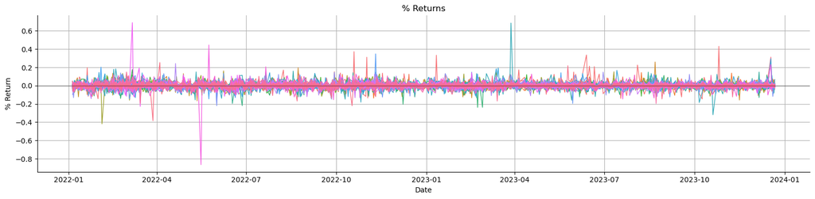

```python
pre_processor.plot_returns()
```

### 0.3 Annualization Factor

The annualization factor is computed as:

$$ AF = \frac{\text{number of observations}}{\text{calendar days} / 365} $$

```python
annualization_factor = pre_processor.get_annualization_factor()
```

Annualization Factor: 254.02

### 0.4 Annualized Mean and Covariance

#### Annualized Mean and Covariance of Returns

Let

- $ R_t \in \mathbb{R}^d $ denote the vector of **daily returns** of $ d $ assets at time $ t $, for $ t = 1, \dots, T $.
- $AF$ denote the Annualization Factor

##### Daily Sample Mean

The empirical (daily) mean return vector is given by: $$ \hat{\mu}_{\text{daily}} = \frac{1}{T} \sum_{t=1}^{T} R_t. $$

##### Daily Sample Covariance Matrix

The empirical (daily) covariance matrix is given by $$ \hat{\Sigma}_{\text{daily}} = \frac{1}{T - 1} \sum_{t=1}^{T} \left( R_t - \hat{\mu}_{\text{daily}} \right) \left( R_t - \hat{\mu}_{\text{daily}} \right)^{\top}. $$

#### Annualized Mean Return

The annualized mean return vector is $$ \hat{\mu}_{\text{annual}} = AF \cdot \hat{\mu}_{\text{daily}}. $$

#### Annualized Covariance Matrix

The annualized covariance matrix is $$ \hat{\Sigma}_{\text{annual}} = AF \cdot \hat{\Sigma}_{\text{daily}}. $$

```python
data = pre_processor.get_data()

# Display the mean and covariance matrix
# display_matrix(data['M'], variable='M', max_size=15, edge_items=5)
# display_matrix(data['Sigma'], variable='\Sigma', max_size=15, edge_items=5)
```

### 0.5 Sharpe Ratios

The Sharpe ratio is defined as:

$$ SR_i = \frac{\mathbb{E}[R_i] - r_0}{\sqrt{\mathrm{Var}(R_i)}} $$

- Sort the stocks by the Sharpe ratio in descending order.
- Report the 15 stocks with the highest Sharpe ratio.

```python
sharpe_ratios = (pre_processor.mu_annual_returns - RISK_FREE_RATE) /  pre_processor.std_annual

sharpe_ratios_df = pd.DataFrame({
    "Mean": pre_processor.M,
    "Std": pre_processor.std_annual,
    "Sharpe": sharpe_ratios
}).sort_values("Sharpe", ascending=False)

display(pd.DataFrame(sharpe_ratios_df.head(PORTFOLIO_D)['Sharpe']))
```

|  | Sharpe |
| --- | --- |
| NEU.AX | 1.693122 |
| AZS.AX | 1.526059 |
| EMR.AX | 1.239481 |
| SMR.AX | 1.076119 |
| WHC.AX | 1.065210 |
| NHC.AX | 0.876673 |
| BGL.AX | 0.754688 |
| SVW.AX | 0.738161 |
| WOR.AX | 0.633920 |
| YAL.AX | 0.622428 |
| BOE.AX | 0.620713 |
| ORG.AX | 0.515365 |
| VNT.AX | 0.508062 |
| AGL.AX | 0.493500 |
| PME.AX | 0.477203 |

### 0.6 Investment Universe

- Calculate the empirical mean and covariance matrix of the (annualized) returns of the top 15 stocks identified in the previous step.
- These shall be one of the main inputs in the subsequent analyses.

> Hint: The Sharpe ratio you should get for AGL Energy Limited (ticker: AGL.AX) is **0.493500**.

For the rest of the assignment, we will assume that the top 15 stocks (in terms of the Sharpe ratio) comprise the investment universe or the set of risky assets we can invest in.

Denote this set of risky assets/stocks by $\mathcal{S}$.

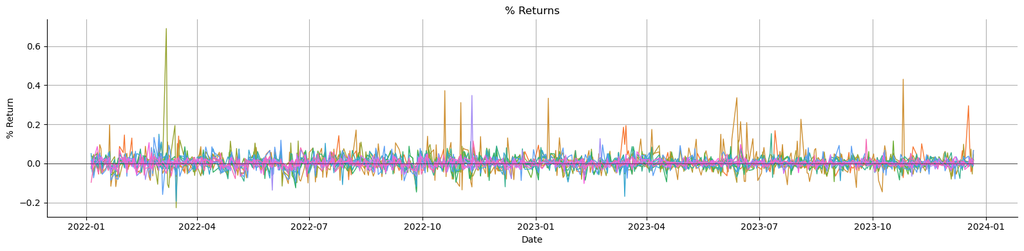

```python
portfolio_tickers = sharpe_ratios_df.head(PORTFOLIO_D).index
S = data_collection.prices[portfolio_tickers]
benchmark_prices = data_collection.prices[INDEX_TICKER]
portfolio_pre_processor = DataPreProcessor(
    return_type=ReturnType.PERCENTAGE,
    close_prices=pd.concat([benchmark_prices, S], axis=1),
    annualization_factor=None,
    index_ticker=INDEX_TICKER
    )

portfolio_data = portfolio_pre_processor.run()
portfolio_pre_processor.plot_returns()
```

```python
assert portfolio_pre_processor.get_annualization_factor(display_output=False) == pre_processor.get_annualization_factor(display_output=False)
```

```python
# Display the mean and covariance matrix
# variable='M_{annual}'
# display_matrix(portfolio_data['M'], variable, max_size=15, edge_items=5)

# variable='\Sigma_{annual}'
# display_matrix(portfolio_data['Sigma'], variable, max_size=15, edge_items=5)
```

```python
# portfolio_pre_processor.plot_covariance_matrix()
# portfolio_pre_processor.plot_covariance_matrix()
```

- A hierarchically clustered heatmap is used to reveal groups of assets with similar dependence profiles, providing intuition for the subsequent PCA-based factor analysis.

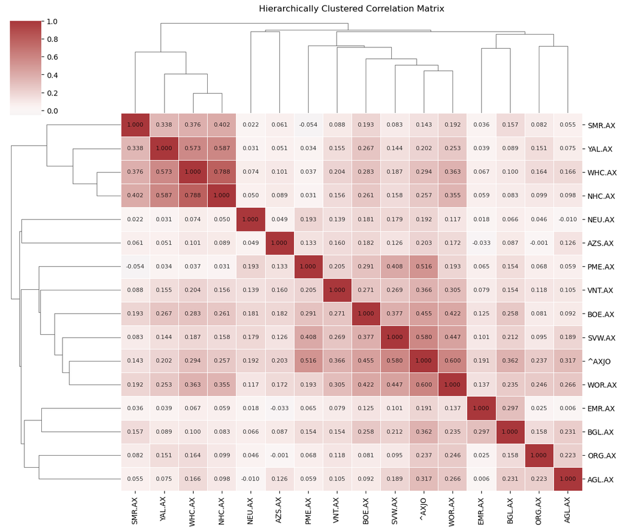

```python
portfolio_pre_processor.plot_hierarchical_correlation_matrix()
```

The hierarchically clustered correlation matrix reveals clear block structure in the asset correlations, indicating that many assets are driven by a small number of common sources of risk.

This provides visual justification for a low-dimensional PCA k-factor model, as the covariance matrix is approximately low-rank. Assets within the same cluster are expected to load similarly on the leading principal components, while differences across clusters are captured by subsequent factors.

The presence of the ASX200 within a large correlation cluster suggests that the first principal component will resemble a market-wide factor.

```python
# Check the Sharpe ratio for AGL.AX (hint given in the assignment)
assert np.isclose(sharpe_ratios_df.loc['AGL.AX', 'Sharpe'], 0.493500)
```

## Part 1: Markowitz Mean-Variance and Tracking Error Variance Optimization

```python
MV = MarkowitzOptimisation(
    M=portfolio_data['M'],
    Sigma=portfolio_data['Sigma'],
    risk_free_rate=RISK_FREE_RATE,
    tickers=portfolio_data['tickers'],
    index_ticker=INDEX_TICKER,
    benchmark_mean=portfolio_data['mu_annual_index'],
    # benchmark_var=portfolio_data['var_annual_index'],
    benchmark_std=portfolio_data['sigma_annual_index'],
    annualization_factor=portfolio_pre_processor.get_annualization_factor(display_output=False),
    target_expected_return=TARGET_RETURN,
    display_output=False,
    logs=False)
MV.run()
```

### **Markowitz Mean-Variance (MV) Analysis**

### 1.1.1 Mean-Variance Portfolio (No Risk-Free Asset)

- Determine the mean-variance optimal (MV-optimal) portfolio with no risk-free asset $\phi_{NRF}$ for the given target expected return.
- Report the mean return and the standard deviation of the return of $\phi_{NRF}$.

##### Markowitz Mean–Variance Framework (No Risk-Free Asset)

**Market Setting**

We consider a one-period market with $d \ge 2$ risky assets and trading dates $t=0$ and $t=T$.

- Asset prices:

$$ S_t = (S_t^1, \dots, S_t^d)^\top $$

- Asset (percent) returns:

$$ R_T^i = \frac{S_T^i - S_0^i}{S_0^i}, \qquad R_T = (R_T^1, \dots, R_T^d)^\top $$

- Mean vector and covariance matrix:

$$ M := \mathbb{E}[R_T], \qquad \Sigma := \operatorname{Cov}(R_T, R_T) $$

We assume throughout that $\Sigma$ is positive definite, ensuring the absence of arbitrage.

**Portfolio Representation**

A portfolio is represented by a weight vector $$ \phi = (\phi_1, \dots, \phi_d)^\top \in \mathbb{R}^d. $$

- Investment portfolio:

$$ \phi^\top \mathbf{1}_d = 1 $$

- Self-financing portfolio:

$$ \phi^\top \mathbf{1}_d = 0 $$

The portfolio return satisfies $$ R_T(\phi) = \phi^\top R_T. $$

**Portfolio Mean and Variance**

For any portfolio $\phi$,

- Expected return:

$$ m_\phi := \mathbb{E}[R_T(\phi)] = \phi^\top M $$

- Variance:

$$ \sigma_\phi^2 := \operatorname{Var}(R_T(\phi)) = \phi^\top \Sigma \phi $$

These identities justify the mean–variance trade-off underlying the Markowitz framework.

**The Markowitz Optimization Problem**

Given a target expected return $\bar{m}$, the investor solves

$$ \begin{aligned} \min_{\phi \in \mathbb{R}^d} \quad & \phi^\top \Sigma \phi \ \quad \text{subject to} \quad & \phi^\top M = \bar m, \ & \phi^\top \mathbf{1}_d = 1. \end{aligned} \tag{MP} $$

This problem identifies the minimum-variance portfolio achieving expected return $\bar{m}$.

**Inner Product Representation**

Define the $\Sigma^{-1}$-inner product: $$ \langle x, y \rangle_{\Sigma^{-1}} := x^\top \Sigma^{-1} y, \qquad |x|_{\Sigma^{-1}} := \sqrt{x^\top \Sigma^{-1} x}. $$

Let $$ a := \mathbf{1}_d^\top \Sigma^{-1} \mathbf{1}_d, \qquad b := M^\top \Sigma^{-1} \mathbf{1}_d. $$

i.e. these vectors are orthogonal under the $\Sigma^{-1}$-inner product.

**Efficient Frontier Representation**

Theorem (Efficient Frontier)

The set of fully invested mean–variance portfolios is $$ \mathcal{F} = { \phi_a + \lambda \omega_{a,b} : \lambda \in \mathbb{R} }, $$

where

- Minimum-variance portfolio:

$$ \phi_a := \frac{1}{a}\Sigma^{-1}\mathbf{1}_d $$

- Self-financing portfolio:

$$ \omega_{a,b} := \frac{ \Sigma^{-1}\left( M - \frac{b}{a} 1_d \right) } { \left\|\, M - \frac{b}{a} 1_d \,\right\|_{\Sigma^{-1}} } $$

Every efficient portfolio is a linear combination of these two portfolios.

**Properties of Efficient Portfolios**

For $\phi = \phi_a + \lambda \omega_{a,b}$:

- Expected return:

$$ m_\phi = m_{\phi_a} + \lambda m_{\omega_{a,b}} $$

- Variance:

$$ \sigma_\phi^2 = \sigma_{\phi_a}^2 + \lambda^2 $$

- Covariance:

$$ \operatorname{Cov}(R(\phi_a), R(\omega_{a,b})) = 0 $$

Hence, the efficient frontier in the $(\sigma_\phi, m_\phi)$-plane satisfies $$ \sigma_\phi^2 = \sigma_{\phi_a}^2 + \left( \frac{m_\phi - m_{\phi_a}}{m_{\omega_{a,b}}} \right)^2, $$ which is a hyperbola (the “Markowitz bullet”).

**Efficient vs Inefficient Frontier**

Define: $$ \mathcal{F}^+ := {\phi_a + \lambda \omega_{a,b} : \lambda \ge 0}, \quad \mathcal{F}^- := {\phi_a + \lambda \omega_{a,b} : \lambda \le 0}. $$

- $\mathcal{F}^+$: efficient frontier
- $\mathcal{F}^-$: inefficient frontier

The minimum-variance portfolio $\phi_a$ is the vertex of the frontier.

> References
> - University of Technology Sydney. (2025) *1 Markowitz Framework with No Risk-Free Asset* [Lecture]. Faculty of Science, Master of Quantitative Finance, University of Technology Sydney.

```python
phi_allocation, phi, mu_phi, Sigma_phi, std_phi = MV.mean_variance_optimal_portfolio_no_risk_free(display_output=False)
display(Markdown("### Mean-Variance (No Risk-Free) Optimal Portfolio $\phi_{NRF}$"))
display(phi_allocation)
display(Markdown(f"### Mean Return of $\\phi_{{NRF}}$: {mu_phi * 100:.2f}%"))
display(Markdown(f"### Standard Deviation of $\\phi_{{NRF}}$: {std_phi * 100:.4f}%"))
```

Mean-Variance (No Risk-Free) Optimal Portfolio $\phi_{NRF}$

|  | Allocation |
| --- | --- |
| Risk-Free | 0.0 |
| NEU.AX | 0.108354 |
| AZS.AX | 0.04395 |
| EMR.AX | 0.174137 |
| SMR.AX | 0.044145 |
| WHC.AX | -0.002487 |
| NHC.AX | 0.032478 |
| BGL.AX | -0.013061 |
| SVW.AX | 0.224777 |
| WOR.AX | 0.015435 |
| YAL.AX | 0.028985 |
| BOE.AX | -0.058979 |
| ORG.AX | 0.083532 |
| VNT.AX | 0.109593 |
| AGL.AX | 0.160512 |
| PME.AX | 0.048628 |

Mean Return of $\phi_{NRF}$: 50.00%

Standard Deviation of $\phi_{NRF}$: 17.0533%

### 1.1.2 Mean-Variance Portfolio (With Risk-Free Asset)

- Determine the MV-optimal portfolio with a risk-free asset allocation $\varphi_{WRF}$ for the given target expected return.
- Report the mean return and the standard deviation of the return of $\varphi_{WRF}$.

##### Markowitz Mean–Variance Framework (With a Risk-Free Asset)

**Market Setting**

Extending the Markowitz framework by introducing a risk-free asset with deterministic return $$ r_0 \in \mathbb{R}. $$

The investment universe consists of:

- $d$ risky assets with return vector

$$ R_T = (R_T^1, \dots, R_T^d)^{\top} $$

- one risk-free asset with return $r_0$.

Let $$ M := \mathbb{E}[R_T], \qquad \Sigma := \operatorname{Cov}(R_T,R_T), $$

where $\Sigma$ is assumed to be positive definite.

**Portfolio Representation**

A portfolio is written as $$ \varphi = (\varphi_0, \phi^\top)^\top \in \mathbb{R}^{d+1}, $$ where:

- $\varphi_0$ is the weight in the risk-free asset,
- $\phi \in \mathbb{R}^d$ are the weights of the risky assets.

A fully invested portfolio satisfies $$ \varphi_0 + \phi^\top \mathbf{1}_d = 1. $$

The portfolio return is $$ R_T(\varphi) = \varphi_0 r_0 + \phi^\top R_T. $$

**Mean and Variance of Portfolio Returns**

The expected return of $\varphi$ is $$ m_\varphi := \mathbb{E}[R_T(\varphi)] = \varphi_0 r_0 + \phi^\top M. $$

The variance is $$ \sigma_\varphi^2 := \operatorname{Var}(R_T(\varphi)) = \phi^\top \Sigma \phi, $$

since the risk-free asset has zero variance and zero covariance with risky assets.

**Mean–Variance Optimization with a Risk-Free Asset**

The investor seeks an investment portfolio φ with risky allocation $\varphi$ which solves the problem

$$ \min_{\phi \in \mathbb{R}^{d}} \phi^{\top} \Sigma \phi \qquad \text{subject to} \qquad r_0 + \phi^{\top} (M - \mathbf{1}_{d}) = \bar{m} \qquad \tag{MP-RF} $$

or equivalently $$ \min_{\phi \in \mathbb{R}^{d}} \langle \Sigma \phi, \Sigma \phi \rangle_{\Sigma^{-1}} \qquad \text{subject to} \qquad \langle \Sigma \phi, M - r_0 \mathbf{1}_{d} \rangle_{\Sigma^{-1}} = m - r_0 \qquad \tag{MP-RF2} $$

for some given $\bar{m} \in \mathbb{R}$

This optimization problem has a closed-form solution and leads to a linear efficient frontier.

**The Tangent Portfolio**

For an investment portfolio $\varphi$ with risky allocation $\phi$, $$ \mathcal{R}(\varphi) = r_0 + \phi^{\top} (\mathcal{R} - \mathcal{R}_0 \mathbf{1}_{d}), \qquad m_{\varphi} = r_0 + \phi^{\top} (M - r_0 \mathbf{1}_{d}), \qquad \sigma_{\varphi} = \sqrt{\phi^{\top} \Sigma \phi} $$

For a self-financing portfolio $\varphi$ with risky allocation $\phi$, $$ \mathcal{R}(\varphi) = \phi^{\top} (\mathcal{R} - r_0 \mathbf{1}_{d}), \qquad m_{\varphi} = \phi^{\top} (M - r_0 \mathbf{1}_{d}), \qquad \sigma_{\varphi} = \sqrt{\phi^{\top} \Sigma \phi} $$

For either a self-financing or investment portfolio $\varphi$, we have $$ R(\varphi) = \varphi^{\top} \begin{pmatrix} r_0 \\ \mathcal{R} \end{pmatrix} = \phi_0 r_0 + \phi^{\top} \mathcal{R} $$

The Portfolio $\varphi_{\tau}$

$$ \varphi_\tau := \begin{pmatrix} 0 \\ \phi_\tau \end{pmatrix}, \qquad \text{where} \qquad \phi_\tau := \frac{1}{b - r_0 a}\, \Sigma^{-1}\bigl(M - r_0 \mathbf{1}_d\bigr). $$

where $$ a := \langle 1_d, 1_d \rangle_{\Sigma^{-1}}, \qquad b := \langle M, 1_d \rangle_{\Sigma^{-1}}. $$

The portfolio $\varphi_{\tau}$ is an investment portfolio with no allocation to the risk-free asset.

Furthermore, it satisfies $$ m_{\varphi_{\tau}} = r_0 + \dfrac{1}{b - r_0 a} \left\|\, M - r_0 \mathbf{1}_{d} \,\right\|_{\Sigma^{-1}}^{2} $$

and

$$ \sigma_{\varphi_{\tau}}^{2} = \dfrac{1}{(b - r_0 a)^2} \left\|\, M - r_0 \mathbf{1}_{d} \,\right\|_{\Sigma^{-1}}^{2} $$

Under the assumption $r_0 < \frac{b}{a}$, we find that $m_{\varphi_{\tau}} > r$,

i.e. $\varphi_{\tau}$ is expected to earn more than the risk-free asset.

The tangent portfolio maximizes the Sharpe ratio among all risky portfolios.

**Separation Theorem (Two-Fund Theorem)**

Theorem (Separation Theorem) Every mean–variance efficient portfolio with a risk-free asset can be written as $$ \varphi = \lambda \varphi_{\tau} + (1 - \lambda) \varphi_0, \qquad \text{where} \qquad \lambda = \dfrac{\bar{m} - r_0}{m_{\varphi_{\tau}} - r_0} $$

where:

- $\varphi_\tau = (0,\phi_\tau^\top)^\top$ is the tangent portfolio,
- $\varphi_0 = (1,0,\dots,0)^\top$ is the pure risk-free portfolio,
- $\lambda \in \mathbb{R}$ determines leverage.

Thus:

- the choice of risky assets is independent of investor preferences,
- all investors hold the same risky portfolio $\phi_\tau$,
- only the allocation between risky and risk-free assets differs.

**Capital Market Line (CML)**

For portfolios of the form above: $$ m_\varphi = r_0 + \lambda (m_{\varphi_\tau} - r_0), \qquad \sigma_\varphi = |\lambda|, \sigma_{\varphi_\tau}. $$

$$ \text{Capital Market Line}: \qquad \sigma = \frac{\sigma_{\varphi_\tau}}{m_{\varphi_\tau} - r_0} (m - r_0) $$

The CML is a straight line in the $(\sigma,m)$ plane tangent to the efficient frontier of risky assets.

**Relation to CAPM**

If the tangent portfolio coincides with the market portfolio, expected returns satisfy the Security Market Line $$ \mathbb{E}[R_i] - r_0 \beta_i(\mathbb{E}[R_\tau] - r_0), $$

with $$ \beta_i \frac{\operatorname{Cov}(R_i,R_\tau)}{\operatorname{Var}(R_\tau)}. $$

> References
> - University of Technology Sydney. (2025) *2 Markowitz Framework with a Risk-Free Asset* [Lecture]. Faculty of Science, Master of Quantitative Finance, University of Technology Sydney.

```python
varphi_allocation, varphi, mu_varphi, Sigma_varphi, std_varphi = MV.mean_variance_optimal_portfolio_with_risk_free(display_output=False)
display(Markdown("### Mean-Variance Optimal Portfolio $\\varphi_{WRF}$"))
display(varphi_allocation)
display(Markdown(f"### Mean Return of $\\varphi_{{WRF}}$: {mu_varphi * 100:.2f}%"))
display(Markdown(f"### Standard Deviation of $\\varphi_{{WRF}}$: {std_varphi * 100:.4f}%"))
```

Mean-Variance Optimal Portfolio $\varphi_{WRF}$

|  | Allocation |
| --- | --- |
| Risk-Free | 0.524659 |
| NEU.AX | 0.139061 |
| AZS.AX | 0.07315 |
| EMR.AX | 0.153832 |
| SMR.AX | 0.052877 |
| WHC.AX | 0.056969 |
| NHC.AX | 0.000583 |
| BGL.AX | 0.001967 |
| SVW.AX | 0.054155 |
| WOR.AX | -0.075053 |
| YAL.AX | -0.003655 |
| BOE.AX | -0.028402 |
| ORG.AX | 0.043353 |
| VNT.AX | -0.026317 |
| AGL.AX | 0.036307 |
| PME.AX | -0.003486 |

Mean Return of $\varphi_{WRF}$: 50.00%

Standard Deviation of $\varphi_{WRF}$: 14.2131%

### 1.1.3 Interpretation

- Briefly compare and discuss the MV-optimal portfolios with and without the risk-free asset in terms of composition and overall riskiness.
- Does either portfolio demand a large long or short position in any of the risky assets?
- Comment on whether there are any challenges in implementing these optimal portfolios in practice.

The inclusion of the risk-free asset allows the investor to allocate approximately 52.5% of capital to the risk-free asset and invest the remainder in the tangency portfolio of risky assets.

This reduces total portfolio variance while maintaining the target expected return, resulting in a substantially lower overall risk compared to the MV portfolio without a risk-free asset, which must rely entirely on risky securities to achieve the same return.

Neither portfolio exhibits extreme positions in individual risky assets.

The largest long positions are moderate, and the short positions are small in magnitude, indicating that the optimisation does not depend on highly leveraged or concentrated bets.

However, practical implementation challenges remain due to the presence of short positions and the assumption of frictionless borrowing and lending at the risk-free rate.

In addition, both portfolios are sensitive to estimation error in the mean and covariance matrix, which may lead to unstable weights and frequent rebalancing in practice.

### 1.1.4 Mean-Variance Efficient Frontier and Capital Market Line

- Construct the MV efficient frontier, its asymptote, and the capital market line associated to this investment universe for the range $m \in [−0.5,1.0]$.
- Display these, along with the risk-return representation of $\phi_a$, $\omega_{a,b}$, $\varphi_{\tau}$, $\phi_{NRF}$, $\varphi_{WRF}$, and the ASX 200 index, on a plot on the risk-return space.
- Is the ASX 200 index efficient in this investment universe? Comment further on the risk-return characteristics of the ASX 200 using the plot you generated.

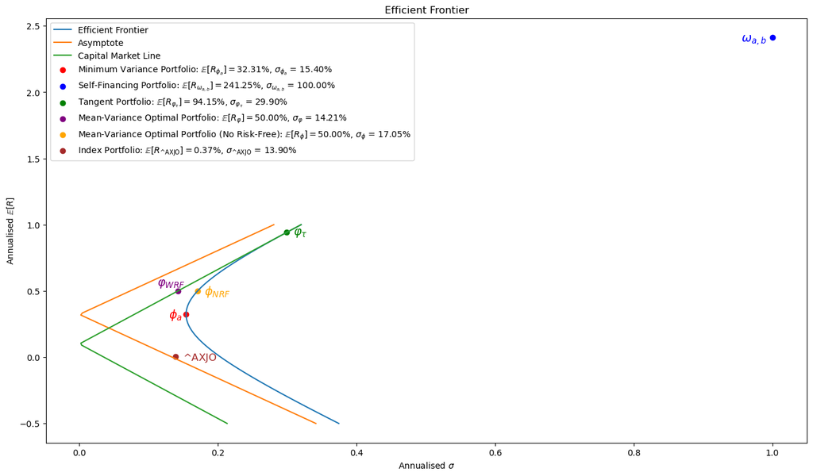

```python
MV.efficient_frontier()
```

```python
mv_compare = pd.DataFrame(index=['Expected Return', 'Standard Deviation'], columns=['Min-Variance Portfolio', 'MV-Optimal Portfolio (No Risk-Free)', 'MV-Optimal Portfolio (With Risk-Free)', 'ASX200'], data=[[MV.m_phi_a, MV.m_phi, MV.m_varphi, MV.benchmark_mu], [MV.sigma_phi_a, MV.sigma_phi, MV.sigma_varphi, MV.benchmark_std]])
mv_compare['Min-Variance vs ASX200'] = mv_compare['Min-Variance Portfolio'] - mv_compare['ASX200']
mv_compare['MV-Optimal (No Risk-Free) vs ASX200'] = mv_compare['MV-Optimal Portfolio (No Risk-Free)'] - mv_compare['ASX200']
mv_compare['MV-Optimal (With Risk-Free) vs ASX200'] = mv_compare['MV-Optimal Portfolio (With Risk-Free)'] - mv_compare['ASX200']
mv_compare.round(4)
mv_compare = mv_compare[[
    'ASX200',
    'Min-Variance Portfolio',
    'Min-Variance vs ASX200',
    'MV-Optimal Portfolio (No Risk-Free)',
    'MV-Optimal (No Risk-Free) vs ASX200',
    'MV-Optimal Portfolio (With Risk-Free)',
    'MV-Optimal (With Risk-Free) vs ASX200'
]].T

display(mv_compare.round(4))
```

|  | Expected Return | Standard Deviation |
| --- | --- | --- |
| ASX200 | 0.0037 | 0.1390 |
| Min-Variance Portfolio | 0.3231 | 0.1540 |
| Min-Variance vs ASX200 | 0.3194 | 0.0150 |
| MV-Optimal Portfolio (No Risk-Free) | 0.5000 | 0.1705 |
| MV-Optimal (No Risk-Free) vs ASX200 | 0.4963 | 0.0316 |
| MV-Optimal Portfolio (With Risk-Free) | 0.5000 | 0.1421 |
| MV-Optimal (With Risk-Free) vs ASX200 | 0.4963 | 0.0032 |

The ASX200 is not efficient in this investment universe.

The annualized expected return of the ASX200 is $\approx 0.37\%$ with an annualized standard deviation of $\approx 13.9\%$.

The ASX200 represents a significantly lower expected return for a marginally lower risk when compared to the MV-optimal portfolios.

### **Tracking Error Variance (TEV) Analysis**

```python
TEV = TrackingErrorVariance(
    returns=portfolio_pre_processor.returns,
    M=portfolio_data['M'],
    Sigma=portfolio_data['Sigma'],
    risk_free_rate=RISK_FREE_RATE,
    tickers=portfolio_data['tickers'],
    index_ticker=INDEX_TICKER,
    benchmark_mean=portfolio_data['mu_annual_index'],
    benchmark_std=portfolio_data['sigma_annual_index'],
    annualization_factor=portfolio_pre_processor.get_annualization_factor(display_output=False),
    target_expected_return=TARGET_RETURN,
    display_output=False,
    logs=False
)
TEV.run()
```

### 1.2.1 Stock $\beta$

- For each stock in $\mathcal{S}$:
  - Determine its beta with respect to the ASX 200.
  - Report the estimated betas graphically using a scatter plot whose x-axis is the stock’s beta and whose y-axis is the stock’s expected excess return.
- Would you expect the points to be perfectly aligned?
- Explain why or why not.

$\hat{\beta}$ with respect to the ASX 200

|  | Beta |
| --- | --- |
| NEU.AX | 0.810390 |
| AZS.AX | 1.494699 |
| EMR.AX | 0.570029 |
| SMR.AX | 0.779269 |
| WHC.AX | 1.050800 |
| NHC.AX | 0.907984 |
| BGL.AX | 1.312078 |
| SVW.AX | 0.949406 |
| WOR.AX | 1.133475 |
| YAL.AX | 0.715485 |
| BOE.AX | 1.955440 |
| ORG.AX | 0.649835 |
| VNT.AX | 0.732373 |
| AGL.AX | 0.659525 |
| PME.AX | 1.345087 |

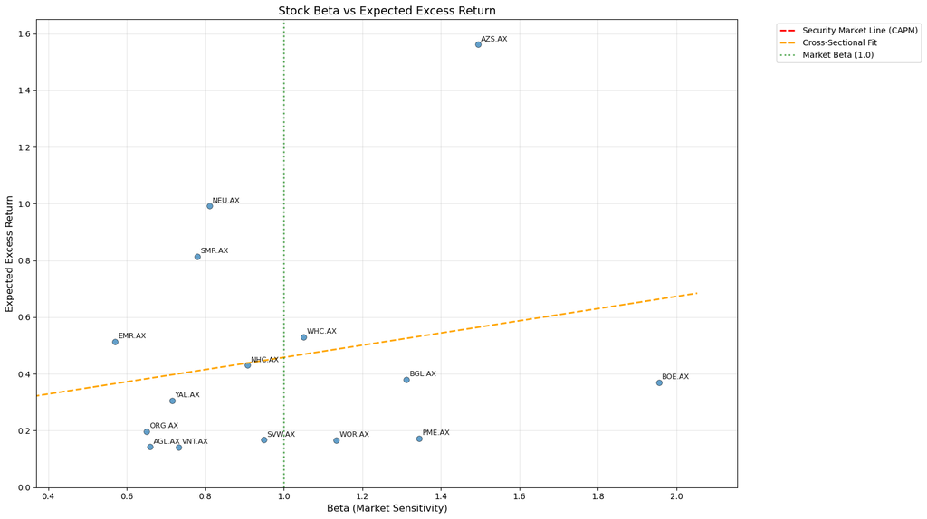

```python
display(Markdown(f"### $\hat{{\\beta}}$ with respect to the ASX 200"))
display(pd.DataFrame(TEV.beta_benchmark['Beta']))
TEV.plot_security_market_line()
```

For each stock in $\mathcal{S}$, the $\beta$ with respect to the ASX200 is estimated as the slope coefficient from a time-series regression of the stock’s excess return on the ASX 200 excess return.

The points are not expected to be perfectly aligned along a straight line. Perfect alignment would require the CAPM to hold exactly and the expected returns to be measured without error.

In practice, expected returns are estimated from a finite sample and are subject to significant estimation noise, particularly over short horizons. This leads to significant dispersion of points around the theoretical line.

In addition, stock returns contain substantial idiosyncratic components that are not explained by market beta alone, leading to dispersion around the Security Market Line.

This lack of perfect alignment provides empirical motivation for multi-factor asset pricing models beyond the single-factor CAPM.

In the empirical scatter plot, the Security Market Line is not clearly visible because the estimated market risk premium over the sample is negative.

As a result, the CAPM-implied relationship between beta and expected excess return is weak.

Note: The cross-sectional regression line represents the best linear fit between estimated betas and expected excess returns in the sample.

### 1.2.2 TEV-optimal portfolio

- For the given target expected return:
  - Determine the composition of the TEV-optimal portfolio $\phi_{TEV}$.
  - Report the mean and standard deviation of its return.
  - What is the TEV achieved by this portfolio?
- Does the portfolio demand a large long or short position in any of the risky assets?
- Comment on whether there are any challenges in implementing this portfolio in practice.

##### Tracking Error Variance (TEV)

Market setup (one-period model)

Consider a market with $d \ge 2$ risky assets and return vector $$ R = (R_1,\ldots,R_d)^\top, $$

with mean vector and covariance matrix $$ M := \mathbb{E}[R] \in \mathbb{R}^d, \qquad \Sigma := \mathrm{Cov}(R,R) \in \mathbb{R}^{d\times d}. $$

For a portfolio $\phi \in \mathbb{R}^d$, the expected return and variance are $$ m_\phi = \mathbb{E}[R(\phi)] = \phi^\top M, \qquad \sigma_\phi^2 = \mathrm{Var}(R(\phi)) = \phi^\top \Sigma \phi. $$

**Benchmark (index) portfolio**

Let $\phi_B$ denote the benchmark (index) portfolio, satisfying $$ \mathbf{1}^\top \phi_B = 1. $$

Its expected return and variance are $$ m_B = \phi_B^\top M, \qquad \sigma_B^2 = \phi_B^\top \Sigma \phi_B. $$

**Betas with respect to the benchmark**

The beta of asset $i$ relative to the benchmark is defined as $$ \beta_{B,i} := \frac{\mathrm{Cov}(R(\phi_B), R_i)}{\sigma_B^2}, \qquad i = 1,\ldots,d. $$

Collecting these into a vector gives $$ \beta_B = (\beta_{B,1},\ldots,\beta_{B,d})^\top \in \mathbb{R}^d. $$

For any portfolio $\phi$, the benchmark beta is $$ \beta_B(\phi) := \frac{\mathrm{Cov}(R(\phi_B), R(\phi))}{\sigma_B^2} = \phi^\top \beta_B. $$

In practice, $\beta_B$ is estimated via linear regression of asset returns on benchmark returns.

**Tracking Error Variance (TEV) Portfolio**

- The **tracking error variance** of the portfolio $\phi$ with respect to the benchmark is the variance of the difference between the (random) returns of $\phi$ and $\phi_{B}$

$$ \operatorname{TEV}_{B}(\phi) := \operatorname{Var}(\mathcal{R}(\phi) - \mathcal{R}(\phi_B)) $$

- Using the properties of the variance, the TEV can be written as

$$ \operatorname{TEV}_{B}(\phi) = \sigma^{2}_{\phi} + \sigma^{2}_{B} - 2 \sigma^{2}_{B} \phi^{\top} \beta_{B} $$

- Note: only the first and last terms depend on the choice of $\phi$

**TEV Minimization Problem**

$$ \min_{\phi \in \mathbb{R}^{d}} \qquad (\frac{1}{2}\phi^{\top} \Sigma \phi - \phi^{2}_{B} \phi^{\top} \beta_B) \quad \text{subject to} \qquad \phi^{\top} (M - \mathbf{1}_{d}) = \bar{m}, \quad \mathbf{1}^{\top}_{d} \phi = 1 \tag{TEV} $$

**Solution of TEV Problem**

In this section, we define the following matrices:

\begin{align*} \mathbf{B} & := [M, \mathbf{1}_d] \in \mathbb{R}^{d\times 2} \\ \mathbf{Q} & := \mathbf{B}_\perp (\mathbf{B}_\perp^\top \Sigma \mathbf{B}_\perp)^{-1} \mathbf{B}_\perp^\top \in \mathbb{R}^{d \times d} \\ (\mathbf{B}^\top)^\mathscr{r} & := \mathbf{B} (\mathbf{B}^\top \mathbf{B})^{-1} \in \mathbb{R}^{d \times 2}\\ \mathbf{C} & := (\mathbf{I}_d - \mathbf{Q} \Sigma) (\mathbf{B}^\top)^\mathscr{r} \in \mathbb{R}^{d \times 2} \end{align*}

which are needed to characterize the TEV optimal portfolios

$$\phi_{TEV} = \phi^* = \sigma_B^2 \mathbf{Q} \beta_B + \mathbf{C} \left[\begin{array}{c} \bar{m} \\ 1 \end{array}\right], \qquad \bar{m} \in \mathbb{R}$$

and the TEV efficient frontier $\mathscr{T}(\sigma, m)$.

> References
> - University of Technology Sydney. (2025) *3 Index Tracking and Tracking Error Variance Minimization* [Lecture]. Faculty of Science, Master of Quantitative Finance, University of Technology Sydney.*
> - University of Technology Sydney. (2025) Supplement: *3 Index Tracking and TEV Minimization* [Lecture]. Faculty of Science, Master of Quantitative Finance, University of Technology Sydney.

```python
phi_allocation_tev, phi_tev, mu_phi_tev, Sigma_phi_tev, std_phi_tev = TEV.tev_portfolio()
display(Markdown("### Tracking Error Variance Optimal Portfolio $\\phi_{{tev}}$"))
display(phi_allocation_tev)
display(Markdown(f"### Mean Return of $\\phi_{{TEV}}$: {mu_phi_tev * 100:.2f}%"))
display(Markdown(f"### Standard Deviation of $\\phi_{{TEV}}$: {std_phi_tev * 100:.4f}%"))
```

Tracking Error Variance Optimal Portfolio $\phi_{{tev}}$

|  | Allocation |
| --- | --- |
| Risk-Free | 0.0 |
| NEU.AX | 0.093637 |
| AZS.AX | 0.048529 |
| EMR.AX | 0.125025 |
| SMR.AX | 0.036581 |
| WHC.AX | 0.041212 |
| NHC.AX | 0.009295 |
| BGL.AX | 0.029215 |
| SVW.AX | 0.18874 |
| WOR.AX | 0.115576 |
| YAL.AX | -0.001024 |
| BOE.AX | -0.007266 |
| ORG.AX | 0.055599 |
| VNT.AX | 0.044887 |
| AGL.AX | 0.100227 |
| PME.AX | 0.119767 |

Mean Return of $\phi_{TEV}$: 50.00%

Standard Deviation of $\phi_{TEV}$: 18.1010%

The TEV-optimal portfolio achieves the target return while closely tracking the benchmark, using diversified and moderate positions rather than aggressive long–short exposures.

For the given target expected return of 50% per annum, the TEV-optimal portfolio is a fully invested risky portfolio with no allocation to the risk-free asset.

The portfolio is broadly diversified across the assets in $\mathcal{S}$, with moderate weights in several stocks and no dominant exposure. This is consistent with the tracking-error-variance objective, which seeks to minimise deviations from the benchmark return rather than total portfolio variance.

The optimisation does not require large long or short positions.

- All short positions are negligible in magnitude,
- largest long positions remain moderate, suggesting that benchmark alignment is achieved through diversification rather than leverage.

In practice, the main implementation challenge arises from the need to frequently rebalance the portfolio as estimated betas and covariances evolve, which may increase transaction costs despite the absence of extreme positions.

### 1.2.3 $\beta$ of $\phi_{TEV}$ with respect to the ASX 200

- Report the beta of the TEV-optimal portfolio with respect to the ASX 200
- Compare this to the beta of the MV-optimal portfolios (with and without a risk-free asset).
- Briefly discuss what these betas imply regarding the riskiness of the optimal portfolios relative to the ASX 200.

```python
beta_TEV = phi_tev @ TEV.beta_benchmark.loc[TEV.portfolio_tickers, "Beta"].values
beta_phi_NRF = phi @ TEV.beta_benchmark.loc[TEV.portfolio_tickers, "Beta"].values
beta_phi_WRF = varphi[1:] @ TEV.beta_benchmark.loc[TEV.portfolio_tickers, "Beta"].values

display(Markdown(f"#### $\\beta_{{\phi_{{TEV}}}} = {beta_TEV:.4f}$"))
display(Markdown(f"#### $\\beta_{{\phi_{{NRF}}}} = {beta_phi_NRF:.4f}$"))
display(Markdown(f"#### $\\beta_{{\\varphi_{{WRF}}}} = {beta_phi_WRF:.4f}$"))
```

$\beta_{\phi_{TEV}} = 0.9297$

$\beta_{\phi_{NRF}} = 0.7390$

$\beta_{\varphi_{WRF}} = 0.3502$

#### Interpretation of $\beta$

- $\beta \approx 1$: The portfolio closely matches the benchmark’s systematic risk.
- $\beta < 1$: The portfolio underweights market exposure.
- $\beta > 1$: The portfolio overweights market exposure.

$\beta_{\phi_{TEV}}$ is the closest to $1$ and is the portfolio that is the closest to matching the systematic risk of the ASX 200

$\beta_{\phi_{NRF}}$ is moderately underweight to the ASX 200 market exposure.

$\beta_{\varphi_{WRF}}$ is underweight to the ASX 200 market exposure.

### 1.2.4. TEV Efficient Frontier

- Construct the TEV efficient frontier for this investment universe. Add the:
  - TEV efficient frontier
  - The risk-return representation of $\phi_{TEV}$ to the earlier visualization in the risk-return space
  - Display the updated plot
- Discuss the risk-return representation of the ASX 200 relative to the TEV frontier.
- In this investment universe, does the ASX 200 lie on the TEV frontier?
- Explain why or why not.

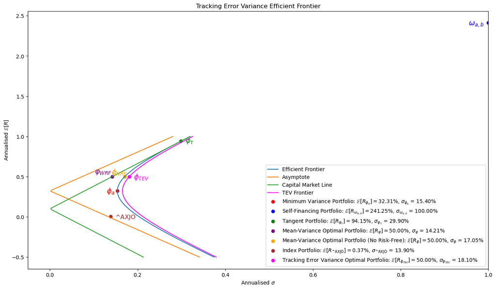

```python
TEV.tev_efficient_frontier()
```

```python
mv_compare = pd.DataFrame(index=['Expected Return','Standard Deviation'], columns=['TEV Portfolio','ASX200'], data=[[TEV.m_phi_tev, TEV.benchmark_mu], [TEV.sigma_phi_tev, TEV.benchmark_std]])
mv_compare['TEV Portfolio vs ASX200'] = mv_compare['TEV Portfolio'] - mv_compare['ASX200']
mv_compare.round(4)
mv_compare = mv_compare[['ASX200', 'TEV Portfolio', 'TEV Portfolio vs ASX200']].T

display(mv_compare)
```

|  | Expected Return | Standard Deviation |
| --- | --- | --- |
| ASX200 | 0.003695 | 0.138975 |
| TEV Portfolio | 0.500000 | 0.181010 |
| TEV Portfolio vs ASX200 | 0.496305 | 0.042035 |

The ASX 200 does not lie on the TEV efficient frontier because it is not an attainable portfolio within the given investment universe.

The TEV frontier is constructed using only the assets in $\mathcal{S}$, and since the ASX 200 is neither included in $\mathcal{S}$ nor exactly replicable by the assets in $\mathcal{S}$, zero tracking error is not achievable.

Consequently, the benchmark appears off the TEV frontier, which instead represents the best possible benchmark-tracking portfolios attainable with the available assets.

## Part 2: k-Factor Models and Arbitrage Pricing Theory

### 2.1. Fit the k-Factor Model

- Construct the centered returns time series data for the risky assets in $\mathcal{S}$
- Construct the covariance matrix $\hat{\Sigma}_c$ of the centered returns. **Do not annualize $\hat{\Sigma}_c$ for this analysis**.
- Determine the singular value decomposition (SVD) of $\hat{\Sigma}_c$
- What is the total variance or inertia of the sample?
- Display the cumulative proportion of the total variance explained by each principal component of $\hat{\Sigma}_c$.

##### PCA / k-Factor Model

Notation and Assumptions

The **k-factor model** $$ R(t) = A + BF(t) + \epsilon(t), \qquad t = 1, \ldots, T $$

Under a k-factor model, the return of the $i^{th}$ risky asset is given by

$$ R_{i}(t) = a_{i} + \sum_{j=1}^{k} b_{i,j} F_{j}(t) + \epsilon_{i}(t) $$

**Method**

**1) Centering the data**

PCA is applied to **centered returns**. Let $\hat{M}\in\mathbb{R}^d$ be the sample mean vector with entries

$$ \hat{M}_i=\frac{1}{T}\sum_{t=1}^{T}R_i(t). $$

Define the centered returns matrix $\mathbf{X}\in\mathbb{R}^{T\times d}$ by subtracting the column means:

$$ \mathbf{X} = \mathbf{R}-\mathbf{1}_T \hat{M}^\top, \qquad x_i(t)=R_i(t)-\hat{M}_i, \qquad x(t)=(x_1(t),\dots,x_d(t))^\top. $$

**2) Sample covariance matrix $\hat{\Sigma}_c$**

Using centered data, the sample covariance estimator is

$$ \hat{\Sigma}_c = \frac{1}{T-1}\mathbf{X}^\top\mathbf{X} \in\mathbb{R}^{d\times d}. $$

**3) SVD / eigen decomposition and principal components**

Since $\hat{\Sigma}_c$ is symmetric positive semidefinite, it admits an eigen decomposition (equivalently an SVD):

$$ \hat{\Sigma}_c = U D^2 U^\top, $$

where $U\in\mathbb{R}^{d\times d}$ is orthogonal and $D^2$ is diagonal.

The diagonal entries of $D^2$ are the eigenvalues $$ \lambda_1\ge \lambda_2\ge\cdots\ge \lambda_d\ge 0, $$ and the corresponding columns $u_1, \dots, u_d$ of $U$ are the eigenvectors (principal directions).
The vectors $u_1, \dots, u_k$ associated with the largest eigenvalues are the **principal components**.

**4) Total variance (inertia)**

The total variance (also called **inertia**) of the sample is $$ \Theta = \sum_{j=1}^{d}\lambda_j = \operatorname{Tr}(\hat{\Sigma}_c). $$

The proportion of variance explained by principal component $j$ is $$ \frac{\lambda_j}{\Theta}, $$

and the cumulative explained variance up to $k$ components is $$ \sum_{j=1}^{k}\frac{\lambda_j}{\Theta}. $$

**5) PCA $k$-factor representation**

Choose $k<d$ and define $$ U_k=[u_1,\dots,u_k]\in\mathbb{R}^{d\times k}. $$

The PCA factor returns (scores) are $$ F(t)=U_k^\top x(t)\in\mathbb{R}^k, $$

and the rank-$k$ projection of $x(t)$ is $$ \hat{x}(t)=U_k F(t)=U_k U_k^\top x(t). $$

Thus the PCA $k$-factor approximation of returns is $$ R(t)=\hat{M}+B F(t)+\varepsilon(t), \qquad B=U_k, \qquad \varepsilon(t)=x(t)-U_kU_k^\top x(t). $$

> References
> - University of Technology Sydney. (2025) *4 Factor Models and APT* [Lecture]. Faculty of Science, Master of Quantitative Finance, University of Technology Sydney.

```python
NUM_FACTORS = 5

returns = portfolio_pre_processor.returns
portfolio_tickers = portfolio_pre_processor.portfolio_tickers

k_factor_pca_model = KFactorPCAModel(NUM_FACTORS, returns, portfolio_tickers, annualization_factor=portfolio_pre_processor.annualization_factor, risk_free_rate=RISK_FREE_RATE)
k_factor_pca_model.fit()
```

```python
total_variance = k_factor_pca_model.get_total_variance()
display(Markdown(f"#### Total variance: {total_variance:.6f}"))
```

Total variance: 0.015889

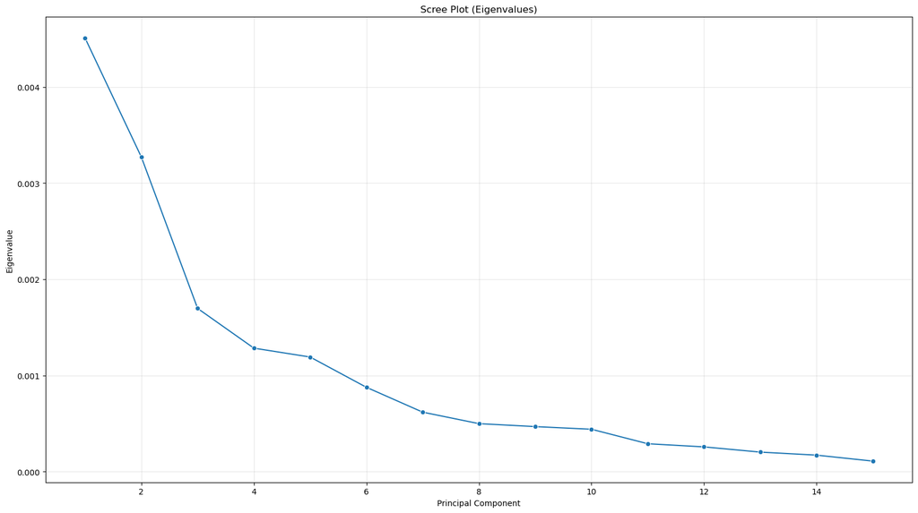

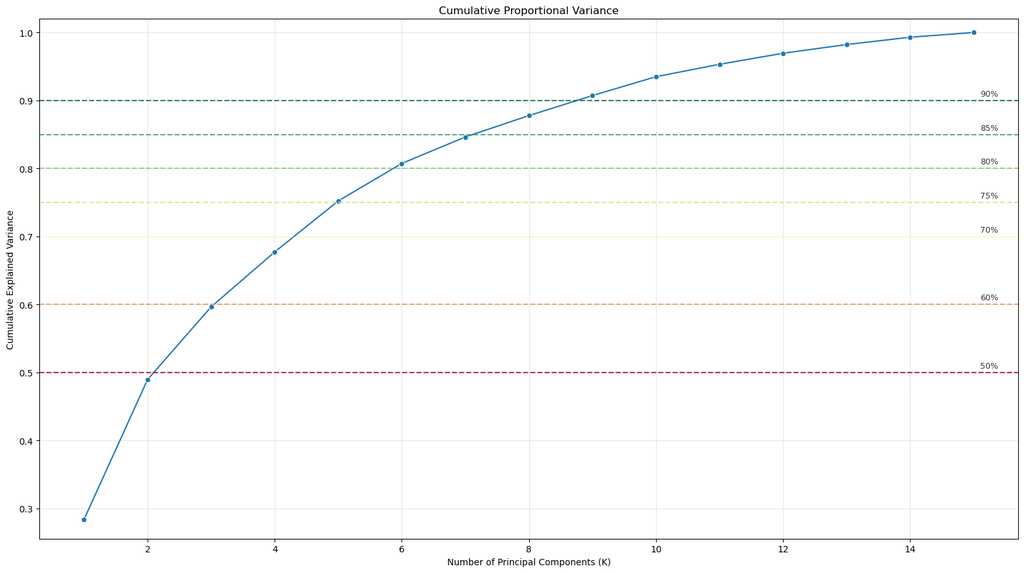

|  | Cumulative Proportional Variance |
| --- | --- |
| 0 | 0.283678 |
| 1 | 0.489516 |
| 2 | 0.596325 |
| 3 | 0.677141 |
| 4 | 0.752150 |
| 5 | 0.807350 |
| 6 | 0.846291 |
| 7 | 0.877718 |
| 8 | 0.907213 |
| 9 | 0.934963 |
| 10 | 0.953244 |
| 11 | 0.969462 |
| 12 | 0.982264 |
| 13 | 0.993083 |
| 14 | 1.000000 |

```python
cumulative_variance = k_factor_pca_model.get_cumulative_variance(plot=True)
display(pd.DataFrame(cumulative_variance['Cumulative Proportional Variance']))
```

The cumulative proportion of variance explained indicates how much of the total variability in asset returns is captured by the first $k$ principal components and therefore measures the adequacy of a low-dimensional factor representation of the covariance structure.

The eigenvalues (explained variances) decay steeply for the first few principal components and then flatten, indicating that the early components capture the dominant common variation in returns while later components contribute only marginal incremental variance and are more likely to represent idiosyncratic noise.

The data indicates the cumulative explained variance rises quickly to about $75\%$ by $K=5$, after which additional components add relatively small gains.

Hence $K=5$ is a reasonable compromise between dimensionality reduction and preserving the main systematic risk structure.

### 2.2 Implement Principal Component Analysis (PCA) of the Centered Returns.

- Using `scikit-learn`
- Using the first $k=5$ principal components, construct the k-factor model $R = A + BF + \epsilon$ implied by the PCA.
- Display the coefficients $A$ and $B$ of the k-factor model and confirm that the variances of the factors coincide with the first $k$ eigenvalues of $\hat{\Sigma}_c$ and that the error term has a zero mean vector.

##### Method

- Apply PCA using `scikit-learn` to the centered returns and retain the first five principal components.
- This yields a k-factor model of the form $R = A + B F + \epsilon$
  - where:
    - $A$ is the vector of mean returns
    - $B$ contains the PCA loadings
- The factor realizations are given by the projected data onto the principal components.
- Verify that the variances of the factors coincide with the first five eigenvalues of the covariance matrix and confirm that the residual term has a zero mean vector.

```python
display(Markdown("#### $A$ (mean returns):"))
display_matrix(k_factor_pca_model.A, variable="A")
display(Markdown("#### $B$ (factor loadings):"))
display_matrix(k_factor_pca_model.B, variable="B")
display(Markdown(f"#### Residual mean: {k_factor_pca_model.get_residual_mean():.10f}"))
```

$A$ (mean returns):

$\displaystyle A = \left[\begin{matrix}0.0043\\0.0065\\0.0024\\0.0036\\0.0025\\0.0021\\0.0019\\0.0011\\0.001\\0.0016\\0.0019\\0.0012\\0.001\\0.001\\0.0011\end{matrix}\right]$

$B$ (factor loadings):

$\displaystyle B = \left[\begin{matrix}0.0763 & 0.0549 & 0.549 & 0.354 & 0.7067\\0.8562 & -0.4885 & -0.1435 & 0.0004 & 0.0364\\0.0156 & 0.0625 & 0.1445 & 0.0661 & -0.2831\\0.2615 & 0.5846 & -0.4635 & 0.5905 & 0.0397\\0.1935 & 0.3438 & 0.0132 & -0.4052 & 0.1238\\0.185 & 0.3464 & -0.0257 & -0.393 & 0.1307\\0.1097 & 0.1119 & 0.2535 & 0.2495 & -0.5186\\0.0575 & 0.0409 & 0.1329 & 0.006 & -0.0456\\0.0927 & 0.0868 & 0.1172 & -0.0459 & -0.0686\\0.1531 & 0.3147 & 0.0038 & -0.3685 & 0.0737\\0.2441 & 0.2145 & 0.5171 & 0.011 & -0.296\\0.0341 & 0.0756 & 0.0745 & -0.0348 & -0.0696\\0.0721 & 0.0399 & 0.1087 & -0.0127 & -0.0258\\0.0525 & 0.0225 & 0.0383 & -0.0233 & -0.0922\\0.0683 & -0.0036 & 0.2441 & 0.0287 & -0.0486\end{matrix}\right]$

Residual mean: -0.0000000000

```python
# k_factor_pca_model.plot_factor_loadings()
```

### 2.3 PCA Validation

- Is the PCA k-factor model an APT model? Justify and explain your answer by showing the necessary calculations.

#### Lemma 3.4

> If the k-factor model $R = A + BF + \epsilon $ is an APT model, then there exists $\lambda_0 \in R$ such that for all $\phi \in \mathbb{R}^d$, $\phi^{\top} B = \mathbf{0}_{1 \times k}$ implies that $\phi^{\top}(A − \lambda_0 \mathbf{1}_d) = 0$.

```python
_ = k_factor_pca_model.validate_apt()
```

APT Validation (PCA k-factor model)

Cross-sectional pricing restriction

APT pricing restriction: $$M = \lambda_0\mathbf{1} + B\lambda.$$

Estimated: $$\hat{\lambda}_0 = 0.004949$$

Pricing error: $$\|e\|^2 = 0.000588$$

Relative pricing error: $$\dfrac{\|e\|^2}{\|M\|^2} = 5.504226$$

**Not APT-like cross-section:** expected returns are not well-explained by the affine span of $\mathbf{1}$ and $B$ (relative error > 0.01).

Factor-neutral invested portfolio ("risk-free" in factor space)

Checks: $$\mathbf{1}^{\top} \phi_{rf} = 1.000000, \quad \| B^{\top} \phi_{rf} \| = 0.000000$$

Implied return: $$\phi_{rf}^{\top} M = 0.001120$$

Gap to intercept: $$\phi_{rf}^{\top} {M} - \hat{\lambda}_0 = -0.003829 = \phi_{rf}^{{\top}} e$$

Not equal because pricing is not exact: $\phi_{rf}^\top{M} = \hat{\lambda}_0 + \phi_{rf}^{\top} e.$

Self-financing factor-neutral portfolio implication

Checks: $$\mathbf{1}^{\top} \phi_{sf}=0.000000,\quad \|B^{\top} \phi_{sf} \|=0.000000$$

APT implication: if $\phi^{\top} B=0$ and $\phi^{\top} \mathbf{1} = 0$, then $$\phi^{\top} (M - \lambda_0 \mathbf{1}) = 0$$

Fails: $$\phi_{sf}^{\top} (M - \hat{\lambda}_0 \mathbf{1}) = 0.000369$$

Optional stronger identification (only if $\lambda_0 = r_0$) is imposed: $$\phi^{\top} (M - r_0 \mathbf{1}) = 0.$$

Fails: $$\phi_{sf}^{\top} (M - r_0^{daily} \mathbf{1}) = 0.000369$$

Intercept vs given risk-free

Given daily risk-free: $$r_0^{daily}=0.000394$$

Estimated intercept: $$\hat\lambda_0=0.004949$$

Here, $\hat{\lambda}_0 \not\approx r_0^{daily}$.

Conclusion: Is the PCA k-factor model an APT model?

We test the APT pricing restriction $$M \stackrel{?}{=} \lambda_0 \mathbf{1}_d + B \lambda,$$ by estimating $$\hat{\lambda} = C^{\top}(C C^{\top})^{-1} M,\qquad C=[\mathbf{1}_d\;\;B],$$ and computing the pricing error $$e := M - C\hat{\lambda} , \qquad \|e\|^2 = e^{\top} e.$$

Numerically, $$\|e\|^2 = 0.000588,\qquad \frac{\|e\|^2}{\|M\|^2} = 5.504226.$$

As an equivalent no-arbitrage implication, for any portfolio with $$\phi^{\top} \mathbf{1}_d = 0 \quad \text{and} \quad \phi^{\top} B = 0,$$ APT implies $$\phi^{\top} (M - \lambda_0 \mathbf{1}_d) = 0.$$

Using a constructed $\phi_{sf} \in \mathrm{Null} ([\mathbf{1}^{\top}; B^{\top}])$, we obtain $$\phi_{sf}^{\top}( M - \hat{\lambda_0} \mathbf{1}_d) = 0.000369.$$

**Therefore, the PCA $k$-factor model is *not* an exact APT model (in-sample).** The pricing restriction $M = \lambda_0 \mathbf{1} + B \lambda$ does not hold exactly, as indicated by the nonzero pricing error $\|e\|^2$ and the nonzero arbitrage implication $\phi_{sf}^{\top} (M - \hat{\lambda}_0 \mathbf{1})$. In practice, PCA factors explain covariance structure well, but they do not necessarily span the cross-section of expected returns required by APT.

### 2.4 Empirical vs K-Factor Model Comparison

- Compare the mean and covariance matrix of the risky asset returns obtained from the k-factor model and those obtained directly from the data (in Part 0).
  - **Note that the covariance matrix and mean vector obtained using the k-factor model must be annualized.**
- Do you expect your results in Part 1 to change significantly if you were to use the mean and covariance matrix obtained from the k-factor model?
- Explain your answer.

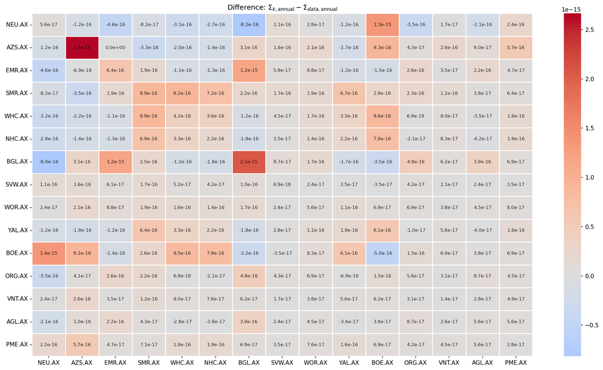

|  | Mean Returns (Annualized) | Mean Returns (k-Factor Model) | Difference |
| --- | --- | --- | --- |
| NEU.AX | 1.0925 | 1.0925 | -0.0 |
| AZS.AX | 1.6621 | 1.6621 | 0.0 |
| EMR.AX | 0.6142 | 0.6142 | -0.0 |
| SMR.AX | 0.9148 | 0.9148 | 0.0 |
| WHC.AX | 0.6299 | 0.6299 | 0.0 |
| NHC.AX | 0.5308 | 0.5308 | 0.0 |
| BGL.AX | 0.4798 | 0.4798 | -0.0 |
| SVW.AX | 0.2678 | 0.2678 | -0.0 |
| WOR.AX | 0.2665 | 0.2665 | -0.0 |
| YAL.AX | 0.4062 | 0.4062 | 0.0 |
| BOE.AX | 0.4704 | 0.4704 | -0.0 |
| ORG.AX | 0.2968 | 0.2968 | -0.0 |
| VNT.AX | 0.2414 | 0.2414 | -0.0 |
| AGL.AX | 0.2427 | 0.2427 | -0.0 |
| PME.AX | 0.2729 | 0.2729 | -0.0 |

```python
mean_compare, fro_rel, diag_rel = k_factor_pca_model.get_covariance_comparison()
mean_compare = mean_compare.round(4)
display(mean_compare)
```

$$ \text{Relative Frobenius} = \frac{\|\Sigma_{k,\text{annual}}-\Sigma_{\text{data,annual}}\|_F}{\|\Sigma_{\text{data,annual}}\|_F} $$$$ \text{Relative diagonal} = \frac{\|\operatorname{diag}(\Sigma_{k,\text{annual}})-\operatorname{diag}(\Sigma_{\text{data,annual}})\|} {\|\operatorname{diag}(\Sigma_{\text{data,annual}})\|} $$

```python
display(Markdown(f"Relative Frobenius: {fro_rel:.6f}"))
display(Markdown(f"Relative diagonal: {diag_rel:.6f}"))
```

Relative Frobenius: 0.000000

Relative diagonal: 0.000000

No significant changes are expected.

The k-factor implied covariance matrix is numerically indistinguishable from the sample covariance, with relative Frobenius and diagonal errors on the order of $10^{-15}$.

Likewise, the implied mean vector closely matches the sample mean.

Since the portfolio optimisation problems in Part 1 depend directly on these inputs, using the k-factor moments would yield essentially identical optimal portfolios and risk–return characteristics, up to numerical precision.

The equality between the sample covariance and the k-factor implied covariance arises because the PCA decomposition is exact and the full residual covariance is retained.

Specifically, the covariance is decomposed as: $$\Sigma = U_k\Lambda_k U_k^\top + U_{k+1:d}\Lambda_{k+1:d}U_{k+1:d}^\top$$

The k-factor model reconstructs both components.

As a result, no variance or correlation structure is discarded, and the implied covariance coincides with the sample covariance up to numerical precision.

## Part 3: Alternative Portfolio Optimization Criteria

In this part, you will solve alternative portfolio optimization problems which may not necessarily have a closed-form solution. Examples of alternative portfolio optimization problems include the mean-variance analysis with additional constraints (as was illustrated in class) and portfolio optimization with different objective functions. You are tasked with solving these portfolio optimization problem using `scipy.optimize`, which is a general-purpose optimizer.

```python
# Number of assets in portfolio
N = len(TEV.portfolio_tickers)
# Beta with respect to benchmark
beta_asx = TEV.beta_benchmark['Beta'].to_numpy()
# Annualized mean returns
M_annualized = portfolio_pre_processor.M.to_numpy()
# Annualized covariance
Sigma_annualized = portfolio_pre_processor.Sigma.to_numpy()
# Annualized mean return of index
benchmark_mu = portfolio_pre_processor.mu_annual_index
# Annualized standard deviation of index
benchmark_std = portfolio_pre_processor.sigma_annual_index

# Tangent portfolio
tangent_portfolio = MV.phi_tau
tangent_std = TEV.sigma_varphi_tau

# Initialize alternative portfolio optimizer
alt_portfolio_optimizer = AlternativePortfolioOptimization(
    risk_free_rate=RISK_FREE_RATE,
    tangent_portfolio=tangent_portfolio,
    tangent_std=tangent_std,
    benchmark_std=benchmark_std,
    benchmark_beta=beta_asx,
    benchmark_mu=benchmark_mu,
    display_output=True
)
```

#### 3.1. Consider the constrained mean-variance portfolio optimization problem

$$ \begin{aligned} \min_{\phi \in \mathbb{R}^d}\quad & \phi^{\top} \Sigma \phi \\[0.5em] \text{s.t.}\quad & \phi^{\top} M = \bar{m}, \\[0.25em] & \phi^{\top} \mathbf{1}_d = 1, \\[0.25em] & \phi^{\top} \boldsymbol{\beta}_{\mathrm{ASX}} = 0, \\[0.25em] & \max_{i}\, |\phi_i| \le 0.50 . \end{aligned} $$

where $\mathbf{\beta}_{ASX}$ is the vector of betas of the stocks in $S$ with respect to the ASX 200 index (computed in Part 1 TEV Task 1).

- Determine the composition, mean return, and standard deviation of the return of the portfolio $\phi_{MN}$ which solves the problem above.
- What are the practical implications of the final two constraints above?

```python
beta_neutral_performance_metrics = alt_portfolio_optimizer.solve_beta_neutral_portfolio(
    mean_returns=M_annualized,
    covariance=Sigma_annualized,
    beta=beta_asx,
    target_return=TARGET_RETURN)

beta_neutral_metrics = beta_neutral_performance_metrics.get_metrics()

display(Markdown("### Portfolio Composition: $\phi_{MN}$"))

phi_MN_df = pd.DataFrame({
    "Ticker": portfolio_pre_processor.portfolio_tickers,
    "Weight": np.round(beta_neutral_performance_metrics.phi, 4),
    "AbsWeight": np.round(np.abs(beta_neutral_performance_metrics.phi), 4),
    "Beta": np.round(beta_asx, 4)
}).sort_values("AbsWeight", ascending=False)

display(phi_MN_df[['Ticker', 'Weight']])

display(Markdown(f"#### Mean Return $\phi_{{MN}}$: {beta_neutral_metrics.mu:.4f}"))
display(Markdown(f"#### Standard Deviation $\phi_{{MN}}$: {beta_neutral_metrics.sigma:.4f}"))

# beta_neutral_performance_metrics.display_metrics()
# beta_neutral_performance_metrics.interpret_metrics()
```

Portfolio Composition: $\phi_{MN}$

|  | Ticker | Weight |
| --- | --- | --- |
| 13 | AGL.AX | 0.3942 |
| 8 | WOR.AX | -0.3726 |
| 2 | EMR.AX | 0.3645 |
| 7 | SVW.AX | 0.3644 |
| 12 | VNT.AX | 0.3603 |
| 10 | BOE.AX | -0.2594 |
| 14 | PME.AX | -0.2271 |
| 11 | ORG.AX | 0.1918 |
| 6 | BGL.AX | -0.1769 |
| 4 | WHC.AX | -0.1719 |
| 0 | NEU.AX | 0.1654 |
| 9 | YAL.AX | 0.1453 |
| 5 | NHC.AX | 0.1223 |
| 3 | SMR.AX | 0.0735 |
| 1 | AZS.AX | 0.0262 |

Mean Return $\phi_{MN}$: 0.5000

Standard Deviation $\phi_{MN}$: 0.2905

**1. Beta-neutrality constraint $\phi^\top \beta_{\text{ASX}}=0$**

What it does in practice

- Enforces a beta-neutral (market-neutral) portfolio, implying the portfolio has no linear exposure to ASX200 index movements.
- Makes the portfolio behave more like a relative-value / market-neutral strategy.

Practical challenges

- Requires short selling, which may be restricted or costly.
- Higher turnover: betas drift over time, so you must rebalance to stay neutral, which can increase leverage, turnover, and implementation costs.
- Can increase gross exposure (large longs + large shorts) even though net exposure is 1.
- If the target return is high (like 50% p.a.), beta neutrality can make the problem harder or force extreme trades to achieve return without “market help”.

**2. Position limit $\max_i|\phi_i|\le 0.5$**

What it does in practice

- Position limit that controls concentration and prevents extreme allocations driven by estimation error.
- Improves implementability and reduces concentration risk.

Trade-offs

- You may lose some “theoretical efficiency”: the constrained minimum variance might be higher than the unconstrained one.
- The optimizer may push several weights close to $\pm 0.5$, creating a “corner solution” (a sign that constraints are binding).
- Still sensitive to estimation error, but generally less unstable than unconstrained MV.

#### 3.2. Find the portfolio $\phi_{MSR}$ that maximizes the Sharpe ratio

$$ \max_{\phi \in \mathbb{R}^d}\ \frac{\phi^\top M - r_0}{\sqrt{\phi^\top \Sigma \phi}} \quad \text{s.t.}\quad \phi^\top \mathbf{1}=1,\ \phi \ge 0. $$

Display the composition, mean return, and standard deviation of the return of $\phi_{MSR}$.

```python
max_sharpe_performance_metrics = alt_portfolio_optimizer.solve_max_sharpe_ratio(
    mean_returns=portfolio_pre_processor.M,
    covariance=portfolio_pre_processor.Sigma,
    risk_free_rate=RISK_FREE_RATE
)

max_sharpe_metrics = max_sharpe_performance_metrics.get_metrics()

display(Markdown("### Portfolio Composition: $\phi_{MSR}$"))

phi_MSR_df = pd.DataFrame({
    "Ticker": portfolio_pre_processor.portfolio_tickers,
    "Weight": np.round(max_sharpe_performance_metrics.phi, 2),
    "AbsWeight": np.round(np.abs(max_sharpe_performance_metrics.phi), 2),
}).sort_values("AbsWeight", ascending=False)

display(phi_MSR_df[['Ticker', 'Weight']])

display(Markdown(f"#### Mean Return $\phi_{{MSR}}$: {max_sharpe_metrics.mu * 100:.4f}%"))
display(Markdown(f"#### Standard Deviation $\phi_{{MSR}}$: {max_sharpe_metrics.sigma * 100:.4f}%"))

# max_sharpe_performance_metrics.display_metrics()
# max_sharpe_performance_metrics.interpret_metrics()
```

Portfolio Composition: $\phi_{MSR}$

|  | Ticker | Weight |
| --- | --- | --- |
| 2 | EMR.AX | 0.29 |
| 0 | NEU.AX | 0.27 |
| 1 | AZS.AX | 0.14 |
| 3 | SMR.AX | 0.10 |
| 4 | WHC.AX | 0.08 |
| 11 | ORG.AX | 0.07 |
| 13 | AGL.AX | 0.06 |
| 5 | NHC.AX | 0.00 |
| 6 | BGL.AX | 0.00 |
| 7 | SVW.AX | 0.00 |
| 8 | WOR.AX | 0.00 |
| 9 | YAL.AX | 0.00 |
| 10 | BOE.AX | 0.00 |
| 12 | VNT.AX | 0.00 |
| 14 | PME.AX | 0.00 |

Mean Return $\phi_{MSR}$: 87.3986%

Standard Deviation $\phi_{MSR}$: 27.9969%

### 3.3 Kelly portfolio $\phi_K$

- The Kelly portfolio is the portfolio $\phi_K$ which maximizes the (expected) portfolio growth rate, which can be shown in this context is given by $\mathbb{E}[\ln(1 + \phi^{\top} R)]$, where $R$ is the random vector of returns of the risky assets over the investment period `(Luenberger, 2014, Chapter 18)`.

Find the portfolio $\phi_K$ that maximizes the Kelly criterion (using its mean-variance approximation),

$$ \begin{aligned} \max_{\phi \in \mathbb{R}^d}\quad & \phi^\top M - \frac{1}{2}\left(\phi^\top M\right)^2 - \frac{1}{2}\,\frac{\phi^\top \Sigma \phi}{1 + 2\,\phi^\top M} \\[0.5em] \text{s.t.}\quad & \phi^\top \mathbf{1} = 1, \\ & \phi \ge 0 . \end{aligned} $$

Display the composition, mean return, and standard deviation of the return of $\phi_K$.

```python
kelly_mean_variance_performance_metrics= alt_portfolio_optimizer.solve_kelly_mean_variance(
    mean_returns=portfolio_pre_processor.M,
    covariance=portfolio_pre_processor.Sigma
)

display(Markdown("### Portfolio Composition: $\phi_{K}$"))

phi_K_df = pd.DataFrame({
    "Ticker": portfolio_pre_processor.portfolio_tickers,
    "Weight": np.round(kelly_mean_variance_performance_metrics.phi, 2),
    "AbsWeight": np.round(np.abs(kelly_mean_variance_performance_metrics.phi), 2),
}).sort_values("AbsWeight", ascending=False)

kelly_mean_variance_metrics = kelly_mean_variance_performance_metrics.get_metrics()

display(phi_K_df[['Ticker', 'Weight']])

display(Markdown(f"#### Mean Return $\phi_{{K}}$: {kelly_mean_variance_metrics.mu:.4f}"))
display(Markdown(f"#### Standard Deviation $\phi_{{K}}$: {kelly_mean_variance_metrics.sigma:.4f}"))

# kelly_mean_variance_performance_metrics.display_metrics()
# kelly_mean_variance_performance_metrics.interpret_metrics()
```

Portfolio Composition: $\phi_{K}$

|  | Ticker | Weight |
| --- | --- | --- |
| 0 | NEU.AX | 0.31 |
| 2 | EMR.AX | 0.30 |
| 1 | AZS.AX | 0.17 |
| 3 | SMR.AX | 0.12 |
| 4 | WHC.AX | 0.08 |
| 11 | ORG.AX | 0.02 |
| 5 | NHC.AX | 0.00 |
| 6 | BGL.AX | 0.00 |
| 7 | SVW.AX | 0.00 |
| 8 | WOR.AX | 0.00 |
| 9 | YAL.AX | 0.00 |
| 10 | BOE.AX | 0.00 |
| 12 | VNT.AX | 0.00 |
| 13 | AGL.AX | 0.00 |
| 14 | PME.AX | 0.00 |

Mean Return $\phi_{K}$: 0.9674

Standard Deviation $\phi_{K}$: 0.3158

### 3.4. Optimal Portfolio based on the Expected Utility

Optimal portfolios can also be determined based on the expected utility of the random portfolio return, $\mathbb{E}[\mathbf{U}(\phi^{\top} \mathbf{R})]$.

Where $U$ is a utility function.

From this perspective, the Kelly criterion is the special case where the utility function is the log utility $$ \mathbf{U}(x) = \ln(1 + x). $$

Given a concave utility function $U$, the expected utility has a mean-variance approximation

$$ \mathbb{E}[\mathbf{U}(\phi^{\top} \mathbf{R})] ≈ \mathbf{U}(\phi^{\top} \mathbf{M}) + \dfrac{1}{2} \mathbf{U}''(\phi^{\top} \mathbf{M}) \phi^{\top} \Sigma \phi. $$

Assuming the investor has an exponential utility function $\mathbf{U}(x) = (1 − e^{− \delta x})$ (use $\delta = 10$), find the portfolio $\phi_{EU}$ that solves the problem

$$ \max_{\phi \in \mathbb{R}^d} \, \mathbf{U}(\phi^{\top} \mathbf{M}) + \dfrac{1}{2} \mathbf{U}''(\phi^{\top} \mathbf{M}) \phi^{\top} \Sigma \phi \qquad \text{ subject to } \qquad \phi^{\top} \mathbf{1}_d = 1, \qquad \phi \geq 0 $$

Display the composition, mean return, and standard deviation of the return of $\phi_{EU}$.

#### Method

Using the mean–variance approximation: $$ \mathbb{E}[U(\phi^\top R)] \approx U(\phi^\top M) + \frac{1}{2}U''(\phi^\top M)\,\phi^\top \Sigma \phi. $$

Starting with the exponential utility function $$ U(x)=1-e^{-\delta x}. $$

**First derivative $U'(x)$**

Differentiate term-by-term:

- $\dfrac{d}{dx}[1]=0$
- For the second term, use the chain rule:

$$ \frac{d}{dx}\left(e^{-\delta x}\right)=(-\delta)e^{-\delta x}. $$

So, $$ U'(x) = \frac{d}{dx} \left(1-e^{-\delta x}\right) = 0 - \left[(-\delta)e^{-\delta x}\right] = \delta e^{-\delta x}. $$

**Second derivative $U''(x)$**

Differentiate $U'(x)=\delta e^{-\delta x}$ again: $$ U''(x)=\frac{d}{dx}\left(\delta e^{-\delta x}\right) =\delta \cdot \frac{d}{dx}\left(e^{-\delta x}\right) =\delta \cdot \left[(-\delta)e^{-\delta x}\right] =-\delta^2 e^{-\delta x}. $$

Therefore, $$ U(x)=1-e^{-\delta x},\qquad U'(x)=\delta e^{-\delta x},\qquad U''(x)=-\delta^2 e^{-\delta x}. $$

```python
exponential_utility_performance_metrics = alt_portfolio_optimizer.solve_exponential_utility(
    mean_returns=portfolio_pre_processor.M,
    covariance=portfolio_pre_processor.Sigma,
    delta=10.0
)

exponential_utility_metrics = exponential_utility_performance_metrics.get_metrics()

display(Markdown("### Portfolio Composition: $\phi_{EU}$"))

phi_EU_df = pd.DataFrame({
    "Ticker": portfolio_pre_processor.portfolio_tickers,
    "Weight": np.round(exponential_utility_performance_metrics.phi, 2),
    "AbsWeight": np.round(np.abs(exponential_utility_performance_metrics.phi), 2),
}).sort_values("AbsWeight", ascending=False)

display(phi_EU_df[['Ticker', 'Weight']])

display(Markdown(f"#### Mean Return $\phi_{{EU}}$: {exponential_utility_metrics.mu:.4f}"))
display(Markdown(f"#### Standard Deviation $\phi_{{EU}}$: {exponential_utility_metrics.sigma:.4f}"))

# exponential_utility_performance_metrics.display_metrics()
# exponential_utility_performance_metrics.interpret_metrics()
```

Portfolio Composition: $\phi_{EU}$

|  | Ticker | Weight |
| --- | --- | --- |
| 1 | AZS.AX | 1.0 |
| 0 | NEU.AX | 0.0 |
| 2 | EMR.AX | 0.0 |
| 3 | SMR.AX | 0.0 |
| 4 | WHC.AX | 0.0 |
| 5 | NHC.AX | 0.0 |
| 6 | BGL.AX | 0.0 |
| 7 | SVW.AX | 0.0 |
| 8 | WOR.AX | 0.0 |
| 9 | YAL.AX | 0.0 |
| 10 | BOE.AX | 0.0 |
| 11 | ORG.AX | 0.0 |
| 12 | VNT.AX | 0.0 |
| 13 | AGL.AX | 0.0 |
| 14 | PME.AX | 0.0 |

Mean Return $\phi_{EU}$: 1.6621

Standard Deviation $\phi_{EU}$: 1.0236

### 3.5. Efficient Frontier

Add the risk-return representation of $\phi_{MN}$, $\phi_{MSR}$, $\phi_{K}$, and $\phi_{EU}$ to the efficient frontier plots you generated in Part 1 TEV Task 4.

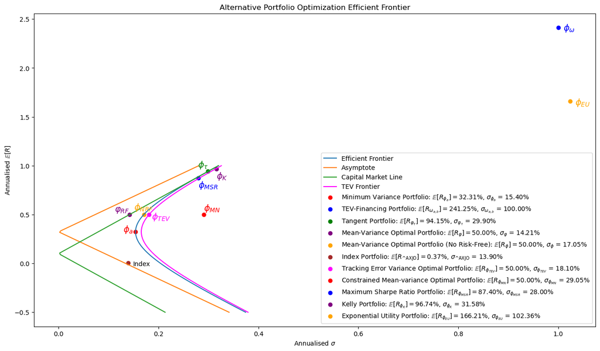

```python
# mu_range_low = np.min(np.array([np.min(TEV.M), TEV.m_phi_a, TEV.m_omega, TEV.m_varphi_tau])) - 0.5
mu_range_low = -0.5
# mu_range_high = np.max(np.array([np.max(TEV.M), TEV.m_phi_a, TEV.m_omega, TEV.m_varphi_tau])) + 0.5
mu_range_high = 1
mus = np.linspace(mu_range_low, mu_range_high, 100)


# Initialize lists to store results
F_sigmas = list()
asymptote_sigmas = list()
capital_market_line_sigmas = list()

for mu in mus:
    F_sigmas.append(np.sqrt( TEV.sigma_phi_a**2 + ( (mu - TEV.m_phi_a) / TEV.m_omega )**2 ))
    asymptote_sigmas.append( np.abs((mu - TEV.b / TEV.a) / TEV.m_omega) )
    capital_market_line_sigmas.append( np.abs((TEV.sigma_varphi_tau / (TEV.m_varphi_tau - TEV.r_0)) * (mu - TEV.r_0)) )

F_sigmas = np.array(F_sigmas)
asymptote_sigmas = np.array(asymptote_sigmas)
capital_market_line_sigmas = np.array(capital_market_line_sigmas)
sigma_TEV = np.sqrt(F_sigmas**2 + (TEV.benchmark_std ** 4) * TEV.beta_benchmark.loc[TEV.portfolio_tickers]['Beta'].to_numpy().T @ TEV.Q @ TEV.beta_benchmark.loc[TEV.portfolio_tickers]['Beta'].to_numpy())
sigma_TEV = sigma_TEV.T

plt.figure(figsize=(16, 9))
plt.plot(F_sigmas, mus, label='Efficient Frontier')
plt.plot(asymptote_sigmas, mus, label='Asymptote')
plt.plot(capital_market_line_sigmas, mus, label='Capital Market Line')
plt.plot(sigma_TEV, mus, label='TEV Frontier', color='magenta')

plt.xlabel('Annualised $\sigma$')
plt.ylabel('Annualised $\mathbb{{E}}[R]$')

plt.scatter(TEV.sigma_phi_a, TEV.m_phi_a, color='red', label=f'Minimum Variance Portfolio: $\mathbb{{E}}[R_{{\\phi_a}}] = {TEV.m_phi_a * 100:.2f}\%$, $\sigma_{{\\phi_a}}$ = {TEV.sigma_phi_a * 100:.2f}%')
plt.annotate(f"$\phi_{{a}}$", xy=(TEV.sigma_phi_a, TEV.m_phi_a), xytext=(TEV.sigma_phi_a - 0.025, TEV.m_phi_a - 0.0), fontsize=14, color='red')

plt.scatter(TEV.sigma_omega, TEV.m_omega, color='blue', label=f'TEV-Financing Portfolio: $\mathbb{{E}}[R_{{\\omega_{{a,b}}}}] = {TEV.m_omega * 100:.2f}\%$, $\sigma_{{\\omega_{{a,b}}}}$ = {TEV.sigma_omega * 100:.2f}%')
plt.annotate(f"$\phi_{{\omega}}$", xy=(TEV.sigma_omega, TEV.m_omega), xytext=(TEV.sigma_omega + 0.01, TEV.m_omega - 0.03), fontsize=14, color='blue')

plt.scatter(TEV.sigma_varphi_tau, TEV.m_varphi_tau, color='green', label=f'Tangent Portfolio: $\mathbb{{E}}[R_{{\\varphi_{{\\tau}}}}] = {TEV.m_varphi_tau * 100:.2f}\%$, $\sigma_{{\\varphi_{{\\tau}}}}$ = {TEV.sigma_varphi_tau * 100:.2f}%')
plt.annotate(f"$\phi_{{\\tau}}$", xy=(TEV.sigma_varphi_tau, TEV.m_varphi_tau), xytext=(TEV.sigma_varphi_tau - 0.02, TEV.m_varphi_tau + 0.04), fontsize=14, color='green')

plt.scatter(TEV.sigma_varphi, TEV.m_varphi, color='purple', label=f'Mean-Variance Optimal Portfolio: $\mathbb{{E}}[R_{{\\varphi}}] = {TEV.m_varphi * 100:.2f}\%$, $\sigma_{{\\varphi}}$ = {TEV.sigma_varphi * 100:.2f}%')
plt.annotate(f"$\\varphi_{{RF}}$", xy=(TEV.sigma_varphi, TEV.m_varphi), xytext=(TEV.sigma_varphi - 0.03, TEV.m_varphi + 0.03), fontsize=14, color='purple')

plt.scatter(TEV.sigma_phi, TEV.m_phi, color='orange', label=f'Mean-Variance Optimal Portfolio (No Risk-Free): $\mathbb{{E}}[R_{{\\phi}}] = {TEV.m_phi * 100:.2f}\%$, $\sigma_{{\\phi}}$ = {TEV.sigma_phi * 100:.2f}%')
plt.annotate(f"$\phi_{{NRF}}$", xy=(TEV.sigma_phi, TEV.m_phi), xytext=(TEV.sigma_phi - 0.02, TEV.m_phi + 0.05), fontsize=14, color='orange')

plt.scatter(TEV.benchmark_std, TEV.benchmark_mu, color='brown', label=f'Index Portfolio: $\mathbb{{E}}[R_{{\\text{{{TEV.index_ticker}}}}}] = {TEV.benchmark_mu * 100:.2f}\%$, $\sigma_{{\\text{{{TEV.index_ticker}}}}}$ = {TEV.benchmark_std * 100:.2f}%')
plt.annotate("Index", xy=(TEV.benchmark_std, TEV.benchmark_mu), xytext=(TEV.benchmark_std + 0.01, TEV.benchmark_mu - 0.03))

plt.scatter(TEV.sigma_phi_tev, TEV.m_phi_tev, color='magenta', label=f'Tracking Error Variance Optimal Portfolio: $\mathbb{{E}}[R_{{\\phi_{{TEV}}}}] = {TEV.m_phi_tev * 100:.2f}\%$, $\sigma_{{\\phi_{{TEV}}}}$ = {TEV.sigma_phi_tev * 100:.2f}%')
plt.annotate("$\phi_{{TEV}}$", xy=(TEV.sigma_phi_tev, TEV.m_phi_tev), xytext=(TEV.sigma_phi_tev + 0.005, TEV.m_phi_tev - 0.05), fontsize=14, color='magenta')

# mu_MN, std_MN
plt.scatter(beta_neutral_metrics.sigma, beta_neutral_metrics.mu, color='red', label=f'Constrained Mean-variance Optimal Portfolio: $\mathbb{{E}}[R_{{\\phi_{{MN}}}}] = {beta_neutral_metrics.mu * 100:.2f}\%$, $\sigma_{{\\phi_{{MN}}}}$ = {beta_neutral_metrics.sigma * 100:.2f}%')
plt.annotate("$\phi_{MN}$", xy=(beta_neutral_metrics.sigma, beta_neutral_metrics.mu), xytext=(beta_neutral_metrics.sigma + 0.0, beta_neutral_metrics.mu + 0.04), fontsize=14, color='red')

# mu_MSR sigma_MSR
plt.scatter(max_sharpe_metrics.sigma, max_sharpe_metrics.mu, color='blue', label=f'Maximum Sharpe Ratio Portfolio: $\mathbb{{E}}[R_{{\\phi_{{MSR}}}}] = {max_sharpe_metrics.mu * 100:.2f}\%$, $\sigma_{{\\phi_{{MSR}}}}$ = {max_sharpe_metrics.sigma * 100:.2f}%')
plt.annotate("$\phi_{MSR}$", xy=(max_sharpe_metrics.sigma, max_sharpe_metrics.mu), xytext=(max_sharpe_metrics.sigma - 0.0, max_sharpe_metrics.mu - 0.1), fontsize=14, color='blue')

# mu_K, sigma_K
plt.scatter(kelly_mean_variance_metrics.sigma, kelly_mean_variance_metrics.mu, color='purple', label=f'Kelly Portfolio: $\mathbb{{E}}[R_{{\\phi_{{K}}}}] = {kelly_mean_variance_metrics.mu * 100:.2f}\%$, $\sigma_{{\\phi_{{K}}}}$ = {kelly_mean_variance_metrics.sigma * 100:.2f}%')
plt.annotate("$\phi_{K}$", xy=(kelly_mean_variance_metrics.sigma, kelly_mean_variance_metrics.mu), xytext=(kelly_mean_variance_metrics.sigma + 0.0, kelly_mean_variance_metrics.mu - 0.1), fontsize=14, color='purple')

# mu_EU, sigma_EU
plt.scatter(exponential_utility_metrics.sigma, exponential_utility_metrics.mu, color='orange', label=f'Exponential Utility Portfolio: $\mathbb{{E}}[R_{{\\phi_{{EU}}}}] = {exponential_utility_metrics.mu * 100:.2f}\%$, $\sigma_{{\\phi_{{EU}}}}$ = {exponential_utility_metrics.sigma * 100:.2f}%')
plt.annotate("$\phi_{EU}$", xy=(exponential_utility_metrics.sigma, exponential_utility_metrics.mu), xytext=(exponential_utility_metrics.sigma + 0.01, exponential_utility_metrics.mu - 0.04), fontsize=14, color='orange')

plt.title('Alternative Portfolio Optimization Efficient Frontier')
plt.legend()

# plt.xlim(-0.05, 1.1)

plt.show()
```